# AlphaZero-style MCTS for Yolah

The network, the search, the self-play learning loop, and the code that runs them

Published

October 25, 2026

# 1 What this document covers

The Yolah engine has two halves that only meet through a very thin interface. On one side a two-headed residual network, trained in PyTorch, that looks at a position and answers two questions: *who is winning?* and *what would a strong player consider here?* On the other side a Monte-Carlo tree search that calls that network a few hundred times per move and turns its two opinions into an actual move — one much stronger than either opinion alone.

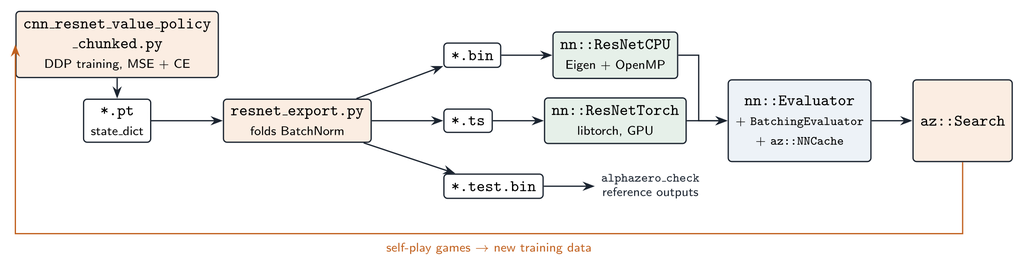

Figure 1: From the training script to the search: every artefact and who consumes it.

This document explains both halves and the seam between them: the algorithm and its formulas first, then the code that implements them, file by file. The search is the one in `player/alphazero_mcts.{h,cpp}`; it started as plain AlphaZero and has since been moved onto KataGo’s formulation of PUCT, its first-play-urgency rule, LCB move selection, graph search, and the two self-play tricks from the KataGo paper (forced playouts and policy target pruning). Section 6 then closes the loop: the engine plays against itself on a GPU cluster, learns from those games and gets stronger, for weeks, with its progress measured by regular matches against its former selves, and Section 7 asks what it would take to compute exact values — endgame tables, an exact solver — and whether Yolah could be solved.

Conventions used throughout:

- $s$ is a position, $a$ a legal move, $s\cdot a$ the position after it.
- $v \in (-1,1)$ is the network’s value, always **for the player to move**.
- $z \in \{-1,0,+1\}$ is the final game result, also for the player to move.
- $P(s,a)$ is the network’s prior, $Q(s,a)$ the search’s running estimate, $N$ a visit count, $W$ a sum of values.

# 2 The game, as far as the search is concerned

Yolah is played on $8\times8$ with four stones per side. A stone slides like a queen, and **the square it leaves becomes a permanent hole**. The player who moves scores one point per move; the game ends when neither side can move, and the higher score wins.

Two consequences drive the design of the search.

**The state graph is acyclic.** In `Yolah::play` the move does `empty ^= square_bb(m.from_sq())`, and `from_sq` always holds a stone, never a hole — so the hole count increases by exactly one on every real move and can never decrease. A position can therefore never repeat. No repetition detection, no cycle handling, no draw-by-repetition: the search space is a DAG, and a depth-first walk over it always terminates.

**Move orders commute.** The four stones of a side move independently, so playing $a$ then $b$ with two different stones reaches exactly the same position as $b$ then $a$. The same position is reachable through many paths, which is what makes both the network cache and the graph search worth having.

The one wrinkle: a player with no legal move passes (`Move::none()`) and scores nothing, while the opponent keeps moving. Two positions can therefore share a board and a side to move while differing in how the points so far split between the players — and the final result depends on that split. This matters for hashing, and Section 5.6.1 comes back to it.

# 3 Position and move encoding

The network sees four $8\times8$ binary planes: black stones, white stones, holes, and a constant plane for the side to move.

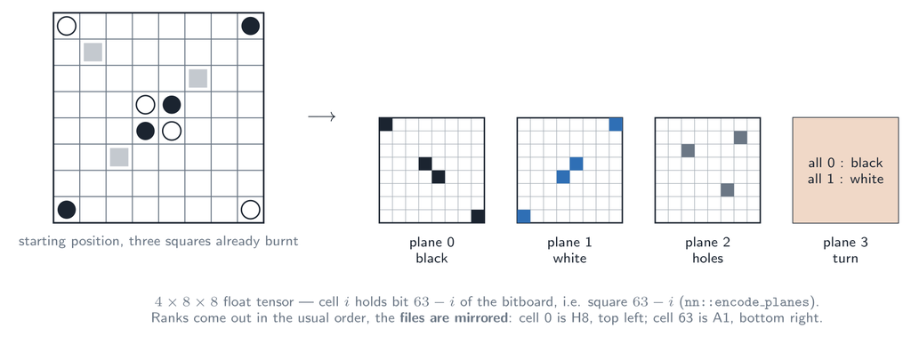

Figure 2: `nn::encode_planes` (C++) and `encode_cnn` (Python) must agree bit for bit.

Two details are easy to get wrong and are worth stating explicitly.

*The planes come out mirrored, and not on purpose.* Squares are numbered `SQ_A1 = 0` through `SQ_H8 = 63`, and bit $s$ of a bitboard is square $s$. The training cache turns a bitboard into a plane like this (`preprocess.py`):

```python
np.unpackbits(np.array([n], dtype='>u8').view(np.uint8)).reshape(8, 8)
```

`>u8` writes the integer big-endian — most significant byte first — and `np.unpackbits` takes the most significant bit of each byte first. The 64 values therefore come out in the order bit 63, bit 62, …, bit 0, so element $i$ is bit $63-i$, which is square $63-i$. That is the whole origin of the $63-i$, and `nn::encode_planes` has no choice but to repeat it:

```cpp
plane[i] = static_cast<float>((bb >> (63 - i)) & 1);
```

Geometrically: write $s = 8\,\text{rank} + \text{file}$ and reshape row-major, and you get $\text{row} = 7 - \text{rank}$, $\text{col} = 7 - \text{file}$. The ranks land the usual way round, rank 8 on the top row — but **the files are mirrored**, H on the left and A on the right. Cell 0 is H8 and cell 63 is A1.

Nothing about the network minds. A fixed mirror of every input is just a relabelling of the board, and the convolutions learn whichever labelling they are shown. What matters is that training and inference agree *exactly*: an encoder that helpfully “fixes” the order would feed the trained weights a mirrored position, and the failure would be quiet — a network that has simply become much weaker.

There is one place it could have bitten, and happens not to. The policy head indexes actions by the **true** square numbers, $64\,\text{from} + \text{to}$, not the mirrored ones — so the input geometry and the output indexing disagree. It costs nothing because both heads flatten the trunk and pass through a fully-connected layer, which absorbs any fixed permutation of its input. A convolutional policy head emitting one logit per board square, as some AlphaZero implementations use, would have had to be told about the mirror explicitly.

*The score is not an input.* The planes carry no score at all. The sum of the two scores is recoverable — it is the number of holes — but the split is not. The network is expected to learn what it needs from the piece and hole configuration.

Moves use a flat AlphaZero-style action space of $64\times64 = 4096$ logits:

$$\text{action}(m) = 64\,\cdot\,\text{from}(m) + \text{to}(m)$$

Roughly three quarters of that space is never legal. Illegal actions are not masked during training — they are simply never the target, so the softmax starves them — and the search applies the legal mask itself: the evaluator returns the logits of *exactly the legal moves*, in `Yolah::moves` order, and the search softmaxes over those. A pass maps to A1→A1, index 0, which is never a real move.

# 4 The network

## 4.1 Architecture

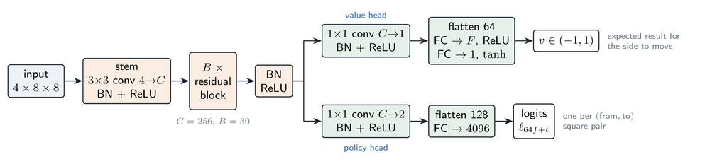

Figure 3: `Net` in `nnue/cnn_resnet_value_policy_chunked.py`. The shipped model is $C=256$, $B=30$, $F=256$: about 35 M parameters and $\approx$ 4.5 GFLOP per position.

The trunk is a stem convolution followed by $B$ pre-activation residual blocks and a final BatchNorm + ReLU. Both heads read the same $(C,8,8)$ feature map.

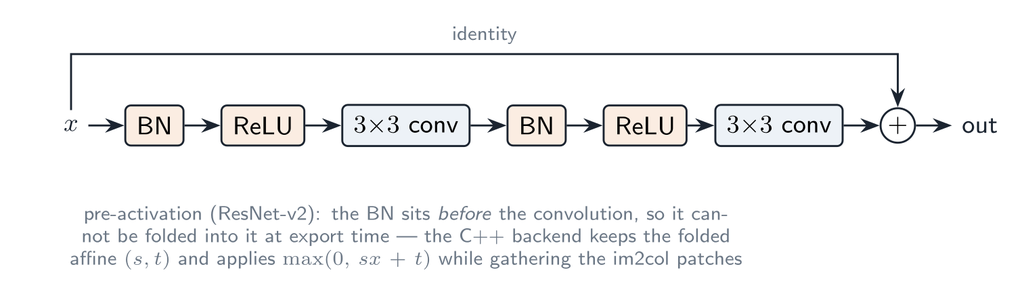

Figure 4: The residual block is ResNet-v2 style: BN and ReLU come *before* each convolution.

```python
class ResBlock(nn.Module):
    def forward(self, x):
        residual = x
        x = self.conv1(torch.relu(self.bn1(x)))
        x = self.conv2(torch.relu(self.bn2(x)))
        return x + residual
```

The **value head** squeezes $C$ channels to one with a $1\times1$ convolution, flattens the resulting $8\times8$ map, and runs two fully-connected layers into a $\tanh$. The output is the expected result for the side to move; a winning probability is $(v+1)/2$.

The **policy head** squeezes to two channels, flattens to 128 features, and projects to 4096 logits with a single fully-connected layer. That last layer holds $4096\times128 \approx 524\,\text{k}$ weights and is, per position, cheaper than one trunk block.

## 4.2 Training

Two scripts define the same network and differ only in how they feed it. `cnn_resnet_value_policy_chunked.py` is the one the shipped weights come from and the one `resnet_export.py` imports; `cnn_resnet_value_policy.py` is its sibling with a stock `DataLoader`, which is the right choice when the position cache fits in page cache. Everything in this section applies to both unless stated otherwise.

Both train the two heads at once on a supervised corpus of positions:

$$\mathcal{L} = \lambda_v\,\big(v - z\big)^2 \;+\; \lambda_p\,\text{CE}\big(\ell,\ a^\star\big)$$

with $\lambda_v = \lambda_p = 1$, as in AlphaZero. The value target $z$ is the game result from the point of view of the player to move at $s$; the policy target $a^\star$ is the single move actually played, so the policy loss is a plain cross-entropy over the 4096 logits. Terminal positions have no next move and carry `POLICY_IGNORE_INDEX = -1`, which `nn.CrossEntropyLoss(ignore_index=…)` skips.

Note the asymmetry with a true AlphaZero loop: here the policy target is a *one-hot move*, not a visit distribution. When the self-play loop of Section 6 is running, the target becomes the search’s $\pi$ and the loss term becomes $-\sum_a \pi(a)\log p(a)$ — the same cross-entropy, with a soft target.

The training scripts are built around one constraint: the dataset does not fit in memory. Positions live in three `np.memmap` files (`positions` as `uint8`, `values` as `int8`, `policies` as `int16`) written by `preprocess.py`, roughly 253 GB in total, and most of what is unusual in the code exists only to make that workable.

**Why the chunked loader.** Sampling that file uniformly at random — which is what a stock `DataLoader` does — becomes millions of scattered ~256-byte reads. On a spinning disk that is seek-bound, and the only rescue is pre-loading the whole 253 GB into page cache. `ChunkedShuffleLoader` instead reads ~1 GB **contiguous** chunks sequentially, shuffles *within* a chunk and reshuffles the chunk order every epoch. That is an approximate shuffle, but a chunk holds around 4 M positions, which is more decorrelation than a 2048-position batch can use. One background thread per rank does the reading and the batch construction while the main thread drives the GPU; the overlap is real because numpy’s memcpy and CUDA’s pin-memory both release the GIL, and the bounded queue between them is the ping-pong buffer.

**The DDP trap.** Every rank must yield *exactly* the same number of batches. Each backward pass is a collective all-reduce, so a rank that runs one step fewer leaves the others hanging forever. Hence the floor division when the chunks are sharded across ranks — up to `world_size - 1` chunks are dropped — and the dropped trailing partial batch of each chunk.

Two more decisions that are easy to get wrong:

- The train/val split is **contiguous**, not random: positions are stored game by game, so a contiguous cut keeps whole games on one side of the split. A per-position random split would leak the same game into both halves.
- Mixed precision is selected on the compute capability, not on `torch.cuda.is_bf16_supported()` — that returns `True` on Turing, where bf16 is emulated and *slower* than fp32. Ampere and later get bf16 with the gradient scaler disabled; Turing gets fp16 with a live `GradScaler`.

The sibling script solves the same problem differently, and its two tricks are worth knowing if you ever go back to a `DataLoader`: `GameDataset.__getstate__` serialises only `(cache_dir, start, end)`, because a raw `np.memmap` pickles *by value* and a spawned worker would copy the whole backing file; and `LeanDistributedSampler` replaces the stock `DistributedSampler`, whose `torch.randperm(N).tolist()` turns a 4 GB index tensor into a ~30 GB list of Python ints **per rank**.

## 4.3 Export: folding BatchNorm

`resnet_export.py` turns one `.pt` checkpoint into three files. The interesting part is what it does to the BatchNorms.

In eval mode a BatchNorm is a per-channel affine map:

$$y = \gamma\,\frac{x-\mu}{\sqrt{\sigma^2+\epsilon}} + \beta = s\,x + t,
\qquad s = \frac{\gamma}{\sqrt{\sigma^2+\epsilon}},\qquad t = \beta - \mu\,s$$

Where a BN **follows** a convolution — the stem, and the two $1\times1$ head convolutions — the scale folds straight into the convolution weights and the shift becomes the bias the convolution did not have:

$$W' = W \odot s,\qquad b' = t$$

Where a BN **precedes** a ReLU and a convolution — every pre-activation block, and the trunk’s output BN — it cannot be merged into anything, so the export keeps $(s,t)$ and the C++ backend applies $\max(0,\,s x + t)$ as it gathers the im2col patches, without an extra pass over the activations.

The three artefacts:

| file | consumer | contents |
| --- | --- | --- |
| `*.bin` | `nn::ResNetCPU` | flat little-endian float32, BN folded, convolutions laid out `(out, tap, in)` with `tap` $= 3\,dr+dc$ |
| `*.ts` | `nn::ResNetTorch` | TorchScript module, traced in eval mode on a dummy $(1,4,8,8)$ batch |
| `*.test.bin` | `alphazero_check` | a few positions with PyTorch’s exact fp32 value and 4096 logits |

The `(out, tap, in)` layout is not cosmetic — it is exactly the operand order the CPU backend’s GEMM wants (Section 4.4).

The header is `"YOLAHRSN"`, a version, and then $(\text{in}, C, B, F, A)$, so the C++ side never has to be told the architecture; it reads it.

## 4.4 The CPU backend

`nnue/resnet.cpp` is a from-scratch inference of the same network with Eigen and OpenMP, with no PyTorch at run time. It exists so the player always works, and as the reference the GPU backend is checked against.

Activations are kept **pixel-major** — `[position][pixel 0..63][channel]`, i.e. NHWC — which turns each $3\times3$ convolution into an im2col gather followed by one large GEMM:

$$\underbrace{\text{Out}}_{64n \times C} \;=\; \underbrace{\text{Col}}_{64n \times 9C}\;\cdot\;\underbrace{W^{\mathsf T}}_{9C \times C}$$

With $C = 256$ that is a $512\times2304$ by $2304\times256$ product per convolution — a shape Eigen’s GEMM runs close to peak on with `-march=native -mfma`. The im2col copy itself is under 5 % of the layer cost, and the pre-activation BN+ReLU is applied *during* the gather, so the activations are read once.

Batching is done by splitting the batch into chunks of `MAX_CHUNK = 8` positions and giving the chunks to an OpenMP team, each thread with its own scratch buffers and Eigen running single-threaded inside. The backend is therefore happiest with **one** search thread handing it 32–128 positions at a time; several search threads must go through `nn::BatchingEvaluator` so their requests are merged rather than nested.

**WarningDenormals**

The CMake LTO link line does not pass `-ffast-math`, so FTZ/DAZ are not set and the trunk’s denormal activations make inference roughly 30× slower. `nnue/resnet.cpp` sets FTZ/DAZ explicitly, per thread. Any new thread that calls into the network must do the same.

## 4.5 The libtorch backend

`nnue/resnet_torch.cpp` loads the TorchScript module and runs the whole batch as one `(n,4,8,8)` forward pass. It is compiled only with `-DENABLE_TORCH=ON` and a libtorch install (the one inside a pip `torch` package works: `-DCMAKE_PREFIX_PATH=<site-packages>/torch`). In half precision on an RTX-class GPU it is 20–50× the CPU backend at batch 256, which is why the search’s `preferred_batch_size()` is backend-specific.

A mutex serialises the forwards: callers are batched upstream anyway, and libtorch does not love concurrent `forward` on the same module.

## 4.6 The seam: `nn::Evaluator`

```cpp
struct Request { const Yolah* state; const Move* moves; uint16_t nb_moves; };
struct Result  { float value; float logits[Yolah::MAX_NB_MOVES]; };

class Evaluator {
    virtual void evaluate(std::span<const Request>, std::span<Result>) = 0;
    virtual size_t preferred_batch_size() const = 0;
    virtual void reload(const std::string& weights_filename) = 0;
};
```

The search never touches a tensor. It hands over positions with their legal moves and gets back a value and the logits of *those* moves, in that order. The softmax, the temperature, and everything else are the search’s business. Three implementations sit behind the interface:

- **`ResNetCPU`** and **`ResNetTorch`**, the two backends above.
- **`BatchingEvaluator`**, a wrapper. Each search thread enqueues its span and blocks; a worker thread fires as soon as the queue reaches `max_batch`, or every registered client is waiting, or `max_wait` has elapsed. With $T$ search threads submitting $B$ leaves each, the backend sees up to $T\!\cdot\!B$ positions per call. An *empty* request is a barrier join — a thread that has nothing to evaluate but wants to wait for the next batch, which is what a thread whose descents all collided does instead of spinning.

## 4.7 The network cache

`player/nn_cache.h` is a direct-mapped, lock-striped table of network outputs keyed by the Zobrist hash of `(board, side to move)` — exactly the network’s input, so the cached value is a pure function of the key. It stores the value and the priors of the legal moves as 16-bit fixed point, and verifies the number of legal moves on lookup so a 64-bit collision cannot silently hand back someone else’s priors.

It survives across moves and games (it depends only on the weights, so `reload_weights` clears it) and it is the second line of defence behind the node table of Section 5.6: it also catches positions that have fallen out of the search graph entirely.

# 5 Monte-Carlo tree search with a network

## 5.1 One simulation

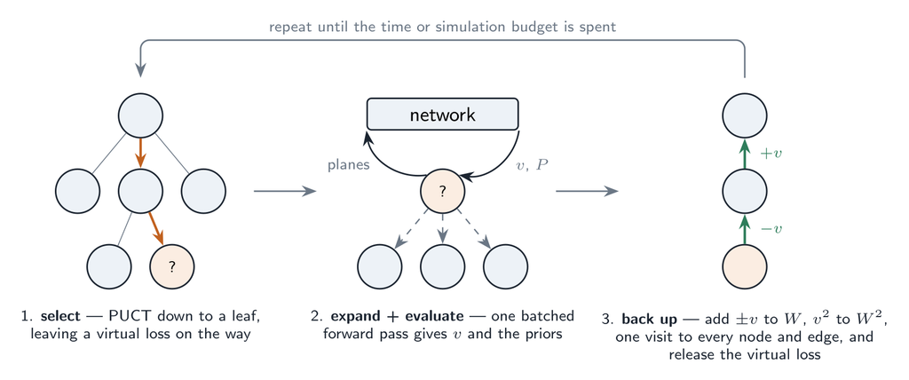

Figure 5: One simulation, in `Search::run_worker`. Steps 1 and 3 are per descent; step 2 is per batch.

A simulation walks down from the root picking children with the PUCT rule until it reaches a position the search has not expanded yet, asks the network what it is worth, and pushes that answer back up the path it came from. Classical MCTS would play a random game from the leaf instead; the network replaces both the rollout (the value head) and the move ordering heuristic (the policy head).

The four node states are `UNEXPANDED`, `EXPANDING` (a thread has claimed it and the network call is in flight), `EXPANDED`, and `TERMINAL`. The transitions are a `compare_exchange` on a single atomic byte, and `EXPANDED` is published with release semantics so that a thread observing it is guaranteed to see the fully built edge vector.

## 5.2 PUCT, in KataGo’s formulation

The child to descend into is

$$a^\star \;=\; \arg\max_a \left[\; Q(s,a) \;+\; c(s)\,\hat\sigma(s)\; P(s,a)\;
\frac{\sqrt{W(s)+\varepsilon}}{1 + W(s,a)} \;\right]$$

with $\varepsilon = 0.01$ (KataGo’s `TOTALCHILDWEIGHT_PUCT_OFFSET`, which keeps the exploration term positive when nothing has been visited yet) and

$$W(s) \;=\; \sum_a W(s,a)$$

the total weight of the **edges leaving $s$** — note: not the node’s own visit count, which is one larger. Every visit weighs 1 and every in-flight virtual loss also weighs 1.

The first term exploits, the second explores. $P(s,a)$ makes the exploration term follow the network’s opinion, $\sqrt{W(s)}$ makes it grow as the parent is studied, and $1/(1+W(s,a))$ makes it collapse for a move already tried many times. In the limit, visit counts follow the policy tempered by the values.

### 5.2.1 The exploration coefficient

$$c(s) \;=\; c_{\text{puct}} \;+\; c_{\log}\,\log\!\left(\frac{W(s)+c_{\text{base}}}{c_{\text{base}}}\right)$$

Defaults are KataGo’s `basicDecentParams`: $c_{\text{puct}} = 1.0$, $c_{\log} = 0.45$, $c_{\text{base}} = 500$. Setting $c_{\log} = 0$ recovers a constant $c$; AlphaZero’s published variant is $c_{\log} = 1$ with $c_{\text{base}} = 19652$, which with any realistic budget is numerically a constant — at $W = 10^4$ the log term contributes about 0.4 over the whole search. With base 500 it is live from the first few hundred visits, which is the point: a node with a lot of visits should widen, because the top move’s lead is by then well established and the remaining doubt is elsewhere.

### 5.2.2 The utility-stdev factor $\hat\sigma$

This is the piece that has no AlphaZero analogue. The exploration coefficient is scaled by how much the values coming back through this node *disagree*:

$$\hat\sigma(s) \;=\; 1 \;+\; \lambda\left(\frac{\sigma(s)}{\sigma_0} - 1\right)$$

with $\lambda = 0.85$ (`cpuct_utility_stdev_scale`) and $\sigma_0 = 0.40$ (`cpuct_utility_stdev_prior`). $\sigma(s)$ is the standard deviation of the values backed up through $s$, regularised towards $\sigma_0$ with a weight of $w_p = 2$ visits:

$$\sigma(s)^2 \;=\;
\frac{\big(\bar u^2 + \sigma_0^2\big)\,w_p \;+\; \overline{u^2}\;N(s)}{w_p + N(s) - 1}
\;-\; \bar u^2,
\qquad
\bar u = \frac{W(s)}{N(s)},\quad \overline{u^2} = \frac{W^{2}(s)}{N(s)}$$

Every node therefore carries a second accumulator $W^2 = \sum v^2$ alongside $W = \sum v$. The negamax sign flip disappears in the square, so the same $v^2$ is added at every ply of a backup — one extra `fetch_add`, no extra bookkeeping.

The effect is sharp and worth internalising. A node whose children all evaluate around $+0.99$ has $\sigma \approx 0.02$, so $\hat\sigma \approx 0.2$ and exploration is cut fivefold: the position is decided, stop spending on it. A node with one child at $+0.6$ and another at $-0.4$ has a large $\sigma$ and gets *more* exploration than plain PUCT would give it.

**Note$\sigma_0$ is not calibrated for this game**

KataGo’s $\sigma_0 = 0.40$ is tuned for its utility scale, which is win/loss ($\pm 1$) **plus** score utility terms, for a radius of about 1.4. Yolah’s values are pure win/loss in $[-1,1]$, so observed stdevs run smaller and $\hat\sigma$ sits below 1 more often than KataGo intends. Sweeping $\sigma_0$ downwards (0.25–0.30) before drawing conclusions from A/B games is the obvious first experiment.

## 5.3 First play urgency

$Q(s,a)$ is undefined for a move that has never been tried. Assuming 0 is a disaster in a game where values are mostly far from 0: in a won position every unvisited move looks like a draw, i.e. terrible, and the search never widens; in a lost position every unvisited move looks like an improvement, and the search sprays.

The FPU value answers with the parent’s own value, minus a penalty that grows as more of the policy mass has already been tried:

$$Q_{\text{fpu}}(s) \;=\; U(s) \;-\; r\,\sqrt{m(s)},
\qquad m(s) = \!\!\sum_{a:\,W(s,a)>0}\!\! P(s,a)$$

$m(s)$ is the **visited policy mass**. When nothing has been tried, the penalty is zero and an unvisited move is worth exactly what the parent is worth. As the search works through the plausible moves, the bar for trying yet another one rises.

The baseline $U(s)$ is a blend of what the search has learned about $s$ and what the network thought of it:

$$U(s) \;=\; \alpha\,\bar q(s) \;+\; (1-\alpha)\,v_{\text{net}}(s),
\qquad \alpha = \min\!\big(1,\; m(s)^{\,p}\big)$$

so a barely-explored node trusts the network and a well-explored one trusts its own statistics. Finally `fpu_loss_prop` can drag the estimate a proportion of the way towards a loss ($-1$); it defaults to 0.

The root uses `root_fpu_reduction = 0.1` rather than `0.2`: at the root, unlike everywhere else, being wrong about a move is expensive and there are visits to spare.

## 5.4 Backup and the sign convention

The one thing to keep straight in a negamax MCTS. A node’s $W$ accumulates values **from the point of view of the player who moved into it** — which is precisely the quantity the *parent* needs, because $Q(s,a) = W(s\cdot a)/N(s\cdot a)$ is read by the player to move at $s$. The network’s $v$ is for the player to move at the leaf, so the leaf itself receives $-v$, and the sign flips once per ply going up:

```cpp
float v = -leaf_value;
const float v2 = leaf_value * leaf_value;   // same at every ply
for (size_t i = length; i-- > 0;) {
    path[i].node->w.fetch_add(v, relaxed);
    path[i].node->w2.fetch_add(v2, relaxed);
    path[i].node->n.fetch_add(1, relaxed);
    path[i].node->pending.fetch_sub(1, relaxed);
    if (Edge* e = path[i].edge) { e->n.fetch_add(1, relaxed); e->pending.fetch_sub(1, relaxed); }
    v = -v;
}
```

Terminal positions skip the network entirely and back up the exact result $\{-1,0,+1\}$ from `terminal_value`, which compares the two scores from the point of view of the player to move.

## 5.5 Virtual loss, batching and collisions

A single leaf per network call would leave a GPU idle 99 % of the time. Each thread therefore gathers a whole batch of leaves before evaluating, which requires the descents to end up at *different* leaves — otherwise they would all follow the same argmax.

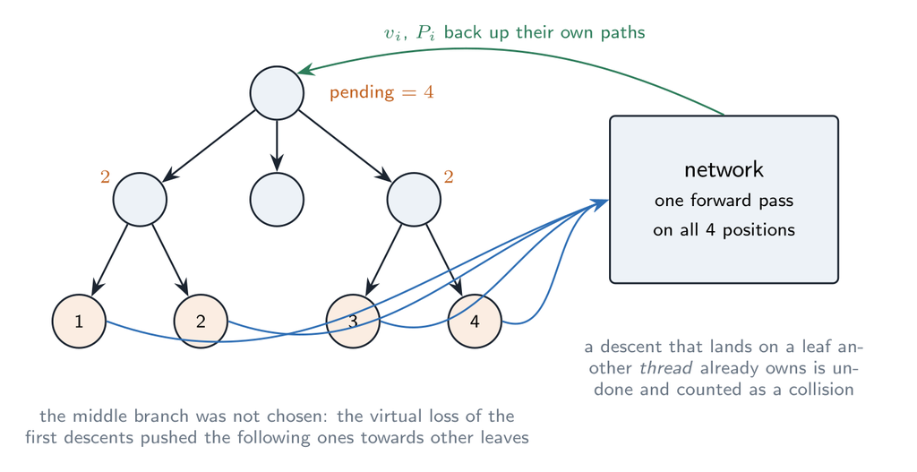

Figure 6: Gathering a batch. The `pending` counters are the virtual loss.

Every descent increments a `pending` counter on each node and edge it passes, and PUCT treats a pending visit as a **loss**:

$$Q(s,a) \;=\; \frac{W(s\cdot a) - \text{pending}(s\cdot a)}{N(s\cdot a) + \text{pending}(s\cdot a)}$$

so the next descent sees the branch as temporarily worse and goes elsewhere. When the batch comes back, `backup` converts each pending visit into a real one; a descent that is abandoned calls `undo_pending` instead.

Three things can happen when a descent reaches a node in the `EXPANDING` state:

- **it is one of our own batch’s leaves** — the descent piggybacks on the same network call. It records *its own path*, because two descents can reach the same leaf along different routes (and under graph search, through different parents entirely); the same value is then backed up along each path separately;
- **it belongs to another thread** — the descent is undone and counted as a collision. After `max_collisions` of those the batch is closed early;
- the state changed under us, in which case the loop simply re-reads it.

## 5.6 Graph search

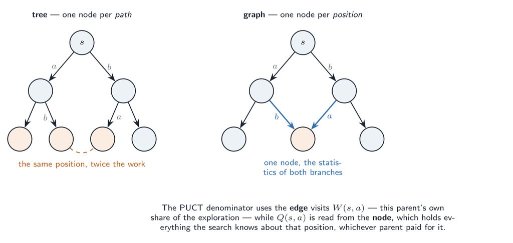

Figure 7: A tree duplicates transposed positions; a graph shares them.

The data structures split in two:

```cpp
struct Node {                 // one per position
    atomic<uint32_t> n, pending;
    atomic<float>    w, w2;
    atomic<uint8_t>  state;
    float            net_v;
    pmr::vector<Edge> children;
};
struct Edge {                 // one per (position, move)
    Move action; float prior;
    atomic<Node*>    child;   // created on first descent
    atomic<uint32_t> n, pending;   // THIS parent's share
};
```

and PUCT reads from both:

- $W(s,a)$, the denominator, is the **edge** count — this parent’s own share of the exploration, so a node that other parents have hammered does not look exhausted from here;
- $Q(s,a)$ is the **node**’s average — everything the search knows about that position, whoever paid for it.

That split is exactly KataGo’s `childWeight = rawChildWeight · edgeVisits / childVisits`, which for a search weighting every visit by 1 collapses to “the edge visits”.

Child nodes are created **lazily**, on the first descent through their edge, not when the parent is expanded. Expansion allocates $|\,\text{moves}\,|$ edges (16 bytes each) instead of $|\,\text{moves}\,|$ full nodes, which is the difference between ~3 200 nodes and ~20 000 nodes for a 3 200-simulation search.

### 5.6.1 The node key

```cpp
uint64_t node_key(uint64_t zobrist_hash, const Yolah& state) {
    return zobrist_hash ^ mix(uint64_t(state.score().first) + 1);
}
```

The white score is implied: the two sum to the number of holes, which the board already determines.

The hash is maintained incrementally during a descent with `zobrist::update`, so linking an edge costs a multiply and a table probe, not a 64-square scan.

### 5.6.2 Tree reuse and garbage collection

With a node table, re-rooting stops being a search. `Search::reuse` looks the new position up by key; if it is there, it becomes the root with every statistic it has accumulated — at whatever depth it sat in the old graph, reached through whatever move order. The two-ply scan the tree version needed (root, children, grandchildren) is gone.

What re-rooting does need is a sweep, or memory grows without bound over a game. `collect()` marks everything reachable from the new root — a plain recursion, safe because the graph is acyclic — and destroys the rest. This runs once per move, and the mark is a generation counter rather than a per-node flag reset.

Setting `graph search: false` keeps the tree behaviour (every edge gets a fresh node under a unique key, and `reuse` falls back to the two-ply scan), which is how the two are A/B-compared.

## 5.7 At the root

Three things happen at the root and nowhere else.

### 5.7.1 Dirichlet noise

For self-play only, the root priors are mixed with Dirichlet noise so that repeated self-play games do not all follow the same line:

$$P'(s_0,a) \;=\; (1-\epsilon)\,P(s_0,a) \;+\; \epsilon\,\eta_a,
\qquad \eta \sim \mathrm{Dir}(\alpha)$$

with $\epsilon = 0.25$ and $\alpha = 0.3$ typical. The noisy priors live in `root_priors` and are used by PUCT *and* reported as the priors — the tree’s stored priors are untouched, so a re-rooted subtree is not contaminated.

### 5.7.2 Forced playouts

Noise only helps if the move it promotes actually gets tried more than once. A single bad evaluation is enough for PUCT to drop a move for the rest of the search, which wastes the noise. So, at the root, any child that has been visited **at least once** is forced up to

$$n_{\text{forced}}(a) \;=\; \sqrt{k\;P(s_0,a)\;W(s_0)}$$

visits ($k = 2$ in the KataGo paper) by giving it an overwhelming selection score while it is below that bar. Off by default (`forced_playouts_k = 0`); it belongs to self-play, and it is also automatically disabled on the fast searches of Section 5.8.

### 5.7.3 Policy target pruning

Forced playouts are deliberate distortions of the visit distribution — training on them would teach the network the noise. They are taken back out afterwards: for every child except the most-explored one, ask what visit count PUCT would *retrospectively* have wanted, by inverting the selection formula at the best child’s selection value

$$V^\star = Q(s_0,a^\star) + c\,\hat\sigma\,\sqrt{W+\varepsilon}\;\frac{P(s_0,a^\star)}{1+W(s_0,a^\star)}$$

$$n'(a) \;=\; \min\!\left(n(a),\;
\left\lceil\; \frac{c\,\hat\sigma\,\sqrt{W+\varepsilon}\;P(s_0,a)}{V^\star - Q(s_0,a)} - 1 \right\rceil\right)$$

A child whose value alone already beats $V^\star$ keeps all its visits; one that only got there because it was forced collapses towards zero. These *play values* — not the raw visit counts — are what becomes $\pi$ and what the move is chosen from. KataGo applies this at the root unconditionally, not only in self-play, and so does this implementation.

### 5.7.4 LCB move selection

The most-visited move is not always the best one to play: a move can accumulate visits early and then stop improving, while a less-visited sibling has a genuinely better and tighter value. The move played is instead the one with the best **lower confidence bound**

$$\text{lcb}(a) \;=\; Q(s_0,a) \;-\; \lambda_{\text{lcb}}\;\hat\sigma_{\bar Q}(a),
\qquad \hat\sigma_{\bar Q}(a) = \sqrt{\frac{\mathrm{Var}(a)}{\text{ess}(a)}}$$

with $\lambda_{\text{lcb}} = 5$, restricted to children holding at least `min_visit_prop_for_lcb` = 20 % of the leader’s play value — below that the bound is meaningless. The variance comes from the child node’s $W$ and $W^2$, regularised by a prior saying the variance could be as large as the whole utility range, with a weight that vanishes as $1/n^2$:

$$\overline{u^2} \leftarrow \frac{\overline{u^2}\,n + (\overline{u^2} + R^2)\,w_p}{n + w_p},
\qquad w_p = \frac{1}{n^2},\quad R = 1$$

The winner does not simply override the choice: following KataGo, it is given just enough play value to beat every other child, which keeps $\pi$, the sort order and the move choice consistent with one another.

## 5.8 Playout cap randomization

A self-play move needs a large budget only if its policy target is going to be recorded. Most of the value of a self-play game is in the *game* — the sequence of positions and its result — and that only needs decent play.

So, with probability `playout_cap_fast_prob`, a search runs `nb_simulations_fast` simulations with **no root noise, no forced playouts**, and reports `full_search = false`; the driver records the position and the result but no policy target. The remaining moves get the full budget, the noise, the forced playouts, and a recorded $\pi$. The paper’s numbers are roughly 75 % fast at a quarter of the budget, which buys most of a full-budget game for a fraction of the network calls.

Off by default: it needs both `nb_simulations` and `nb_simulations_fast` set.

## 5.9 Choosing the move, and the policy target

```
play values ──► normalise ──► π   (training target)
             └► argmax          (competitive play)
             └► sample ∝ π^(1/τ) (self-play opening, ply < temperature_cutoff)
```

$\tau$ is the sampling temperature and `temperature_cutoff` the ply after which the search stops sampling and starts playing the best move. If the search could not complete a single simulation — a time budget too small for one network call — the priors stand in for $\pi$ and the highest-prior move is played.

# 6 Learning by self-play

The network of the previous chapters was trained by *supervised* learning: it imitated the moves and the results of an existing corpus of games. It can therefore never become much stronger than whoever played those games. This chapter describes the loop that removes that ceiling: the engine plays against itself, learns from those games, plays better games with what it learned, and so on — AlphaZero’s recipe, with the refinements of KataGo.

The chapter follows the data. First the idea (Section 6.1) and the processes (Section 6.2); then self-play, which produces the data (Section 6.3); the trainer, which consumes it (Section 6.4); the evaluation matches, which measure the result (Section 6.5); how it all runs on the cluster and how the resources were sized (Section 6.6, Section 6.7); and finally KataGo’s auxiliary heads, the most promising next step (Section 6.9).

## 6.1 The idea

Look at what one search does to the network’s opinion. The network gives a prior $p(\cdot\mid s)$ and a value $v(s)$; 800 simulations later the search returns a distribution $\pi(\cdot\mid s)$ over the moves and a value. Both are **better** than what went in — that is the whole point of searching. So the search is a *policy improvement operator*: it maps a network to a stronger player. If we now train the network to predict $\pi$ (instead of $p$) and the final result $z$ of the game (instead of $v$), the next network starts where the last search ended. Iterate:

$$\underbrace{f_\theta}_{\text{network}}
\;\xrightarrow{\ \text{MCTS}\ }\;
\underbrace{(\pi, z)}_{\text{better targets}}
\;\xrightarrow{\ \text{SGD}\ }\;
f_{\theta'}
\;\xrightarrow{\ \text{MCTS}\ }\;\cdots$$

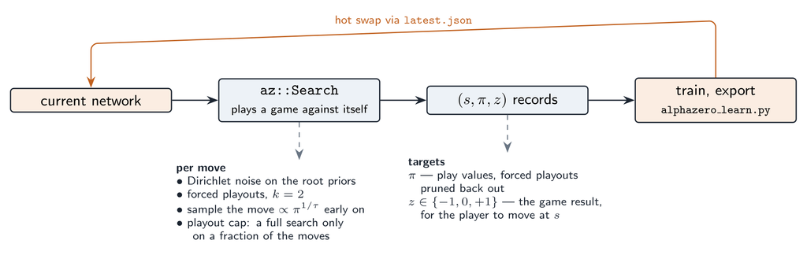

Figure 8: One turn of the loop: the network plays, the games become targets, the targets train the network.

This is *generalised policy iteration*: the search does the policy improvement step and the gradient descent does the policy evaluation step. No human games, no hand-made evaluation: the only knowledge injected is the rules, through the legal moves and the final score.

Why does it not just go round in circles? Because the two targets pull the network towards something strictly better than itself. $\pi$ is the result of looking ahead with the current network — a network that predicts $\pi$ directly has “compiled” 800 simulations of look-ahead into one evaluation. $z$ is the *actual* result of the game, which no amount of self-deception can change: a network that believes a position is won while it keeps losing from there gets corrected. Each iteration the searches become stronger because the network guiding them is better, and the targets become better because the searches are stronger.

Our starting point is not a random network but the supervised `cnn_resnet_256x30_value_policy.pt`. That changes the tuning (small learning rate, no need to explore wildly at first) but not the algorithm.

## 6.2 The pieces and how they talk

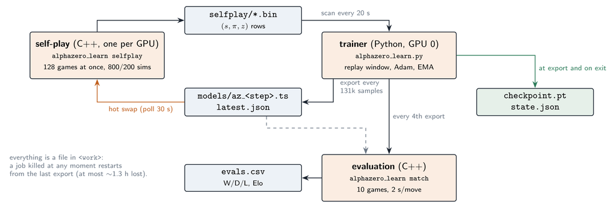

Figure 9: The learning loop. Three kinds of process, and every exchange between them is a file in the work directory.

Three programs run at the same time on one node (Figure 9):

1. **Self-play** — `alphazero_learn selfplay`, C++ (`player/alphazero_selfplay.cpp`), one process per GPU. It plays games with the newest network and writes training rows to `selfplay/*.bin`.
2. **The trainer** — `nnue/alphazero_learn.py`, Python. It is also the orchestrator: it launches and supervises the other two. It keeps a *replay window* of recent rows, takes gradient steps, and every `--export-every` training samples exports a new network (`models/az_<step>.ts`) and announces it in `latest.json`. Self-play picks the new network up at its next poll.
3. **Evaluation** — `alphazero_learn match`, C++ (`test/alphazero_learn_main.cpp`), started by the trainer every 4 hours. It plays 20 games of 2 s per move between the newest network and the previously evaluated one and appends the result to `evals.csv`.

Why files rather than sockets or shared memory? Because the run must survive being killed. A cluster job ends after two weeks and the loop must continue in the next one. With every exchange being a file that is renamed into place once it is complete (a POSIX rename is atomic), a process that dies at any moment leaves only complete files behind. The next job re-reads them and continues (Section 6.6).

There is no *gating*. The original AlphaGo Zero only promoted a new network after it beat the current one by 55 %; AlphaZero and KataGo dropped this and always self-play with the latest network, which is simpler and was found to be at least as good. The evaluation matches here are a **thermometer**, not a gate: they tell you whether learning progresses, they do not steer it.

## 6.3 Self-play: many games, one GPU

### 6.3.1 Why many games at once

A 30-block network is only efficient on the GPU with large batches: about 7 600 positions/s at batch 256 in fp16 on an RTX 3080, a small fraction of that at batch 8. A single MCTS, on the other hand, degrades when it evaluates many leaves at once: with a batch of $B$ leaves it must choose $B$ descents *before* knowing any of their results (virtual loss), and beyond a few dozen leaves the descents collide and wander.

The solution is to decouple the two: run **many independent games**, each with its own single-threaded `az::Search` asking for only 8 leaves at a time, and let an `nn::BatchingEvaluator` merge the requests of all the games into one GPU call (Figure 10). With 128 games the GPU sees batches of up to 1024 positions, while each search behaves almost like a sequential one.

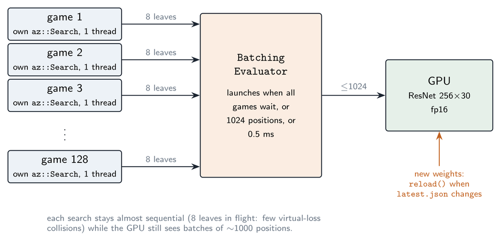

Figure 10: Many games share one network. Each search is almost sequential; the batcher gives the GPU large batches.

The batcher launches a GPU call as soon as *every* game is waiting, or the maximum batch (8 × number of games) is queued, or 0.5 ms have passed. When a game ends, its thread immediately starts the next one, so the number of games in flight stays constant; `set_nb_clients` is lowered only when a thread really exits (at the end of the run), otherwise the batcher would wait 0.5 ms for a client that will never come.

How many games? Enough to saturate the GPU, no more. On the RTX 3080, 128 games already keep it at 95 % and reach ~8 500 evaluations/s; 256 games do not do better (the batches get larger but the GPU was already busy). Two processes of 64 games on the same GPU do *worse*, ~6 000/s in total: each batch is half as large and the two processes contend for the device. Hence one process per GPU, with as many games as the GPU can absorb: 256 on the 48 GB cluster GPUs, which (A40 and RTX 8000) should have 2–2.5 times the fp16 throughput of a 3080 (Section 6.7).

The code of one game is short enough to read in full:

```cpp
Yolah y;
std::vector<TrainingSample> samples;
search.reset();                                   // new game: forget the graph
while (!y.game_over() && !stop.load()) {
    const uint64_t g = generation.load(std::memory_order_acquire);
    if (g != seen) {                              // the network changed:
        search.reset();                           //   the graph's priors and values
        search.clear_cache();                     //   and the cached evaluations are stale
        seen = g;
    }
    const SearchResult r = search.search(y);      // 800 or 200 simulations
    if (r.full_search && !r.children.empty())     // only full searches are recorded
        samples.push_back(make_sample(y, r, model_step.load()));
    y.play(r.best_move);                          // sampled ∝ π^(1/τ) early, best later
}
// ... then z is filled in for every sample, and the game goes to the writer
```

### 6.3.2 The self-play settings, and why

`config/alphazero_mcts_selfplay_player.cfg`:

| key | value | why |
| --- | --- | --- |
| `nb simulations` | 800 | the budget of a *full* search (AlphaZero) |
| `playout cap fast prob` / `nb simulations fast` | 0.75 / 200 | playout cap randomization, Section 5.8 |
| `dirichlet epsilon` / `alpha` | 0.25 / 0.3 | root noise: tries moves the prior would never try |
| `temperature` / `temperature cutoff` | 1.0 / 20 | the first 20 plies are *sampled* $\propto \pi$: diverse openings |
| `forced playouts k` | 2 | every root move tried at least $\sqrt{k\,P\,N}$ times |
| `policy target pruning` | true | … and those forced visits are removed from $\pi$ again |
| `batch size` | 8 | leaves per search per network call (see above) |
| `nn cache` | 16 MB | per game; the cluster job raises it to 32 MB (768 games × 32 MB = 25 GB) |

**Playout cap randomization** deserves a word, since it shapes the data. Value targets are cheap: every position of a game gets the game result $z$. Policy targets are expensive: a good $\pi$ needs a big search. KataGo’s observation is that one can play *most* moves with a small search (200 simulations, no noise) — the game advances four times faster — and do a full 800-simulation search, and record a training row, only on a random 25 % of the moves. More games per hour means more value targets and more diverse positions; the policy targets that are recorded all come from full searches. The fast moves are **not recorded at all**: their $\pi$ would be a poor target, and recording only their $z$ would over-weight the value head.

Per recorded row this costs, on average, one full search plus three fast ones: $800 + 3 \times 200 = 1\,400$ simulations, a little less in network calls since tree reuse and the network cache save some. Measured: ~1 200 network evaluations per training row. That single number converts any GPU’s evaluation rate into a data rate (Section 6.7).

### 6.3.3 What a training row contains

Each recorded position becomes a fixed-size, 336-byte record (`az::TrainingSample` in `player/alphazero_selfplay.h`, mirrored field by field by `SAMPLE_DTYPE` in `alphazero_learn.py`):

| field | type | meaning |
| --- | --- | --- |
| `black`, `white`, `empty` | 3 × `uint64` | the bitboards — exactly the network’s input |
| `turn` | `uint8` | 0 = black to move, 1 = white |
| `z` | `int8` | final result for the side to move: $-1, 0, +1$ |
| `nb_moves` | `uint8` | number of legal moves stored |
| `root_q` | `float` | the search’s value of the position (monitoring) |
| `model_step` | `uint32` | which network played this move |
| `action[75]` | `uint16` | policy index `from*64+to` of each legal move |
| `prob[75]` | `uint16` | $\pi(a)\cdot 65535$, rounded |

$\pi$ is stored sparsely, over the legal moves only (at most 75 in Yolah), quantised to 16 bits — a resolution of $1.5\times10^{-5}$, far below the noise of an 800-visit estimate. A dense 4096-float target would take 16 KB per row instead of 336 bytes.

The value target is filled in when the game ends. In Yolah every move scores one point for the player who makes it, so the final scores are the numbers of moves each side managed to make. A position where colour $c$ is to move gets

$$z = \operatorname{sign}\big(\text{score}_c - \text{score}_{\bar c}\big) \in \{-1, 0, +1\},$$

the same convention as the network’s value head and the search’s `terminal_value`.

Rows are grouped in files of about 2 000 (or every 10 minutes), named `<milliseconds since 1970>_<host>_gpu<k>_<seq>.bin`. Sorting the names sorts the files by age, across GPUs, hosts and jobs, which is all the trainer needs.

### 6.3.4 Hot-swapping the network

The supervisor thread of `run_selfplay` reads `latest.json` every 30 s. When the step changes it calls `evaluator.reload(path)`. That is safe while hundreds of games are searching: the libtorch backend takes its own mutex both in `evaluate` and in `load`, so a reload simply waits for the batch in flight and the next batch runs on the new weights. The supervisor then bumps an atomic `generation`; each game notices it before its next move and throws away its graph and its network cache, whose values came from the old weights. The rest of the game is played by the new network — a game may thus mix two consecutive networks, which KataGo also accepts: consecutive networks differ by a few hundred gradient steps.

## 6.4 The trainer

### 6.4.1 The replay window

Which rows should the network learn from? Only the most recent ones are made by a network close to the current one; old rows describe the play of a weaker player and their $\pi$ is a worse target. But too small a window over-fits the last few thousand games. KataGo’s answer (`python/shuffle.py`) is a window that grows **sub-linearly** with the total number of rows $N$ generated so far:

$$W(N) = N_0\left(1 + \beta\,\frac{(N/N_0)^{\alpha} - 1}{\alpha}\right),
\qquad \alpha = 0.75,\ \beta = 0.4 .$$

For $N \le N_0$ everything is used. After that the window keeps growing — a stronger network deserves more data to fit — but slower and slower, so the fraction of the history in use shrinks: with KataGo’s $N_0 = 2.5\cdot10^5$ (the cluster setting), $W$ is 1.1 M rows (31 %) at $N = 3.5$ M and 12 M (12 %) at $N = 100$ M (Figure 11). The derivative tells the same story: $W'(N) = \beta\,(N/N_0)^{\alpha-1}$ is the fraction of each new batch of rows that *enlarges* the window rather than replacing its oldest rows — 40 % at the start, 9 % after 100 M rows. $W$ is also capped by `--max-window` (16 M rows, 5.4 GB of RAM on the cluster).

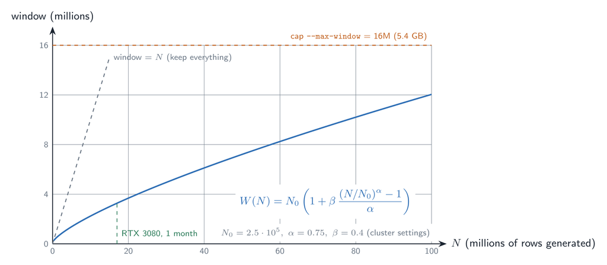

Figure 11: Replay window size as a function of the amount of data generated, with the cluster settings.

The implementation is a **ring buffer** of `--max-window` rows. New files are appended at the head; a batch draws uniform indices among the last $W(N)$ rows:

```python
def sample(self, batch_size, rng):
    w = self.window_size()
    back = rng.integers(1, w + 1, size=batch_size)      # 1 = newest row
    return self.buf[(self.head - back) % self.capacity]
```

On a restart, only the files that can still be in the buffer are read (the tail of the history, newest first until the capacity is reached); the headers of the others are enough to know $N$.

### 6.4.2 How much to train: the reuse ratio

The trainer and self-play run concurrently, so something must keep them in step. If the trainer ran freely it would take thousands of steps on the first rows and over-fit them; if it were too slow, self-play would keep playing with an outdated network. The rule is a **fixed number of training samples per generated row** (`--reuse`, default 4):

$$\text{samples trained} \;\le\; r \cdot N .$$

When the trainer reaches the bound it sleeps until more rows arrive. With $r = 4$ each row is drawn about 4 times while it is in the window (in expectation; the draws are random). Training starts when $N \ge N_0$.

The trainer is never the bottleneck: one GPU trains the 256×30 network at ~3 400 samples/s (RTX 3080, batch 1024, 4.9 GB), while even three cluster GPUs of self-play generate a few tens of rows per second, i.e. a hundred or two training samples per second at $r = 4$.

### 6.4.3 The loss

For a row $(s, \pi, z)$ and the network output $(v, \ell)$ — value and the 4096 logits — the loss is the AlphaZero one with a **soft** policy target:

$$\mathcal{L}(\theta) \;=\; \lambda_v\,\big(v_\theta(s) - z\big)^2
\;-\; \lambda_p \sum_{a\,\in\,\text{legal}(s)} \pi(a)\,\log p_\theta(a \mid s),
\qquad
p_\theta(a\mid s) = \frac{e^{\ell_a}}{\sum_{b=1}^{4096} e^{\ell_b}} .$$

With $\lambda_v = \lambda_p = 1$. Three remarks:

- The softmax runs over all 4096 logits, like in supervised training; the illegal moves are simply never targets, so their logits are pushed down. The search itself only ever reads the legal ones.
- The policy term is a cross-entropy, which decomposes as $H(\pi, p) = H(\pi) + \mathrm{KL}(\pi \,\|\, p)$. The entropy $H(\pi)$ of the targets does not depend on $\theta$, so what the gradient reduces is the KL divergence. The trainer logs both `p` (the cross-entropy) and `kl` — the latter is the interpretable one: 0 means the network already predicts what the search finds.
- The gradient of the policy term with respect to the logits is simply $\partial\mathcal{L}/\partial \ell_a = \lambda_p\,(p_\theta(a\mid s) - \pi(a))$: every logit is pushed up or down by how much the network under- or over-estimates what the search found.

In code, with the sparse targets gathered from the log-softmax:

```python
v, logits = net(x)
logp   = F.log_softmax(logits.float(), dim=1).gather(1, actions)   # (B, 75)
p_loss = -(probs * logp).sum(1).mean()                              # padding has prob 0
v_loss = F.mse_loss(v.float(), z)
loss   = args.value_weight * v_loss + args.policy_weight * p_loss
```

### 6.4.4 Blending the result with the search value

The value head learns to predict $z$, the result of the game. For a given position that target is **exact but noisy**: everything played afterwards counts in it, and in Yolah — a third of draws, most wins by one or two points (Section 6.7.2) — a position ends up labelled 0 or +1 by the accidents of the rest of the game as much as by its own merit.

Every row also carries a second estimate of the same quantity: $q$, the value the full search (800 simulations) found for the position when it was played (`root_q`, for the side to move, the convention of $z$ and of the value head). $q$ summarises hundreds of continuations, so it is **much less noisy — but biased**: it comes from the current network, and inherits its errors. The option `--q-weight` $w$ trains the value on a blend of the two:

$$\text{target} = (1 - w)\,z + w\,q, \qquad \mathcal{L}_v = \big(v_\theta(s) - \text{target}\big)^2 .$$

It is the classic bias–variance trade-off of reinforcement learning: $z$ is the Monte-Carlo return, $q$ a bootstrapped estimate — the temporal-difference side, which KataGo’s short-term value targets (Section 6.9) develop further. Some AlphaZero re-implementations report a gain from averaging the two. $w$ must stay well below 1: with $q$ alone, the network would learn only from itself and could lock into its own mistakes; the share of $z$ keeps it anchored to real results.

On local test games, $q$ and $z$ are correlated at 0.82, the blend ($w = 0.5$) lowers the variance of the target from 0.69 to 0.49, and the positions of the drawn games are far from being all “draws” in the eyes of the search ($q$ has a standard deviation of 0.27 on them). The option costs nothing: the C++ side does not change — `root_q` has been recorded in every row since the first version of the format — and it applies at once to the rows already generated.

```python
z = torch.from_numpy(rows["z"].astype(np.float32)).to(dev)
if self.q_weight > 0:
    q = torch.from_numpy(rows["root_q"].astype(np.float32)).to(dev).clamp(-1.0, 1.0)
    z = (1.0 - self.q_weight) * z + self.q_weight * q
```

On the cluster: `sbatch --export=ALL,Q_WEIGHT=0.5 alphazero_learn.sh`; the job’s header and log print the target in use.

### 6.4.5 Optimiser and numerics

- **Adam**, learning rate $10^{-4}$ (the supervised run ended its cosine schedule at $10^{-5}$ from $10^{-3}$), L2 weight decay $10^{-4}$ as in supervised training, a linear warm-up over the first 500 steps (the optimiser’s moment estimates start from zero after a fresh start), gradient norm clipped at 5.
- **Mixed precision** chosen as in the supervised trainer: bf16 on Ampere and newer (the cluster’s A40), fp16 with a gradient scaler on Turing (its RTX 8000, whose bf16 is emulated and slow). Consecutive jobs of one run may land on either, so the checkpoint must survive the switch: a bf16 job saves the state of a *disabled* gradient scaler, which is empty and which an enabled scaler refuses to load. The trainer then simply starts the scaler afresh — its scale adapts within a few steps. (`--amp` forces one or the other; that is how both switches were tested.)
- **Batch 1024**, channels-last memory layout (faster convolutions on tensor cores), `cudnn.benchmark` on — without it, cuDNN’s default algorithms for this layout were an order of magnitude slower in our measurements.
- BatchNorm is in training mode: its running statistics follow the self-play data distribution.

### 6.4.6 Data augmentation: the 8 symmetries

The rules of Yolah do not change if the board is rotated by a quarter turn or mirrored: pieces move like queens and the initial position is symmetric. The position $s$ and its image $g(s)$ under any of the 8 symmetries $g$ of the square (the dihedral group $D_4$) therefore have the same value, and the policy of $g(s)$ is the policy of $s$ with every move transformed by $g$:

$$v(g\,s) = v(s), \qquad \pi(g\,a \mid g\,s) = \pi(a \mid s).$$

Each training row is shown to the network under a random one of the 8 transformations — eight times more data for free, and a network pushed towards the symmetry it should respect (Figure 12).

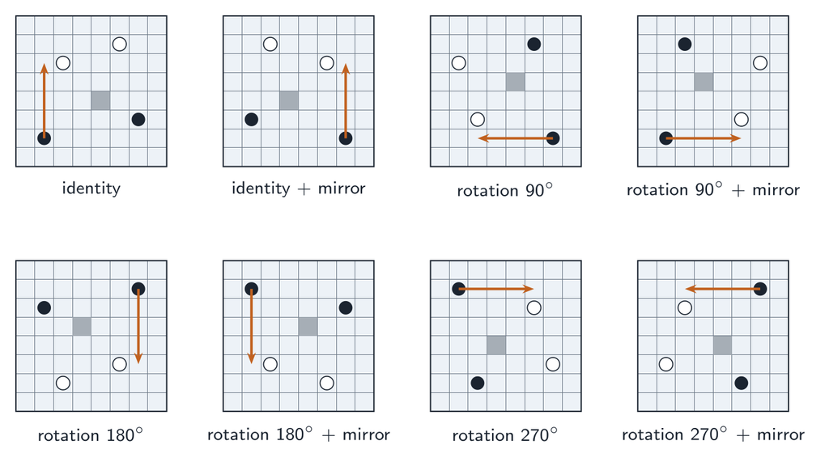

Figure 12: One position and one move under the 8 symmetries of the board. The value is the same for all eight; the move turns with the board.

The only subtlety is bookkeeping. The network input stores square $q$ in plane cell $c = 63 - q$ (Section 3), and moves are indexed by *squares*. The tables are therefore computed on cells and converted:

```python
cells = torch.arange(64).view(8, 8)
src = [f(rot90(cells, k)) for k in 0..3 for f in (identity, flip)]  # (8, 64)
# new plane cell j takes the value of old cell src[g, j]
inv = argsort(src)                        # inv[g, old cell] = new cell
sq  = 63 - inv[:, 63 - arange(64)]        # old square -> new square
act = sq[:, :, None] * 64 + sq[:, None, :]  # (8, 4096): move index -> move index
act[:, 0] = 0                              # index 0 is the pass, and stays the pass
```

The planes are permuted with one `gather`, the move indices with one table lookup, both on the GPU. The tables were checked against the rules: for 200 self-play positions and all 8 symmetries, the transformed legal moves of $s$ are exactly the legal moves of $g(s)$ computed by `server/yolah.py`.

### 6.4.7 Averaging the weights before export

The weights after the last gradient step are a noisy point: SGD bounces around the minimum. KataGo exports a *stochastic weight average* of recent snapshots; here we keep an **exponential moving average** of the weights, updated after every step:

$$\bar\theta \leftarrow \mu\,\bar\theta + (1-\mu)\,\theta, \qquad \mu = 0.995 .$$

Unrolled, $\bar\theta_t = (1-\mu)\sum_{k\ge0}\mu^k\,\theta_{t-k}$: step $t-k$ weighs $\mu^k$, the weights have mean age $\mu/(1-\mu) \approx 200$ steps. It is $\bar\theta$ that is exported and played by self-play, $\theta$ that keeps training. The BatchNorm running statistics are averaged the same way (`AveragedModel(..., use_buffers=True)`), so that the exported network is consistent.

### 6.4.8 Export and publication

Every `--export-every` training samples (524 288 = 512 steps of 1024 on the cluster; with 4 samples per row, one network every 131 072 new rows):

1. `az_<step>.pt` — the plain `state_dict` of $\bar\theta$ (it can be fed to `resnet_export.py` for the CPU `.bin` backend);
2. `az_<step>.ts` — the network traced with `torch.jit.trace` in eval mode, exactly like `resnet_export.py` does, for the libtorch backend;
3. `latest.json` rewritten — self-play switches within 30 s;
4. `checkpoint.pt` (weights, EMA, optimiser, gradient scaler) and `state.json` (counters, evaluation state) rewritten.

Every write goes to a temporary name and is `os.replace`d into place.

A 256×30 network is 141 MB per file and a month produces hundreds of exports, so old files are pruned (`cleanup_models`): an export that was never evaluated disappears at the next export; an evaluated one keeps its `.pt` — the history of the run, at 141 MB per evaluation — but loses its `.ts` once it can no longer be an opponent. If it is needed again (`--eval-opponents lag:K`), `Evaluator.ensure_ts` re-traces it from the `.pt`; the re-traced module gives bit-identical outputs. `--keep-all` disables pruning.

## 6.5 Measuring progress

### 6.5.1 The match protocol

Every 4 hours (`--eval-hours`; the first export of a run is evaluated at once), the newest network plays **20 games** against an older one, **2 seconds per move**, both sides using the competitive settings of `config/alphazero_mcts_eval_player.cfg` (no noise, no sampling, LCB). The opponent is by default the **previously evaluated network** (`--eval-opponents previous`; `initial` and `lag:K` are also available and can be combined). The schedule is in wall-clock time rather than in exports because the export rate depends on the GPUs, which differ between the development machine and the cluster; `--eval-every K` switches to one evaluation every $K$ exports.

A detail matters here. Two deterministic players repeat the same game from the same position: 10 games with the new network as black would be *one* game played ten times. So each pair of games starts from its own opening, and the new network plays it once with each colour (Figure 13). The pair cancels the bias of the opening, whichever side it favours — and the first player’s advantage in Yolah is large (Section 6.7.2). The openings were at first random (4 plies); they now come from a book of balanced openings (Section 6.5.3), after which the colour decides far fewer pairs.

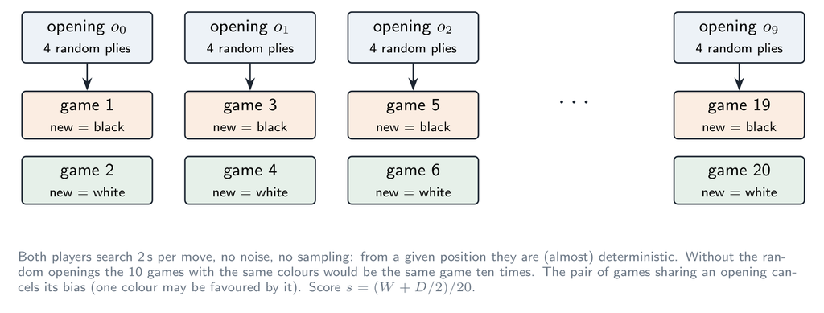

Figure 13: The 20 evaluation games: 10 openings, each played once with each colour.

A match takes $20 \times 55 \times 2\ \text{s} \approx 37$ minutes. It runs on the last GPU while that GPU also plays self-play games: both players suffer the same contention, so the comparison is fair, but “2 s per move” buys fewer simulations than on an idle GPU.

### 6.5.2 From a score to Elo

With $W$ wins, $D$ draws and $L$ losses out of $n = 20$ games, the score is $s = (W + D/2)/n$. Under the Elo model the expected score of a player $\Delta$ points stronger is $1/(1+10^{-\Delta/400})$; inverting,

$$\Delta = 400 \log_{10}\frac{s}{1-s} .$$

A 20–0 result would give $\Delta = \infty$, so the estimate uses a half-game prior: $\tilde s = (W + D/2 + 1/2)/(n + 1)$, which caps $|\Delta|$ at 645. Each evaluation adds its $\Delta$ to the opponent’s rating, giving a **chained Elo** for every evaluated network relative to the initial one (`model_elo` in `evals.csv`).

**WarningTwenty games is a thermometer, not a microscope**

The standard error of a score over $n$ games is at most $\sqrt{s(1-s)/n}$, i.e. 0.11 for $n = 20$ near $s = 0.5$ (less if there are many draws). Through the slope of the Elo curve at $s = 0.5$, $d\Delta/ds = 1600/\ln 10 \approx 695$, that is **±78 Elo** for one evaluation. The chained Elo accumulates the errors of every link like a random walk: ±78·$\sqrt{k}$ after $k$ links. Read the **trend** over many evaluations, not any single one; a run that learns shows a chained Elo that climbs steadily. For a precise comparison of two networks at the end, play a few hundred games (200 games: ±25 Elo, 400: ±17) with `nnue/alphazero_match.sh`, a separate 1-GPU job that can run alongside the learning job:

```bash
sbatch alphazero_match.sh                              # latest vs initial, 200 games, 0.5 s/move
sbatch --export=ALL,A=7168,B=4096,GAMES=400 alphazero_match.sh
sbatch --export=ALL,BOOK=none alphazero_match.sh       # random openings instead of the book
```

It copies the two networks first (the learning job prunes old files at every export), re-traces a network from its `.pt` if its `.ts` was pruned, plays the games in pairs like the evaluations, and appends A’s result with its 95 % confidence interval to `WORK_DIR/matches.csv`.

Adding `initial` to `--eval-opponents` gives an unchained measurement against a fixed reference, at the cost of another 20 games per evaluation.

### 6.5.3 A book of balanced openings

**1. Candidates.** 200 000 random openings of 6 plies (3 per side; uniformly random legal moves, none ending the game). Two openings can lead to the same game up to a symmetry: 4 of the 8 symmetries of the board (Section 6.4.6) map the initial position to itself — the identity, the half turn and the two diagonal flips; the other four send the black pieces to the white ones’ initial squares. Each opening is reduced to the smallest of its 4 images (`canonical`) and only one opening per class is kept. (That the 4 transformations turn a game into a game was checked on 2 000 random games of 30 plies: the transformed moves are always legal and give the transformed positions; for an axis mirror they never are.)

**2. Values.** Each candidate is searched by the minimax player (the dev player with the `spacelite` network, one thread) at a **fixed depth** rather than a fixed time, so that the book is reproducible from its command line, which is written in its header. The values are turned to Black’s point of view, on the search’s scale where ±30 000 is tanh ±1. Most random openings are far from balanced (Figure 14, left): the initial position is worth +0.35 to Black at depth 12, the random openings +0.47 on average, and only 15 % lie within ±0.27. A search at depth 6 ($\approx$ 0.1 s) discards the others — its values correlate at 0.95 with those of depth 10 — and the 29 598 left are searched again at depth 12 ($\approx$ 0.25 s each; 24 minutes on 18 cores in all, two thirds of them for the depth-6 filter).

**3. Calibration.** A first book took the 1 000 openings closest to a value of 0, and was too good for White: from it the minimax player against itself scored only 0.41–0.47 with Black, depending on the depth. A value of 0 is not an even game. To find the value that is, 6 000 of the 29 598 openings (all values, from −0.58 to +0.54) were played out, minimax against itself at depth 10, and Black’s score was regressed on the depth-12 value (Figure 14, right): it reaches 1/2 at **+0.12** (+3 500; 95 % interval of the regression’s zero +2 500 to +3 900). The book is therefore the openings whose value is closest to +3 500, written in a random order so that a short match does not only use the most balanced ones. A first version kept 1 000 of them (all within 3 500 ± 312); the book now has **4 000** (within 3 500 ± 1 198, i.e. ±0.04), so that the minimax campaigns, 2 000 pairs per task, never play an opening twice. By the slope of the calibration, ±0.04 moves Black’s expected score by about ±2.5 % at most, and the average stays at ½.

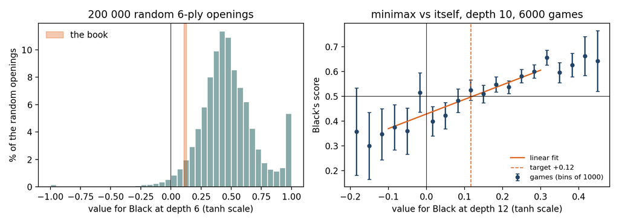

Figure 14: Left: the depth-6 value of 200 000 random 6-ply openings for Black, and the depth-12 window the book is taken from. Right: Black’s score in 6 000 games of the minimax player against itself at depth 10, by the depth-12 value of the opening; 1/2 is reached at +0.12, not 0.

The regression also says how little a value says about one game: the correlation between an opening’s value and the game’s result is 0.17. Over this range, the opening shifts the odds by a few percent per 0.03; the rest is the play. That is the point — the openings should leave the result to the players.

**4. Checks.** `opening_book check` plays from the book (and, for comparison, from random 4-ply openings) with the minimax player:

| games, minimax against itself | Black’s score |
| --- | --- |
| book of 1 000, 1 000 games at depth 6 / 8 / 10 / 12 (±0.025) | 0.496 / 0.498 / 0.520 / 0.499 |
| **book of 4 000**, 4 000 games at depth 8 / 10 / 12 (±0.012) | 0.502 / 0.515 / 0.517 |
| random 4-ply openings, 1 000 games at depth 10 | 0.724 |

| pairs (each opening, both colours) | colour decides the pair | stronger wins both | stronger’s score (Elo) |
| --- | --- | --- | --- |
| depth 8 vs 6, random openings | 30.9 % | 30.9 % | 0.698 (+146) |
| depth 8 vs 6, **book** | **18.6 %** | **38.2 %** | 0.739 (+180) |
| depth 10 vs 8, random openings | 26.9 % | 25.9 % | 0.692 (+141) |
| depth 10 vs 8, **book** of 1 000 | **16.9 %** | **33.1 %** | 0.713 (+158) |
| depth 10 vs 8, **book** of 4 000 (2 000 pairs) | **17.4 %** | **33.7 %** | 0.718 (+162) |

“Colour decides” counts the pairs whose two games were won by the same colour. With the book their share drops by 40 %, the pairs won twice by the stronger player become more frequent, and the same difference of strength shows as a larger score: random openings compress the measured gaps towards 0, by 10–20 % here. The book is calibrated with the minimax player; whether its +0.12 is also the even point for the networks, which see the game differently, is measured for free by every match (`evals/match_*.json` records the opening and the colours of each game).

**Use.** `nnue/alphazero_match.sh` uses the book by default (`BOOK=none`: random openings as before), and so do the evaluations of the learning job (`EVAL_BOOK`, i.e. `--eval-book`; `none` to switch back). Pair $k$ of a match plays opening $k$ of the book in an order shuffled by the match’s seed, so 4 000 openings cover 8 000 games without repetition. The minimax matches of `nnue/search_study.sh` take the book with `BOOK=/Yolah/config/openings/balanced.txt` (`yolah_tournament --book`), from campaign P6 on. Changing the openings in the middle of a run changes the scale of the chained Elo a little (gaps look larger, see above): compare evaluations made with the same kind of openings.

```bash
cd build
./opening_book build --plies 6 --candidates 200000 --pre-depth 6 --pre-max 8000 \
    --depth 12 --target 3500 --max-value 1500 --size 4000 --threads 18 --seed 1 \
    --out ../config/openings/balanced.txt                      # 25 min on 18 cores
./opening_book check --games 1000 --depth 10                   # Black's score from the book
./opening_book check --games 1000 --depth 10 --opponent-depth 8  # pairs, as in the matches
```

To recalibrate (another player, another network): build with `--target 0 --max-value 30000 --size 100000` to keep every value, play them with `check --random-plies 0 --csv calib.csv`, and take the value at which Black’s score crosses 1/2 (`doc/figs/make_book_fig.py` draws it).

## 6.6 Running it on the cluster

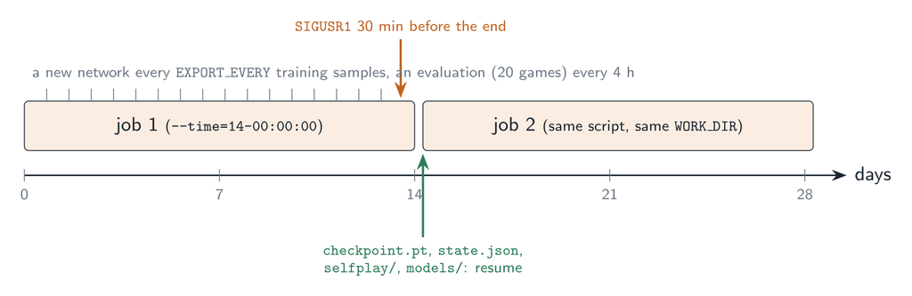

Figure 15: Two 2-week jobs make one month-long run.

### 6.6.1 The cluster

| resource | what there is | what the run uses |
| --- | --- | --- |
| GPU nodes | 5 nodes, 13 cards of 48 GB: 7 A40, 6 RTX 8000 | 3 cards (the per-user maximum) |
| CPU nodes | 18 nodes, 592 cores, 8 TB of RAM | nothing (see Section 6.7) |
| home (`/home/<user>`) | visible from every node | the work directory (~60 GB) |
| `/calcul` | 17 TB, distributed | nothing |

The run lives in the home directory, `~/AlphaZeroLearn`: it must survive for a month and be reachable from whichever node the next job lands on, and its I/O is modest (about 1.2 GB of self-play rows a day, a 141 MB network per export, small reads by the trainer), so no fast scratch space is needed.

### 6.6.2 The image

`nnue/alphazero_learn.def` builds a *toolchain* image: CUDA 12.4 with cuDNN, g++-13 (the code is C++23), Boost, oneTBB, Google benchmark, CMake, Python 3 and torch 2.6.0 — whose wheel also contains libtorch, the C++ library the TorchScript backend links against. Unlike the other `.def` files it does **not** contain the Yolah sources: the job bind-mounts the repository and compiles `alphazero_learn` on the compute node, at the start of every job (about a minute). Two reasons: the CMake flags use `-march=native`, and a binary compiled on the machine that builds the image may use instructions the cluster CPUs lack (a crash with `SIGILL`); and changing the code then requires a `git pull`, not a new image. The build is cached in `WORK_DIR/build/<hash of the CPU model>`.

```bash
# once, on a machine where you are root (or with --fakeroot)
cd nnue && sudo singularity build alphazero_learn.sif alphazero_learn.def
# copy the .sif to the cluster, clone the repo there, copy the initial network
scp alphazero_learn.sif cluster:AlphaZeroLearn/
# on the cluster: git clone the repository into ~/Yolah, then
scp cnn_resnet_256x30_value_policy.pt cluster:Yolah/nnue/
```

The network is stored in the repository with Git LFS, which the cluster does not have: a clone there holds a 134-byte *pointer* in place of the 144 MB file, hence the `scp`. Both the job script and the trainer check for a pointer and stop with an explicit message rather than a cryptic `torch.load` error.

### 6.6.3 The job script

`nnue/alphazero_learn.sh` asks for **3 GPUs, 32 CPUs, 128 GB of RAM and 14 days** (Figure 16). Its header lists every tunable as an environment variable (`SELFPLAY_GAMES`, `LR`, `REUSE`, `EVAL_HOURS`, …); the paths (`YOLAH_DIR`, default `~/Yolah`; `SIF` and `WORK_DIR`, default under `~/AlphaZeroLearn`) and the shell functions shared with the next script live in `nnue/alphazero_common.sh`. It does two things: compile, then run `alphazero_learn.py` in the container. The first lines of its output name the GPUs it got (`nvidia-smi`).

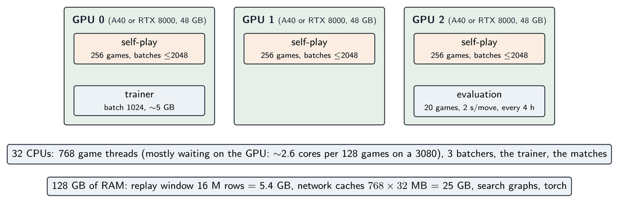

Figure 16: How the job uses the node.

### 6.6.4 Splitting the GPUs over several nodes

The GPU nodes have two or three cards each, and a job asking for three GPUs on *one* node may wait a long time for one to be completely free. Because the loop only communicates through files in the shared home, the three GPUs do not have to be on the same node (Figure 17):

```bash
sbatch --gres=gpu:1 alphazero_learn.sh     # trainer + self-play + evaluations
sbatch alphazero_selfplay.sh               # one more self-play GPU, any node
sbatch alphazero_selfplay.sh               # and another
```

`nnue/alphazero_selfplay.sh` (1 GPU, 12 CPUs, 48 GB) runs only `alphazero_learn selfplay` on the same work directory. It waits until the main job has published a network, compiles for its own node (a lock serialises two jobs compiling for the same CPU model), hot-swaps every new network like the main job’s own self-play, and writes its games under a name that carries its host and job id — two jobs on one node both see their GPU as number 0, so the GPU number alone would not be unique. It stops by itself when no new network has appeared for 6 hours (`--max-stale-hours`): when the main job is over, it does not keep playing with an outdated network until its own time limit.

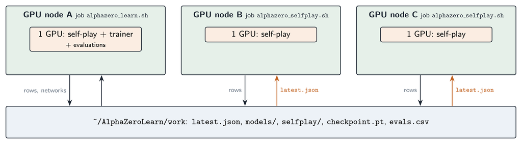

Figure 17: Three 1-GPU jobs on three nodes, one run: every exchange is a file in the shared home directory.

### 6.6.5 Stopping cleanly

Stopping cleanly matters, because the last minutes of a job are the ones that would otherwise be lost:

- `#SBATCH --signal=B:USR1@1800` makes SLURM send `SIGUSR1` to the batch script 30 minutes before the time limit. The script’s `trap` forwards it as `SIGTERM` to the trainer, which stops at its next step, writes `checkpoint.pt`, sends `SIGTERM` to the self-play processes — they finish their current searches, write the finished games and exit — and stops the evaluation (which stays in `pending_evals` and is played first by the next job).
- In case the signal is lost, the script also reads the job’s remaining time (`squeue -o %L`) and passes `--max-hours` = that minus 20 minutes.
- The job script starts the container with `exec`, so the signal reaches Singularity itself, which forwards it into the container. Sending it to a bash subshell around Singularity would kill the subshell and leave the trainer and its self-play processes running as orphans. This was caught in testing.
- The trainer refuses to start if it cannot see a GPU. The usual cause is a container whose CUDA driver is not bound, and without the check self-play would fall back to the CPU and run about 50 times slower for two weeks. The self-play log’s second line names the backend and device actually used.
- Even a `kill -9` loses at most the work since the last export and the games in progress: self-play rows are on disk as soon as a file is complete.

To continue, submit **the same script with the same `WORK_DIR`**:

```bash
sbatch alphazero_learn.sh          # days 0-14
sbatch alphazero_learn.sh          # days 14-28: resumes from WORK_DIR
```

`RESUBMIT=1` makes the job resubmit itself after a clean stop (never after a crash, to avoid a resubmission loop).

### 6.6.6 What to watch

| file | what it tells you |
| --- | --- |
| `alphazero_learn_<job>.out` | the trainer’s log: losses every 2 min, exports, evaluations |
| `WORK_DIR/evals.csv` | one line per match: W/D/L, score, Elo difference, chained Elo |
| `WORK_DIR/train_log.csv` | step, rows, window, value loss, policy loss, KL, samples/s |
| `WORK_DIR/logs/selfplay_gpu<k>.log` | games/s, rows/s, evals/s, game length, colour balance (every 5 min) |
| `WORK_DIR/logs/eval.log` | every evaluation game, move by move result |
| `WORK_DIR/evals/*.json` | the complete record of every evaluation game |

Healthy signs: the value loss slowly decreasing, the KL staying small (the network keeps up with the search, typically a few tenths), the chained Elo climbing, the colour balance of self-play evolving slowly. Warning signs: a value loss that collapses towards 0 (the window is too small: it memorises), a KL that keeps growing (the learning rate is too small or the reuse too low), games getting systematically shorter (a degenerate strategy — look at `evals/*.json`).

## 6.7 Sizing for the cluster

### 6.7.1 What was measured

On the development machine (one RTX 3080, 10 GB, WSL2), with the initial network and 800/200 simulations:

| quantity | value |
| --- | --- |
| self-play, 128 games | ~8 500 evaluations/s, GPU at 95 % |
| self-play, 256 games | no better (the GPU is saturated) |
| self-play, 2 processes × 64 games | ~6 000 evaluations/s in total (worse) |
| games | ~0.51 games/s — ~44 000 per day, 55 plies on average |
| training rows (full searches only) | ~6.9 rows/s — ~600 000 per day |
| evaluations per row | ~1 200 |
| trainer, batch 1024 | ~3 400 samples/s, 4.9 GB (alone on the GPU) |
| colour balance | black wins 61 %, white 8 %, draws 31 % |

The last line is a property of Yolah, not of the loop; it is explained just below.

### 6.7.2 Why black wins so often

On the cluster the three self-play GPUs report the same balance: black wins ~57 %, white ~8 %, the rest are draws. That is not a weakness of the network nor a bug in the counting: it follows from how Yolah is scored.

Every move scores one point for the player who makes it, and black moves first. The final margin, black minus white, is therefore the sum of two parts:

- **a structural bonus for black of 0 or +1.** As long as nobody has to pass, black has made either as many moves as white (the game ended after a white move: a draw) or one more (it ended after a black move: black wins by one). On average, black gets half a point for free.
- **the passes.** A player who is blocked while the other can still move loses one point per pass. It is the only way white can win.

And the margins are tiny (Figure 18): in 84 % of the games the final margin is between −2 and +2. With margins that small, black’s free half point decides a large share of the games: it turns would-be draws into black wins, and small white wins into draws.

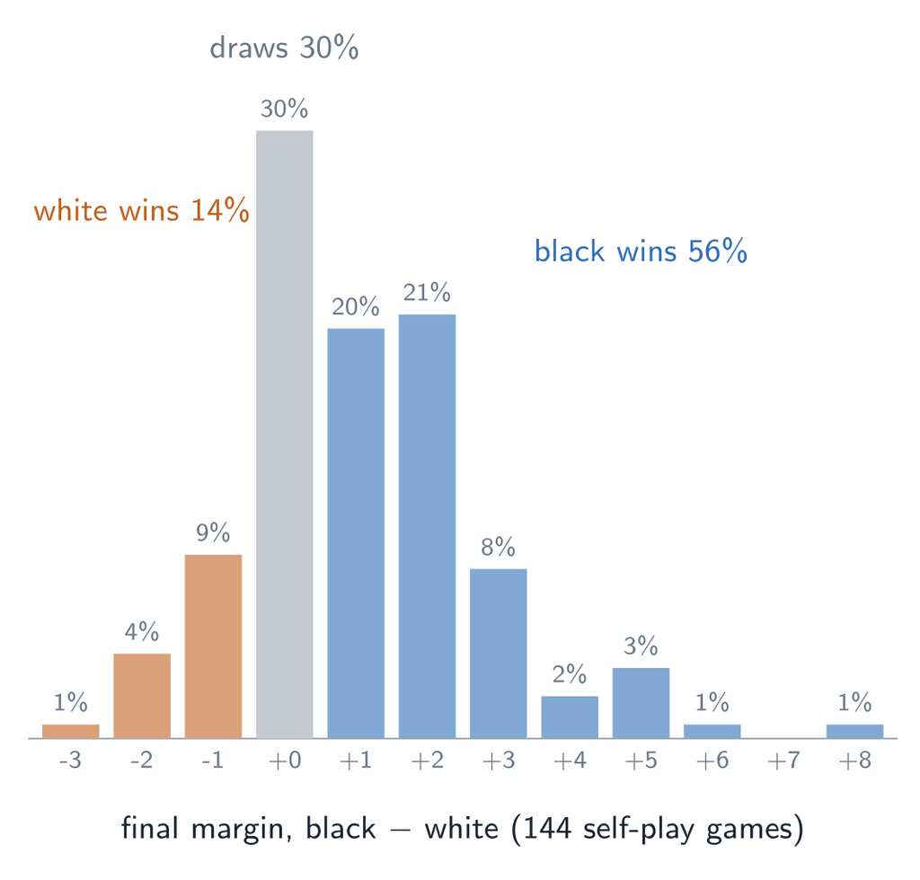

Figure 18: Distribution of the final margin over 144 self-play games observed from the initial position (the margin is read off the future ownership map described in the section on the auxiliary heads).

The same balance appears in games played by entirely different engines. The 480 000 games of the supervised training set (minimax and NNUE players) start with 0 to 9 random plies, and splitting them by that number is instructive:

| random plies at the start | black wins | draws | white wins |
| --- | --- | --- | --- |
| **0 (the real initial position)** | **60.6 %** | **32.0 %** | **7.5 %** |
| 2, 4, 6, 8 | 52–61 % | 26–34 % | 13–14 % |
| 1, 3, 5, 7, 9 | 34–43 % | 29–38 % | 19–38 % |

From the initial position, the minimax engines show exactly the imbalance of AlphaZero’s self-play. Over the whole set white wins 20 %, but only because of the random openings: after an *odd* number of random plies, black has played one random — hence usually bad — move more than white, and the more random plies, the better white does. A comparison of colour balances is therefore only meaningful between games that start from the same kind of position. (The evaluation matches play each opening with both colours, from a book of balanced openings, Section 6.5.3.)

Consequences for the learning loop:

- none for the value head: the network sees whose turn it is (plane 3 of the input) and learns that the same board is worth more to black;
- none for the evaluation: every opening is played once with each colour;
- but $z$ (win / draw / loss) says little in such a game: with a third of draws and most wins by one or two points, the *exact* margin carries much more information than its sign — which is what the score-margin head of Section 6.9 learns.

A game designer who wanted balanced results would give white a compensation (half a point, like komi in Go); that is a change of rules, not of the engine, and has no effect on learning.

### 6.7.3 From the measurements to the settings

Self-play is the bottleneck, as in every AlphaZero-like system; the rest is arithmetic.

**Data rate.** With ~1 200 evaluations per row, a GPU doing $E$ evaluations per second produces $E/1200$ rows/s, i.e. $72\,E$ rows per day. How fast are the cluster’s cards? The network is convolutions on $8\times8$ boards with 256 channels: compute-bound, in fp16 with fp32 accumulation. The A40 (Ampere, ~150 TFLOPS of fp16 tensor work) and the RTX 8000 (Turing, ~130 TFLOPS) do that at full rate, whereas a GeForce RTX 3080 does it at half its nominal rate (~60 TFLOPS). From the specifications, then, a cluster card should be 2 to 2.5 times a 3080. Taking a conservative 2×: $3 \times 17\,000$ evaluations/s $\approx$ 3.6 M rows per day, **~100 M rows in 28 days** ($\approx$ 7 M games). Each self-play log prints `evals/s`, so the real number is known after five minutes; everything below scales linearly with it.

**Games per GPU: 256.** Enough to saturate a GPU 2–2.5 times faster than the 3080, which saturates at 128. More games cost only RAM and threads, both plentiful. One process per GPU (measured above: two per GPU is worse).

**Replay window: $N_0 = 250\,000$, cap 16 M.** KataGo’s own $N_0$. At 3.6 M rows/day the first 250 000 rows arrive within two hours, and after a month $W(N) \approx 12$ M rows (Figure 11) — 4 GB, well under the 16 M cap (5.4 GB) chosen to leave headroom if the GPUs are faster than assumed.

**Export every 524 288 samples.** At $r = 4$ that is a new network every 131 072 rows, about every 50 minutes at 3.6 M rows/day — frequent enough for self-play to play with a fresh network, rare enough that the export (a trace and two 141 MB files) is negligible.

**Evaluation every 4 hours, 20 games.** Six per day, 37 minutes each on the last GPU: about 15 % of that GPU’s self-play. About 170 evaluations over the month, i.e. a 24 GB history of evaluated networks.

**RAM and CPUs.** 768 games × 32 MB of network cache = 25 GB, the replay buffer 5.4 GB, plus the search graphs and torch: well under the 128 GB requested. The game threads spend most of their time waiting for the GPU: on the 3080, 128 games used ~2.6 cores. The CPU work (descents, backups, encoding the positions) is proportional to the number of *evaluations*, not to the number of games, so a GPU twice as fast needs about twice that: $3 \times 2 \times 2.6 \approx 16$ cores for self-play, plus the trainer’s data pipeline and the 4 search threads of each evaluation player. 32 CPUs leave a comfortable margin, and asking for less than a whole node makes the job easier to schedule.

**Heterogeneous GPUs.** A job may get A40s, RTX 8000s or, in principle, a mix. Self-play does not care. The trainer switches between bf16 and fp16 (see the optimiser notes above). The evaluation compares two networks on the *same* GPU, so the match is fair whatever the card; but “2 s per move” buys more simulations on an A40 than on an RTX 8000, so the absolute level of play of two evaluations made in different jobs may differ slightly — another reason to read the Elo trend rather than single values. To pin a card type, use the cluster’s gres type (`--gres=gpu:a40:3`; `sinfo -o "%N %G"` lists them).

**Why not the CPU nodes?** Self-play could in principle run on the 592 CPU cores with the pure C++ backend (`nn::ResNetCPU`). Measured on the development machine it evaluates 130–160 positions/s on about ten cores; a 33-core node would do perhaps 450/s, and all 18 nodes ~8 000/s — about half of one A40, for a gain of roughly 15 % on three GPUs. That would not pay for the complexity (a second network format to export at every update, jobs spread over 18 nodes) nor for occupying a shared resource. The GPUs are where the network is fast.

**Disk.** ~34 GB of self-play rows for 100 M rows, ~24 GB of evaluated networks: plan for ~60 GB in `WORK_DIR`.

## 6.8 Parameters of the learning loop

All are command-line options of `alphazero_learn.py`; the `.sh` exposes the important ones as environment variables and sets the cluster values:

| option | default | cluster (`.sh`) | meaning |
| --- | --- | --- | --- |
| `--selfplay-games` | 128 | 256 | concurrent games per self-play process (one per GPU) |
| `--selfplay-set 'k=v'` |  | `nn cache=32` | override a key of the self-play config |
| `--batch-size` | 1024 | 1024 | training batch |
| `--lr` | 1e-4 | 1e-4 | Adam learning rate (after warm-up) |
| `--warmup-steps` | 500 | 500 | linear warm-up |
| `--weight-decay` | 1e-4 | 1e-4 | L2 |
| `--ema-decay` | 0.995 | 0.995 | weight averaging for export; 0 = raw weights |
| `--reuse` | 4 | 4 | training samples per generated row |
| `--q-weight` | 0 | `Q_WEIGHT` | value target $(1-w)\,z + w\,q$ (Section 6.4.4); 0 = the result alone |
| `--min-rows` | 100 000 | 250 000 | $N_0$: rows before training starts, window base |
| `--max-window` | 4 M | 16 M | ring buffer capacity |
| `--export-every` | 131 072 | 524 288 | training samples between two networks |
| `--eval-hours` | 4 | 4 | time between two evaluations |
| `--eval-every` | 0 |  | evaluate every $K$ exports instead (0 = use `--eval-hours`) |
| `--eval-games` / `--eval-seconds` | 20 / 2 | 20 / 2 | the match |
| `--eval-opening-plies` | 4 | 4 | random plies before each pair of games, without a book |
| `--eval-book` | none | `EVAL_BOOK` = `config/openings/balanced.txt` | balanced openings (Section 6.5.3) |
| `--eval-opponents` | previous | previous | `previous`, `initial`, `lag:K`, comma separated |
| `--train-gpu` / `--eval-gpu` | 0 / −1 |  | trainer on the first GPU, matches on the last |
| `--keep-all` | off |  | keep every exported network |
| `--max-hours` | 0 | time limit − 20 min | stop cleanly after this long |
| `--no-selfplay` | off |  | train only (self-play running elsewhere) |
| `--allow-cpu` | off |  | run without CUDA (tests only) |
| `--amp` | auto |  | trainer precision: `auto` (bf16 on Ampere+, else fp16), `bf16`, `fp16` |
| `--aux` | off | `AUX=1` | train the auxiliary heads (Section 6.9) |
| `--own-weight` | 1.5 |  | weight of the ownership loss |
| `--score-weight` / `--score-cdf-weight` | 0.02 / 0.02 |  | weights of the margin losses |
| `--aux-ramp-steps` | 2 000 |  | linear ramp of the three auxiliary weights from 0 |

## 6.9 KataGo’s auxiliary heads

Everything so far trains the network on two targets per position: one scalar $z$ and one distribution $\pi$. KataGo’s most effective idea on top of AlphaZero is to ask the network for **more predictions than the search needs** — extra *heads* that exist only during training (Figure 19). This section explains what they are and why they help, how the two most useful ones — ownership and score — translate to Yolah, and how they are implemented here, as an **option** (`--aux`): without it, everything described in the previous sections runs unchanged, file formats included.

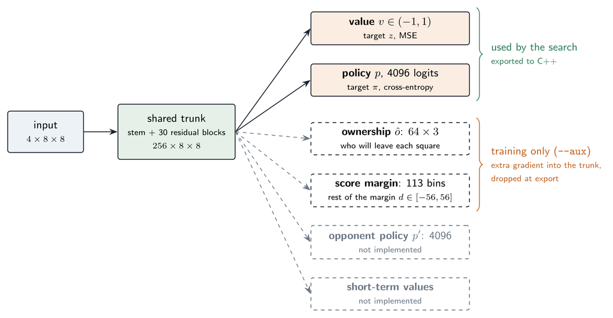

Figure 19: The two heads the search uses, and the auxiliary heads that exist only to train the trunk. Only ownership and score margin are implemented.

### 6.9.1 Why predicting more helps

Think of the information a game gives to the value head: the result, win, draw or loss — $\log_2 3 \approx 1.6$ bits — shared by the 55 positions of the game. A position early in the game gets the credit or the blame for 50 later moves it had nothing to do with. The value target is extremely *noisy*, and that noise is what makes value learning the slow part of AlphaZero. In Yolah it is worse than usual: with a third of draws and most wins by one or two points (Section 6.7.2), the result hides almost everything that happened.

An auxiliary target is any quantity that is (a) known for free at the end of the game, (b) much richer than $z$, and (c) related to what the network must understand. Its head is small — a 1×1 convolution, a couple of linear layers on top of the shared trunk — and it is thrown away at export time. What remains is its **gradient into the trunk**: the trunk must now compute features that also predict the auxiliary target, and features that explain *where* and *by how much* a game is won are exactly the features that make the value head accurate. It is regularisation by multi-task learning. In the KataGo paper’s ablations, removing these targets slows learning down markedly, most of all early in a run.

Two caveats before expecting miracles: our network starts from a supervised model that already plays well, so the gain will be smaller than for KataGo, which started from scratch; and only evaluation matches can tell how much.

### 6.9.2 Ownership in Yolah

In Go, KataGo predicts for each of the 361 points who owns it at the end of the game — 361 targets per position instead of one. Yolah has an exact equivalent, and a particularly clean one. Every move leaves a hole on the square the piece came from and scores one point for its player (`Yolah::play`). So at the end of a game **each square is either a hole left by black, a hole left by white, or neither**, and the number of holes a player left *is* their score (Figure 20, a real game of the initial network: 29–26). The ownership map is the final score decomposed square by square.

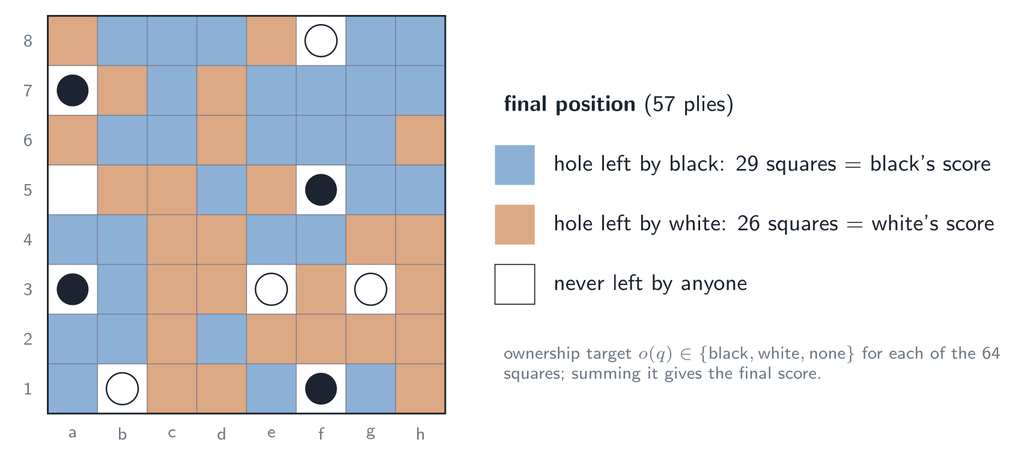

Figure 20: Final ownership in a real game: every square is labelled by the player who left it. Counting the labels gives the final score.

Yolah is a cousin of the Game of the Amazons, and ownership means the same thing in both: as the game goes on, the board splits into regions sealed off by holes, and the squares of a region where I am alone are going to be “mine”. The ownership head has to see that partition coming long before it is fixed — which is precisely the strategic understanding the value head needs.

**The target must be predictable from the position.** The network’s input shows the holes, but not *who* made them. The final label of a square that is already a hole is therefore history, not something the position determines: asking the network to predict it would be asking it to guess, i.e. noise. So the target is the **future ownership**, relative to the side to move:

$$o_t(q) =
\begin{cases}
\text{no target} & \text{if } q \text{ is already a hole at } t,\\
\text{mine} & \text{if the side to move at } t \text{ will leave } q,\\
\text{opponent's} & \text{if the opponent will leave } q,\\
\text{nobody's} & \text{otherwise (it stays free, or a piece ends the game there).}
\end{cases}$$

Figure 21 shows it on the same game, after 24 plies.

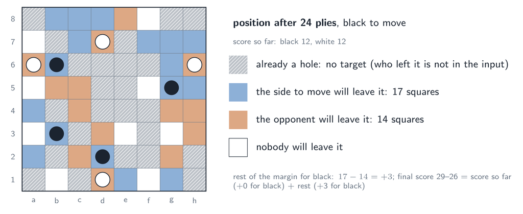

Figure 21: The future ownership target of a mid-game position of the same game. Holes already made carry no target; the rest of the board is labelled by who will leave each square. The counts give the rest of the score: 12 + 17 = 29 for black, 12 + 14 = 26 for white.

Being relative to the side to move (“mine / the opponent’s” rather than “black / white”) makes the target independent of the colour, like the value.

### 6.9.3 The rest of the margin

Summing the future ownership map gives the number of moves each side will still make, hence the **rest of the score margin** for the side to move:

$$d_t = \#\{q : o_t(q) = \text{mine}\} - \#\{q : o_t(q) = \text{opponent's}\}
\;\in [-56, 56]$$

(64 squares minus 8 pieces). The final margin is the margin so far plus $d_t$ (29–26 = (12–12) + (17–14) in the figure). Why predict the *rest* rather than the final margin, as KataGo does? Because the score so far is not in the input either: it can be guessed from the number of holes and whose turn it is — but not when there have been passes. The rest of the margin, on the other hand, is entirely determined by the position and the play to come.

The score head predicts the whole **distribution** of $d_t$ — 113 logits, one per possible value — rather than a single number: whether a position is a sure +1 or a coin toss between −2 and +4 is exactly the kind of information the value lacks. It needs no extra data: $d_t$ is read off the ownership map.

### 6.9.4 The heads

`AuxNet` (`nnue/alphazero_aux.py`) is `Net` — the same trunk, the same value and policy heads, the same parameter names — plus two heads on the trunk’s output $h \in \mathbb{R}^{C\times 8\times 8}$:

- **ownership**: a 1×1 convolution $C \to 3$, i.e. three logits per square, one softmax per square over (nobody, mine, opponent’s) — a per-square classification;
- **score**: global pooling of $h$ over the 64 squares, mean and max ($2C = 512$ numbers), then a linear layer to 256, a ReLU, and a linear layer to the 113 logits. Pooling rather than flattening, because the margin is a property of the whole board.

```python
def forward_all(self, x):
    h = self.trunk(x)                                     # (B, C, 8, 8)
    v, p = self.heads(h)                                  # the two heads of Net
    own = self.own_conv(h).flatten(2)                     # (B, 3, 64)
    pooled = torch.cat([h.mean(dim=(2, 3)), h.amax(dim=(2, 3))], dim=1)
    score = self.score_fc2(torch.relu(self.score_fc1(pooled)))   # (B, 113)
    return v, p, own, score
```

`forward()` still returns `(v, p)`, so an `AuxNet` can be used wherever a `Net` is.

### 6.9.5 The losses

With $\hat o_q$ the predicted distribution of square $q$, $\hat P$ the predicted distribution of the margin and $\hat F$ its cumulative distribution:

$$\mathcal{L}_{\text{own}} = -\frac{1}{64}\sum_{q\,:\,o_t(q)\,\neq\,\text{no target}} \log \hat o_q\big(o_t(q)\big),
\qquad
\mathcal{L}_{\text{pdf}} = -\log \hat P(d_t),
\qquad
\mathcal{L}_{\text{cdf}} = \sum_{x=-56}^{56} \big(\hat F(x) - \mathbb{1}[x \ge d_t]\big)^2 .$$

- The ownership loss is a cross-entropy per square, averaged over the whole board (squares without target count for 0). It is KataGo’s $1/b^2$ times the sum over the points.
- The pdf term is an ordinary cross-entropy against the true margin. On its own it treats every wrong value alike; the cdf term adds the notion of distance: predicting +11 for a true +12 moves the cumulative distribution by one step, predicting −30 by many (it is the squared-error form of the earth mover’s distance between the two distributions).

The total loss adds them to the AlphaZero loss with small weights, because the auxiliary heads must shape the trunk without dominating the two heads that matter:

$$\mathcal{L} = \mathcal{L}_v + \mathcal{L}_p
+ \rho(t)\,\big(w_{\text{own}}\,\mathcal{L}_{\text{own}}
+ w_{\text{pdf}}\,\mathcal{L}_{\text{pdf}}
+ w_{\text{cdf}}\,\mathcal{L}_{\text{cdf}}\big),
\qquad w_{\text{own}} = 1.5,\ w_{\text{pdf}} = w_{\text{cdf}} = 0.02 ,$$

KataGo’s weights. $\rho(t)$ is a **ramp** from 0 to 1 over the first 2 000 steps (`--aux-ramp-steps`): the new heads start random, their first gradients are large and meaningless, and they must not shake a trunk that already plays well. Rows without auxiliary targets (see below) are masked out of the three terms.

The code, in `aux_losses`:

```python
ce = F.cross_entropy(own_logits, own, ignore_index=OWN_PAST, reduction="none")  # (n, 64)
own_loss = ce.sum(1).mean() / 64.0
target = margin_from_ownership(own) + MAX_MARGIN                 # index of d_t in 0..112
logp = F.log_softmax(score_logits, dim=1)
pdf_loss = F.nll_loss(logp, target)
cdf_pred = logp.exp().cumsum(1)
cdf_true = (torch.arange(SCORE_BINS)[None, :] >= target[:, None]).float()
cdf_loss = ((cdf_pred - cdf_true) ** 2).sum(1).mean()
```

The 8 symmetries apply unchanged: the ownership map is a plane like the input planes and goes through the same `gather`; the margin, a count, is invariant.

### 6.9.6 Recording the targets

The target of a sample depends on the rest of its game, so it is computed when the game ends — like $z$. During the game, `run_selfplay` notes who leaves each square (`leaver[q]`); at the end, `with_ownership` turns that into the map of every recorded sample:

```cpp
for (int q = 0; q < 64; q++) {
    uint8_t code;
    if ((s.empty >> q) & 1)      code = OWN_PAST;      // already a hole: no target
    else if (leaver[q] == 0xFF)  code = OWN_NONE;      // nobody leaves it
    else                         code = leaver[q] == s.turn ? OWN_MINE : OWN_OPP;
    a.own[q / 4] |= static_cast<uint8_t>(code << (2 * (q % 4)));
}
```

A square that is not yet a hole at the sample and is left later can only have been left *after* the sample — once left, a square is a hole forever — so the map counts exactly the moves still to come.

Two bits per square, 16 bytes per row: the rows become `TrainingSampleAux` (352 bytes instead of 336), in files of **version 2**. On the Python side the map is unpacked on the GPU into the plane-cell order of the input (cell $c$ holds square $63-c$) so that it lines up with the planes and their symmetries.

The targets were checked against the rules on 8 570 rows, with and without the random symmetry: every square already a hole is exactly a square without target; no square holding one of my pieces is ever labelled “the opponent will leave it”, and vice versa; and on the 4 655 rows of early game (no pass possible yet), the result $z$ is the sign of margin so far + $d_t$ in 100 % of the cases.

### 6.9.7 Two variants, one code

The option is decided by the trainer alone, and everything else follows:

|  | without `--aux` (default) | with `--aux` (`AUX=1`) |
| --- | --- | --- |
| network trained | `Net` | `AuxNet` (`Net` + 2 heads) |
| network exported (`.pt`, `.ts`) | `Net` | `Net` — the heads are dropped |
| C++ side | unchanged | unchanged |
| `latest.json` | `{"step", "ts"}` | `{"step", "ts", "aux": true}` |
| self-play rows | version 1, 336 bytes | version 2, 352 bytes |
| logs | `train_log.csv` | `train_log.csv` + `train_log_aux.csv` |

- **Self-play follows `latest.json`**: the key `"aux"` switches the recording on or off at the next poll, in the main job and in the extra self-play jobs alike. No flag has to be kept in sync by hand.
- **The trainer reads both formats**: version-1 rows read by an `--aux` trainer have no target (every square “no target”, masked in the loss); version-2 rows read by a plain trainer simply lose their map.
- **A run can switch** from one job to the next, in either direction:

  ```bash
  sbatch --export=ALL,AUX=1 alphazero_learn.sh    # the next two weeks with the heads
  ```

  The shared parameters are kept; the heads start from scratch (or are dropped); the optimizer, whose state is per parameter, restarts with a new warm-up, and so does the weight average. The log says so (`variant switch: with auxiliary heads from step …`). This was tested in both directions on a single run.
- **The export is the plain network**: `export_model` rebuilds a `Net` from the non-auxiliary parameters, so the `.pt` and `.ts` files are byte-for-byte the same kind as without the option, and the traced module gives exactly the value and policy of `AuxNet` (checked: difference 0).

What to watch with `--aux`, in `train_log_aux.csv` (and every 2 minutes in the job’s log): the ownership loss and its accuracy (the fraction of squares whose future owner is predicted right), and the two margin losses. They should fall quickly in the first thousands of steps — the heads are learning — and then slowly. The two KataGo heads not implemented here, the opponent’s reply and the short-term values, would need rows paired with the next rows of the same game; the version header of the files leaves room for that.

# 7 Solving Yolah

Two questions come naturally once a program plays a game well. Could we compute *exact* values instead of estimating them — at least near the end of the game, as chess engines do with endgame tablebases built by retrograde analysis? And could the whole game be *solved*? This chapter works out what that would take for Yolah. Nothing in it is implemented yet; the numbers come from the measurements of the previous chapter and from the rules.

The vocabulary is Allis’s. A game is **ultra-weakly solved** when the result of perfect play from the initial position is known, **weakly solved** when a strategy achieving it is known too, and **strongly solved** when the value of every position is known. Checkers was weakly solved in 2007, after almost two decades of work; Othello (8×8) was weakly solved in 2023 — a draw.

## 7.1 What there is to compute

The quantity to compute is the one the score head of Section 6.9 predicts: the **rest of the margin** $V(s)$, the number of moves the side to move will still make minus the number the opponent will, under perfect play by both. Three properties of Yolah make it pleasant.

**It depends on the board alone.** The score so far does not matter: the final margin is the margin so far plus $V(s)$, and the margin so far is a constant that neither player can change any more. A position is therefore just the two sets of four pieces, the set of holes and the side to move.

**It obeys a simple recurrence.** A move scores one point for its player and hands the move to the opponent, whose rest of the margin counts against us; a player who cannot move passes and scores nothing:

$$V(s) =
\begin{cases}
\max_{m} \big(1 - V(s\cdot m)\big) & \text{if the side to move has moves,}\\
-V(\bar s) & \text{if only the opponent has moves } (\bar s: s \text{ with the other side to move}),\\
0 & \text{if nobody can move (the game is over).}
\end{cases}$$

**It also solves win / draw / loss.** From the initial position the margin so far is 0, so black wins, draws or loses according to the sign of $V(s_0)$. That this sign is also the value of the game played for win / draw / loss is not obvious — the two objectives could call for different moves — but it holds because the sign is monotone and minimax commutes with monotone functions: $\operatorname{sign}(\max(a, b)) = \max(\operatorname{sign} a, \operatorname{sign} b)$, and likewise for $\min$. Solving the margin game solves the result, and gives more: by how much.

**The game is acyclic and layered.** Every move adds a hole, and holes never disappear, so a game lasts at most 56 moves and the positions fall into layers by their number of holes: a move always goes from layer $k$ to layer $k+1$, and a pass stays in the layer but can happen at most once in a row. There are no cycles, no repetitions, no draws by repetition: the recurrence above is a plain backward induction.

## 7.2 Retrograde analysis, the textbook way

Retrograde analysis computes values from the end of the game backwards. For Yolah it would go layer by layer, from the full boards to the empty one:

1. Every position of the deepest layers is terminal (nobody can move): value 0.
2. For layer $k$, every value needed is either in layer $k+1$ (after a move) or in layer $k$ with the other side to move (after a pass, and that position is not itself a pass position). Compute them by the recurrence.
3. Store one byte per position ($V \in [-56, 56]$), and divide the work by 16 with the 8 symmetries of the board and the colour swap ($V(\text{black}, \text{white}, H, \text{black to move}) = V(\text{white}, \text{black}, H, \text{white to move})$ with the pieces’ colours exchanged).

Classic retrograde analysis walks *backwards* with **unmoves** rather than enumerating every position of a layer: from a solved position it generates its predecessors and updates them. In Yolah an unmove is easy to state: take a piece of the player who has just moved, standing on $b$; pick a hole $a$ on a queen line through $b$ whose squares in between are all free; move the piece back to $a$ and turn $a$ back into a free square. Unmoves visit only positions that can actually lead to the solved ones, which matters when most of the formal positions are unreachable.

**Why whole-board tables are out of reach.** In chess, an endgame table is small because few pieces are left. In Yolah the number of pieces never decreases — there are always eight — and what shrinks is the free space. But the holes that bound it can be *anywhere*: a table of all positions with only $F$ free squares has to choose which $8 + F$ squares are not holes, where the pieces are among them, and whose they are:

| free squares $F$ | positions (after the 16 symmetries) |
| --- | --- |
| 4 | $1.4 \times 10^{16}$ |
| 8 | $5.5 \times 10^{19}$ |
| 12 | $2.2 \times 10^{22}$ |

Even the table of the last few moves is larger than the biggest endgame databases ever built. A tablebase of *whole positions* is not the right tool.

## 7.3 Regions: what makes endgames small

What saves the day is that late positions fall apart (Figure 22). A queen move only crosses free squares, and consecutive squares on a line are neighbours (8-connectivity). So a piece can only ever reach the free squares of the **regions** — 8-connected groups of free squares — it touches, and two regions never merge: squares only ever stop being free. A late position is a **sum of independent sub-games**, one per region.

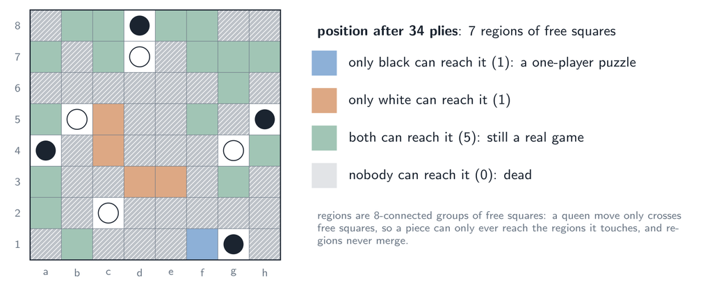

Figure 22: A mid-game position of the real game of Figure 20, split into its regions of free squares.

**A region only one player can reach** is a one-player puzzle: how many moves can my pieces make in it? The answer depends only on the region’s shape and on where my pieces stand along it, not on the rest of the board. Regions are small — a few to a dozen squares after the middle game — and their shapes recur, so their values can be **tabulated once**: the table is keyed by the region’s shape (normalised by translation and by the 8 symmetries) and the pieces’ positions in it. This is where retrograde analysis fits Yolah: not over whole boards, but over regions. When every region is single-owner, the game is over in all but name: black makes $M_{\text{black}}$ more moves, white $M_{\text{white}}$, in whatever order, and $V = \pm(M_{\text{black}} - M_{\text{white}})$.

**A region both players can reach** is still a real game, and a sum of such games is not simply the sum of their values: each turn, the player chooses *which* region to play in, and tempo matters — the theory of such sums is combinatorial game theory, which was built for exactly this kind of endgame in the Game of the Amazons, Yolah’s closest cousin. In practice an exact solver searches the sum, with the regions as its unit: a transposition table per region, the single-owner regions resolved by the table above, and bounds per region (a region of $n$ free squares cannot change the margin by more than $n$) for pruning.

## 7.4 An exact endgame solver

The practical form of all this is an exact solver for the last part of the game, and Figure 23 shows why it is within reach. The branching factor collapses as the holes accumulate: about 55 legal moves at the start, 22 on average, fewer than 10 after 35 holes. The whole game tree is around $10^{64}$ move sequences, but the last 20 plies weigh only about $10^{13}$ — and alpha-beta with good move ordering explores roughly the square root of that, $10^{6.5}$ positions.

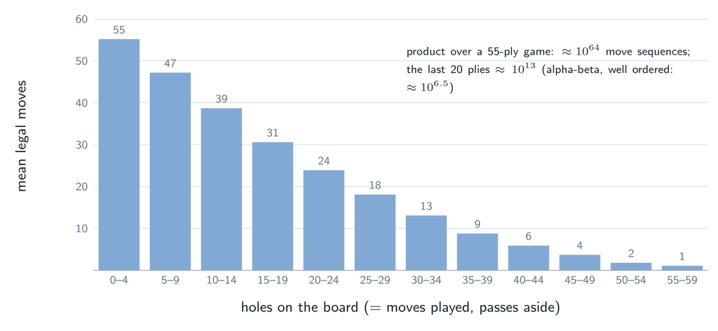

Figure 23: Mean number of legal moves as a function of the number of holes, measured on self-play positions.

The solver would combine standard techniques, each helped by a property of Yolah:

- **Null-window alpha-beta (MTD(f)).** A search with window $[\beta-1, \beta]$ only answers “is $V \ge \beta$?”, and prunes far more than a full-window search. Margins in Yolah are tiny (Figure 18: between −2 and +2 in 84 % of the games), so two or three such tests, starting from the network’s estimate, pin the exact value down.
- **Move ordering by the network.** Alpha-beta is only efficient if it tries the best move first; the policy head gives exactly that ordering.
- **A transposition table**, and the region decomposition above: tables for single-owner regions, per-region bounds, and search restricted to the contested regions.
- **Parallelism.** Independent sub-problems (the children of a node, the positions of a batch) spread over many cores — and the cluster has 592 CPU cores that self-play does not use.

Even without solving the whole game, such a solver pays off:

- **in the search**: below a number of free squares, the MCTS can replace the network’s estimate by the exact value — what chess engines do with their tablebases;
- **in training**: exact values are perfect targets for late positions, better than the noisy result $z$;
- **as a measuring stick**: the network’s value can be compared with the truth, ply by ply.

## 7.5 Can Yolah be solved?

**Strongly, no.** The positions are at most $\binom{64}{4}\binom{60}{4} \times 2^{56} \times 2 \approx 4.5 \times 10^{28}$ (the placements of the pieces, any subset of the other squares as holes, the side to move). Most are unreachable, but even a small fraction is far beyond any storage.

**Weakly: maybe, with a serious effort.** The orders of magnitude put Yolah in the same class as Othello:

|  | checkers | Othello 8×8 | Yolah |
| --- | --- | --- | --- |
| state space (upper bound) | $\sim 5 \times 10^{20}$ | $\sim 10^{28}$ | $\sim 4.5 \times 10^{28}$ |
| game length | ~50–100 plies | 60 plies | ≤ 56 moves, ~55 plies |
| weakly solved | 2007 | 2023 | — |

A weak solution does not need the whole state space: it needs a proof tree, in which the solving side plays one good move per position and only the opponent’s replies are all explored. What decides feasibility is how quickly that tree grows with the depth, and there Yolah has arguments on both sides. Against it: a very wide opening, with 55 legal moves at the start where Othello has a handful. For it: endgames that decompose into independent regions, tiny margins that make null-window searches very effective, and a network that already orders moves well.

**How to find out.** The honest answer comes from measurement, not from estimates:

1. write the exact endgame solver of Section 7.4 and check it against brute force on small positions;
2. solve self-play positions at 50, 45, 40, 35, … holes, recording the time and the number of nodes;
3. fit the growth per ply and extrapolate to the initial position.

If the cost grows by a factor $g$ per ply, going back $k$ plies costs $g^k$ more: the curve says within days whether a weak solution is a matter of weeks of cluster time, of years, or out of reach — and the solver is useful anyway.

**What the games already suggest.** The self-play games and the 480 000 supervised games agree (Section 6.7.2): from the initial position black wins about 60 % of the games, white about 8 %, and the final margin is almost always between −2 and +2. That makes it likely that the value of Yolah is small — a draw or a black win by one or two moves — but that is a statistic of imperfect play, not a proof. Deciding between “black wins” and “draw” is precisely what a weak solution would do.

# 8 Code map

| file | what lives there |
| --- | --- |
| `nnue/cnn_resnet_value_policy_chunked.py` | `Net`, `ResBlock`, `encode_cnn`, `ChunkedShuffleLoader`, the DDP trainer — the production script |
| `nnue/cnn_resnet_value_policy.py` | the same network with a stock `DataLoader` + `LeanDistributedSampler` |
| `nnue/resnet_export.py` | BatchNorm folding, the `.bin` writer, the TorchScript trace, the test vectors |
| `nnue/resnet.{h,cpp}` | `nn::ResNetCPU` — im2col + Eigen GEMM, OpenMP chunking, FTZ/DAZ |
| `nnue/resnet_torch.{h,cpp}` | `nn::ResNetTorch` — TorchScript on the GPU |
| `nnue/nn_evaluator.{h,cpp}` | the `Request`/`Result`/`Evaluator` interface, `encode_planes`, `action_index`, `make_evaluator` |
| `nnue/batched_evaluator.{h,cpp}` | `nn::BatchingEvaluator` — merges several search threads into one backend batch |
| `player/nn_cache.h` | `az::NNCache` — direct-mapped, lock-striped cache of network outputs |
| `player/alphazero_mcts.h` | `SearchParams`, `ChildStat`, `SearchResult`, `Search` — and the algorithm overview |
| `player/alphazero_mcts.cpp` | everything below: the node table, selection, backup, the worker loop, the root logic |
| `player/alphazero_mcts_player.{h,cpp}` | the `Player` wrapper and the JSON schema |
| `test/alphazero_mcts_check.cpp` | search / reuse self-checks and a head-to-head harness |
| `test/alphazero_check_main.cpp` | the `alphazero_check` CLI |
| `player/alphazero_selfplay.{h,cpp}` | `TrainingSample` (the row format), `run_selfplay` — many games on one batched network, hot swap |
| `test/alphazero_learn_main.cpp` | the `alphazero_learn` CLI: `selfplay` and `match` |
| `nnue/alphazero_learn.py` | the trainer and orchestrator: replay window, loss, symmetries, EMA, export, evaluations |
| `nnue/alphazero_aux.py` | optional auxiliary heads (`--aux`): future ownership and rest of the margin |
| `nnue/alphazero_learn.{def,sh}` | the cluster image and the SLURM job |
| `config/alphazero_mcts_selfplay_player.cfg` | the search settings of self-play |
| `config/alphazero_mcts_eval_player.cfg` | the search settings of the evaluation matches |

The functions worth knowing in `alphazero_mcts.cpp`:

| function | role |
| --- | --- |
| `select_child` | Section 5.2 — one PUCT argmax, plus forced playouts at the root |
| `utility_stdev_factor` | $\hat\sigma(s)$ from the node’s $W$ and $W^2$ |
| `fpu_value` | Section 5.3 — what an unvisited child is assumed to be worth |
| `priors_from_logits` | softmax over the legal moves, with `policy_temperature` |
| `expand` | build the edge vector, store `net_v`, publish `EXPANDED` |
| `backup` / `undo_pending` | negamax accumulation / virtual-loss rollback |
| `run_worker` | gather → evaluate → expand → back up, per thread |
| `get_or_create`, `lookup`, `collect`, `mark` | the node table and its garbage collection |
| `reuse`, `new_root`, `expand_root` | re-rooting between moves |
| `root_play_values` | policy target pruning and the LCB adjustment |
| `make_result` | the statistics, $\pi$, and the move choice |

# 9 Parameter reference

All of these are JSON keys of `AlphaZeroMCTSPlayer` (spaces, not underscores) and fields of `az::SearchParams` (underscores).

## 9.1 Budget and parallelism

| key | default | meaning |
| --- | --- | --- |
| `microseconds` | 1 000 000 | wall-clock budget; 0 = use the simulation budget only |
| `nb simulations` | 0 | simulation budget; 0 = time only |
| `nb threads` | 1 | search threads sharing the graph (`"hardware concurrency"` allowed) |
| `batch size` | backend hint | leaves gathered per thread per network call |
| `max collisions` | = batch size | cross-thread collisions that close a batch early |
| `nn cache` | 64 | MB of network-output cache; 0 disables it |

## 9.2 PUCT

| key | default | meaning |
| --- | --- | --- |
| `cpuct exploration` | 1.0 | $c_{\text{puct}}$ |
| `cpuct exploration log` | 0.45 | $c_{\log}$; 0 gives a constant coefficient |
| `cpuct exploration base` | 500 | $c_{\text{base}}$ |
| `cpuct utility stdev scale` | 0.85 | $\lambda$; 0 disables $\hat\sigma$ (plain AlphaZero) |
| `cpuct utility stdev prior` | 0.40 | $\sigma_0$ — see the calibration note in Section 5.2 |
| `cpuct utility stdev prior weight` | 2.0 | $w_p$, in visits |
| `policy temperature` | 1.0 | softmax temperature on the priors; >1 flattens |

## 9.3 First play urgency

| key | default | meaning |
| --- | --- | --- |
| `fpu reduction` | 0.2 | $r$ away from the root |
| `root fpu reduction` | 0.1 | $r$ at the root |
| `fpu loss prop` / `root fpu loss prop` | 0.0 | drag the estimate towards a loss |
| `fpu parent weight by visited policy` | true | blend $\bar q$ and $v_{\text{net}}$ by the visited mass |
| `fpu parent weight by visited policy pow` | 1.0 | the exponent $p$ |
| `fpu parent weight` | 0.0 | constant blend, used only when the above is false |

## 9.4 Graph and root

| key | default | meaning |
| --- | --- | --- |
| `graph search` | true | one node per position; false = a plain tree |
| `use lcb` | true | play the best lower confidence bound |
| `lcb stdevs` | 5.0 | $\lambda_{\text{lcb}}$ |
| `min visit prop for lcb` | 0.20 | eligibility threshold, as a fraction of the leader |
| `policy target pruning` | true | invert PUCT to undo the forced playouts |
| `reuse tree` | true | re-root instead of starting from scratch |

## 9.5 Self-play

| key | default | meaning |
| --- | --- | --- |
| `dirichlet alpha` / `dirichlet epsilon` | 0.3 / 0.0 | root noise; $\epsilon = 0$ disables it |
| `temperature` / `temperature cutoff` | 0.0 / 0 | sample the move $\propto \pi^{1/\tau}$ below the cutoff ply |
| `forced playouts k` | 0.0 | $k$; the paper uses 2.0, self-play only |
| `playout cap fast prob` | 0.0 | fraction of moves that get the small budget |
| `nb simulations fast` | 0 | that small budget |

# 10 Measurements

All figures below: `ResNetCPU`, 256×30 weights, one search thread, WSL2 on a desktop CPU. Reproduce with

```bash
./alphazero_check --no-bench --sims 3200 --set 'graph search=false'
```

## 10.1 What graph search actually buys

Four positions, 3 200 simulations each:

| position |  | graph | tree |
| --- | --- | --- | --- |
| 0 (ply 0) | network calls | 3 195 | 2 552 + 646 cache hits |
|  | distinct positions | **3 195** | 2 552 |
|  | sims/s | 156 | 181 |
| 1 (ply 17) | network calls | 3 141 | 2 632 + 515 cache hits |
|  | distinct positions | **3 141** | 2 632 |
|  | sims/s | 159 | 175 |
| 2 (ply 19) | network calls | 3 175 | 2 947 + 231 cache hits |
|  | distinct positions | **3 175** | 2 947 |
|  | sims/s | 156 | 162 |
| 3 (ply 10) | network calls | 3 195 | 2 630 + 570 cache hits |
|  | distinct positions | **3 195** | 2 630 |
|  | sims/s | 155 | 178 |

Read this carefully, because the naive reading is backwards. Graph search is **not** a speedup — it is 5–15 % *slower* per simulation. What it changes is what a simulation buys.

In tree mode, 7–20 % of the leaves are transpositions. The search allocates a duplicate node for a position it has already evaluated, the network cache serves the value for free, and the simulation backs that value up along its own path. Those are cheap and they are genuine MCTS updates — the path they refresh is a real one — they are simply *redundant*: no new information entered the search. In graph mode the descent links to the existing node and *keeps going*, ending at a position nobody has evaluated, which costs a real network call.

So the trade is: cheap redundant simulations against fewer, more informative ones. Which of those wins games is not something an eval counter can answer.

**ImportantThis is not yet a strength measurement**

More distinct positions per second is a proxy, not a result. The question “does graph search win games” needs a head-to-head:

```bash
./alphazero_check --games 200 --time 1000000 --opponent <tree-mode.cfg>
```

The default is `graph search: true` on the strength of the proxy and of the statistic pooling, not on a measured Elo gain. Nothing in this document should be read as one. The flag exists so the decision can be re-tested cheaply.

## 10.2 Node allocation

Children are now created lazily, one per descent, instead of eagerly at expansion. At 400 simulations the eager version allocated **20 335** node objects; the lazy one allocates **396** — one per position actually reached. The unreached children cost a 16-byte `Edge` instead of a 56-byte `Node` with its own vector. This one is unambiguous: fewer allocations, less memory, better locality, and it is what makes a node table cheap enough to maintain.

## 10.3 What LCB and pruning change

At 400 simulations, position 2 (ply 19) with the raw visit counts:

```
  f2:d2  N: 194  Q: +0.639  lcb: +0.479
  f2:e3  N:  87  Q: +0.759  lcb: +0.533   ← played
```

The most-visited move is not the one with the best lower bound, and LCB plays the second. That is the intended behaviour, but at 400 simulations with $\lambda_{\text{lcb}} = 5$ it is an aggressive override — the eligibility threshold (87 ≥ 0.2 × 194) is doing a lot of work. Worth re-checking at the budgets the engine will actually play at.

Policy target pruning is similarly consequential: at position 0 it drives several children with a dozen visits each to $\pi = 0$, because their priors are so small that PUCT would never have visited them — they were reached through FPU, not through their policy. That is exactly what the mechanism is for, but it makes $\pi$ markedly peakier than the visit distribution, and it should be eyed before it is trained on.

# 11 References

- Silver et al., *Mastering the game of Go without human knowledge*, Nature 2017 — AlphaGo Zero: PUCT, Dirichlet noise, the two-headed network.
- Silver et al., *A General Reinforcement Learning Algorithm that Masters Chess, Shogi and Go through Self-Play*, 2018 — AlphaZero, and the $c_{\text{init}} + \log((N+c_{\text{base}}+1)/c_{\text{base}})$ coefficient.
- D. J. Wu, *Accelerating Self-Play Learning in Go*, arXiv:1902.10565, 2019 — the KataGo paper: playout cap randomization, forced playouts, policy target pruning.
- KataGo source, `cpp/search/` — `searchexplorehelpers.cpp` for the selection formula, `getFpuValueForChildrenAssumeVisited` for FPU and $\hat\sigma$, `searchresults.cpp` for the play-selection values and LCB, `searchhelpers.cpp` for `getSelfUtilityLCBAndRadius`, `searchparams.cpp` for the defaults quoted here.
- Leela Chess Zero — the FPU-reduction formulation this and KataGo share.

# 12 Annotated source

Every file the document describes, in full, generated from the working tree by `doc/make_appendix.py`. Each one carries an orientation note, a table of the symbols it defines, and its complete source with line numbers — so the sections above can point at `alphazero_mcts.cpp:212` and mean it.

The running commentary lives in the sources themselves rather than being duplicated here; what the tables add is the one-line answer to “what is this for” for every symbol, which a comment sitting next to a definition cannot give you at a glance.

## 12.1 The search

These five files are the search proper. They depend on `game.h`, `misc.h`, `zobrist.h` and the `nn::Evaluator` interface of the next part, and on nothing else.

### 12.1.1 `player/alphazero_mcts.h`

*317 lines.*

The public surface: the parameter block, what a search reports, and the class. The header comment is the algorithm overview — the same one Section 5.2 through Section 5.8 expand on.

`SearchParams` is a plain aggregate with the KataGo defaults baked in, so `az::SearchParams{}` is a usable configuration once a budget is set. Everything private is forward-declared: `Node`, `Edge`, `PathStep` and `Worker` are defined in the `.cpp`, so nothing that includes this header sees the graph representation.

| symbol | role |
| --- | --- |
| `SearchParams` | every knob, grouped: budget, parallelism, PUCT, FPU, graph, root, self-play |
| `ChildStat` | one root move as reported: move, prior, raw edge visits, `q`, `q2`, play value, LCB |
| `SearchResult` | the move, the root value, the counters, `full_search`, the children and $\pi$ |
| `SearchResult::to_string` | the one-line-plus-children summary printed by `"verbose": true` |
| `Search` | the search object: owns the node table, the network cache and the parameters |
| `Search::search` | run one search from a position and pick a move |
| `Search::reset` | drop the graph (new game); the network cache survives |
| `Search::clear_cache` | drop the cached network outputs (after new weights) |
| `Search::params` | read/write access to the live parameters |
| `Search::Shard` | one stripe of the node table: a mutex and a `hash → Node*` map |

```cpp
#ifndef ALPHAZERO_MCTS_H
#define ALPHAZERO_MCTS_H
// alphazero_mcts.h — AlphaZero-style Monte-Carlo tree search for Yolah, with
// the refinements KataGo added on top of it.
//
// Inspired by MCTS_mem_player.h (same pool-allocated storage, same lock-free
// multi-threading style) but the leaf is evaluated by the two-headed ResNet
// instead of a random playout, and children are selected with PUCT, in the
// KataGo formulation (cpp/search/searchexplorehelpers.cpp):
//
//     a* = argmax_a  Q(s,a) + c(s) · P(s,a) · √(W(s) + 0.01) / (1 + W(s,a))
//     c(s) = [cpuct + cpuct_log · log((W(s) + cpuct_base) / cpuct_base)] · σ̂(s)
//     σ̂(s) = 1 + stdev_scale · (stdev(s) / stdev_prior − 1)
//
// W(s) = Σ_a W(s,a) is the total weight of the *edges* leaving s (one per
// visit, plus one per in-flight virtual loss) and stdev(s) is the running
// standard deviation of the values backed up through s, blended with a prior.
// The σ̂ factor explores more where the children disagree and less where the
// node's value has settled. AlphaZero is the special case
// cpuct_log = stdev_scale = 0.
//
// GRAPH SEARCH ─────────────────────────────────────────────────────────────
// The search space is a DAG, not a tree. Every Yolah move turns the square it
// leaves into a hole (`empty ^= from`), so the number of holes increases by
// exactly one per move and a position can never repeat: no cycles, ever. At
// the same time the four stones of a side move independently, so move orders
// commute and the same position is reached along very many paths.
//
// The search therefore stores ONE node per distinct position, in a shared
// hash table keyed by the Zobrist hash (plus the score split, which the hash
// does not cover — see node_key in the .cpp). A node reached through k
// different parents accumulates the statistics of all k of them: a line
// refuted in one branch is refuted in every branch that transposes into it.
//
//   • Node  — one per position: visit count, ΣV, ΣV², the network's value,
//             and the edges to its successors.
//   • Edge  — one per (position, move): prior, pointer to the successor node
//             (created on first descent), and this parent's own visit count.
//
// PUCT uses the EDGE visits in the denominator (this parent's share of the
// exploration) and the CHILD NODE's average for Q (everything the search
// knows about that position, whoever explored it). That is exactly KataGo's
// childWeight = rawChildWeight · edgeVisits / childVisits, which for a search
// weighting every visit by 1 collapses to "edge visits".
//
// Search loop (per thread, repeated until the time / simulation budget is spent):
//   1. GATHER up to `batch_size` leaves. Each descent applies a *virtual loss*
//      (a pending visit that counts as a loss) to every node and edge on its
//      path so that the following descents — of this thread and of the others
//      — are steered towards different leaves. A descent that reaches a leaf
//      some other thread is already expanding is a "collision"; it is undone
//      and, after `max_collisions` of them, the batch is closed early.
//      Terminal leaves are scored exactly and backed up at once.
//   2. EVALUATE the batch with one call to nn::Evaluator (a GPU wants a few
//      hundred positions per call; the CPU backend a few dozen).
//   3. EXPAND every leaf with the network's priors (softmax over the legal
//      moves only, optional temperature) and BACK UP its value along every
//      path that reached it, flipping the sign at each ply (negamax
//      convention), converting the pending visits into real ones.
//
// Values are stored per node as W = Σ v from the point of view of the player
// who moved INTO the node, i.e. Q(s,a) = W(child)/N(child) is exactly the
// quantity PUCT needs at the parent. The network's value is for the player to
// move at the evaluated position, so the leaf itself receives -v.
//
// Network cache: before asking the network for a leaf, the search looks the
// position up in an NNCache keyed by its Zobrist hash (player/nn_cache.h). It
// is a second line of defence behind the node table — it also catches
// positions that have dropped out of the graph, and it survives across moves
// and games.
//
// Tree reuse: search(state) looks `state` up in the node table and, if it is
// there, re-roots on it — keeping every statistic gathered so far, however
// deep in the old graph the position was. The nodes that are no longer
// reachable from the new root are then collected (mark and sweep).
//
// ROOT REFINEMENTS ─────────────────────────────────────────────────────────
// Three things happen at the root that do not happen anywhere else:
//   • FORCED PLAYOUTS (KataGo paper §5.1, self-play only): a child that has
//     been visited at least once is forced up to √(k·P(s,a)·W(s)) visits, so
//     that a move the noise made interesting is actually tried a few times
//     instead of being dropped after one bad evaluation.
//   • POLICY TARGET PRUNING (same section): those forced visits are taken
//     back out afterwards — each non-best child is reduced to the visit count
//     that PUCT would retrospectively have given it — so the training target
//     is not polluted by playouts the search was forced to make.
//   • LCB MOVE SELECTION: the move played is the one with the best lower
//     confidence bound Q − λ·σ(Q), not simply the most visited, among the
//     children with enough visits for the bound to mean anything.
//
// Self-play: everything the driver needs is on SearchResult — the play-value
// distribution π over the root's moves (policy target), the root value, and
// move sampling with a temperature. Dirichlet noise on the root priors and
// PLAYOUT CAP RANDOMIZATION (a large budget with noise and a recorded policy
// target on a fraction of the moves, a small one without on the rest) are
// parameters. A new network is exported with nnue/resnet_export.py and
// swapped in through nn::Evaluator::reload(). See
// player/alphazero_mcts_player.h for the JSON keys.
#include "game.h"
#include "misc.h"
#include "nn_evaluator.h"
#include "nn_cache.h"
#include <atomic>
#include <chrono>
#include <cstdint>
#include <memory_resource>
#include <mutex>
#include <string>
#include <unordered_map>
#include <vector>
```

```cpp
namespace az {

struct SearchParams {
    // ── budget: the search stops when either bound is hit (0 = no bound) ──
    uint64_t microseconds     = 1'000'000;   // wall-clock budget
    uint64_t nb_simulations   = 0;           // e.g. 800 for AlphaZero-style self-play
    // ── parallelism ──
    size_t   nb_threads       = 1;           // search threads sharing the graph
    size_t   batch_size       = 32;          // leaves gathered per thread per network call
    size_t   max_collisions   = 0;           // cross-thread collisions closing a batch (0 = batch_size)
    size_t   nn_cache_mb      = 64;          // transposition cache of network outputs (0 = off)

    // ── PUCT (KataGo defaults, cpp/search/searchparams.cpp) ──
    float    cpuct_exploration      = 1.0f;    // c
    float    cpuct_exploration_log  = 0.45f;   // c_log (0 = AlphaZero: no log term)
    float    cpuct_exploration_base = 500.0f;  // c_base
    // Exploration is scaled by σ̂ = 1 + scale · (stdev / prior − 1), where stdev
    // is the standard deviation of the values backed up through the node,
    // regularised towards `prior` with weight `prior_weight` visits. Scale 0
    // disables it (σ̂ = 1) and gives the plain AlphaZero/LC0 behaviour.
    float    cpuct_utility_stdev_scale        = 0.85f;
    float    cpuct_utility_stdev_prior        = 0.40f;
    float    cpuct_utility_stdev_prior_weight = 2.0f;

    // ── First play urgency ──
    // An unvisited child is worth
    //     baseline − fpu_reduction · √(prior mass of the visited siblings)
    // instead of 0, so that the search does not spread over every child of a
    // clearly bad position. `baseline` is the value of the parent for the
    // player to move there: its running average Q blended with its raw network
    // value, the average weighing (visited prior mass)^pow — an unexplored
    // node trusts the network, a well explored one its own statistics.
    // fpu_loss_prop finally drags the estimate a proportion of the way towards
    // a loss (−1). The root uses its own, gentler, constants.
    float    fpu_reduction      = 0.2f;
    float    root_fpu_reduction = 0.1f;
    float    fpu_loss_prop      = 0.0f;
    float    root_fpu_loss_prop = 0.0f;
    bool     fpu_parent_weight_by_visited_policy     = true;
    float    fpu_parent_weight_by_visited_policy_pow = 1.0f;
    // Used only when the above is false: a constant weight for the network
    // value in the blend (0 = use the running average alone).
    float    fpu_parent_weight  = 0.0f;

    // Softmax temperature applied to the policy logits at expansion (>1
    // flattens the priors; LC0 uses ~1.36 for its nets).
    float    policy_temperature = 1.0f;

    // ── graph search ──
    // Share one node between every path that reaches the same position. Off
    // reverts to a plain tree (each path gets its own node), which is only
    // useful for measuring what the sharing is worth.
    bool     graph_search     = true;

    // ── root: move choice ──
    // Play the move with the best lower confidence bound Q − lcb_stdevs·σ(Q)
    // among the children holding at least min_visit_prop_for_lcb of the most
    // visited child's visits, instead of the most visited move.
    bool     use_lcb                = true;
    float    lcb_stdevs             = 5.0f;
    float    min_visit_prop_for_lcb = 0.20f;
    // Take the forced playouts back out of the root's play values, so that the
    // policy target reflects what PUCT would have wanted (KataGo always does
    // this at the root; it is what makes forced playouts safe to train on).
    bool     policy_target_pruning  = true;

    // ── self-play exploration ──
    float    dirichlet_alpha    = 0.3f;      // Dir(α) noise mixed into the root priors
    float    dirichlet_epsilon  = 0.0f;      // 0 = no noise (competitive play)
    float    temperature        = 0.0f;      // move sampling ∝ π^(1/τ); 0 = argmax
    int      temperature_cutoff = 0;         // sample only while ply < cutoff (0 = never sample)
    // Force every root child that has been visited at least once up to
    // √(k·P·W) visits. 0 = off; the paper uses k = 2 during self-play only.
    float    forced_playouts_k  = 0.0f;
    // Playout cap randomization: with probability `fast_prob` the search runs
    // `nb_simulations_fast` simulations with no root noise, no forced playouts
    // and SearchResult::full_search = false — the driver must not record a
    // policy target for those moves. Needs nb_simulations > 0. 0 = off.
    float    playout_cap_fast_prob = 0.0f;
    uint64_t nb_simulations_fast   = 0;

    // ── misc ──
    bool     reuse_tree       = true;
    uint64_t seed             = 0;           // 0 = random_device
};

struct ChildStat {
    Move  move;
    float prior;        // network prior P(s,a) (after noise if any)
    uint32_t visits;    // edge visits N(s,a), before any pruning
    float q;            // Q(s,a) for the side to move at the root, ∈ [-1, 1]
    float q2;           // mean of Q² over the child's visits (for the LCB variance)
    float play_value;   // visits after policy target pruning / LCB adjustment
    float lcb;          // Q(s,a) − lcb_stdevs · σ(Q), or -2 if not computed
};

struct SearchResult {
    Move     best_move  = Move::none();
    float    root_value = 0.0f;         // Q of the root for the side to move (from visits)
    float    net_value  = 0.0f;         // raw network value of the root position
    uint64_t nb_simulations = 0;        // simulations run in this call (reused ones excluded)
    uint32_t root_visits = 0;           // total visits of the root (including reused)
    uint64_t nb_collisions = 0;         // cross-thread collisions (undone descents)
    uint64_t nb_cache_hits = 0;         // leaves expanded from the network cache
    uint64_t nb_evaluations = 0;        // positions sent to the network
    uint64_t nb_transpositions = 0;     // edges that linked to an existing node
    bool     full_search = true;        // false = a fast playout-cap search: no policy target
    double   seconds = 0.0;
    size_t   tree_nodes = 0;            // distinct positions currently in the graph
    std::vector<ChildStat> children;    // sorted by play value, descending
    // Training target π(a): the root's play values, normalised. With
    // policy_target_pruning these are the visit counts with the forced
    // playouts taken back out.
    std::vector<float> policy;
    std::string to_string(size_t max_children = 8) const;
};
```

```cpp
class Search {
public:
    Search(nn::Evaluator& evaluator, const SearchParams& params, std::pmr::memory_resource* memory);
    ~Search();
    Search(const Search&) = delete;
    Search& operator=(const Search&) = delete;

    // Run a search from `state` (must not be game over) and pick a move.
    SearchResult search(const Yolah& state);
    // Forget the graph (call at the start of a new game). The network cache is
    // kept: it only depends on the weights.
    void reset();
    // Drop the cached network outputs (after loading new weights).
    void clear_cache();

    SearchParams&       params()       { return prm; }
    const SearchParams& params() const { return prm; }
    size_t nb_nodes() const { return node_count.load(std::memory_order_relaxed); }

private:
    struct Node;
    struct Edge;
    struct Worker;   // per-thread state (buffers, PRNG)
    struct PathStep; // one ply of a descent: the node reached and the edge taken

    enum : uint8_t { UNEXPANDED = 0, EXPANDING = 1, EXPANDED = 2, TERMINAL = 3 };

    // ── node table (one entry per distinct position) ──
    static constexpr size_t NB_SHARDS = 64;
    struct Shard {
        std::mutex mutex;
        std::unordered_map<uint64_t, Node*> nodes;
    };
    Node* get_or_create(uint64_t key, Worker* w);
    Node* lookup(uint64_t key);
    Node* new_node();
    void  destroy_all();
    void  collect(Node* keep);        // mark and sweep from the new root
    void  mark(Node* node);

    // graph management
    bool  reuse(const Yolah& state, uint64_t key);
    void  new_root(const Yolah& state, uint64_t key);
    void  expand_root(const Yolah& state);
    void  apply_root_noise(Worker& w);
    // search
    void  run_worker(Worker& w, const Yolah& root_state);
    uint32_t select_child(const Node& node, bool is_root) const;
    float utility_stdev_factor(const Node& node, uint32_t visits) const;
    float fpu_value(const Node& node, uint32_t visits, float visited_policy_mass, bool is_root) const;
    void  priors_from_logits(const nn::Result& result, size_t nb_moves, float* priors) const;
    void  expand(Node& node, const Yolah::MoveList& moves, const float* priors, float value);
    void  backup(const PathStep* path, size_t length, float leaf_value);
    void  undo_pending(const PathStep* path, size_t length);
    static float terminal_value(const Yolah& state);
    // result
    SearchResult make_result(const Yolah& state, double seconds, uint64_t sims,
                             uint64_t collisions, Worker& w) const;
    void root_play_values(std::vector<ChildStat>& children) const;

    nn::Evaluator& evaluator;
    SearchParams prm;
    std::pmr::polymorphic_allocator<> alloc;
    Shard shards[NB_SHARDS];
    Node* root = nullptr;
    Yolah root_state;                      // position at the root (valid when root != nullptr)
    uint64_t root_key = 0;                 // its node-table key
    std::vector<float> root_priors;        // root priors after Dirichlet noise (empty = none)
    uint32_t mark_counter = 0;
    std::atomic<uint64_t> node_count{0};
    std::atomic<uint64_t> simulations{0};  // simulations completed in the current search
    std::atomic<uint64_t> reserved{0};     // simulations claimed by the workers (budget accounting)
    std::atomic<uint64_t> collisions{0};
    std::atomic<uint64_t> cache_hits{0};
    std::atomic<uint64_t> evaluations{0};
    std::atomic<uint64_t> transpositions{0};
    std::unique_ptr<NNCache> cache;
    std::atomic<bool> stop{false};
    std::chrono::steady_clock::time_point deadline;
    uint64_t sim_budget = 0;               // simulations for the current search (playout cap)
    bool     full_search = true;           // false = fast search: no noise, no forced playouts
    PRNG     rng;                          // search-level PRNG (playout cap randomization)
    uint64_t base_seed;
    uint64_t search_counter = 0;
};

} // namespace az

#endif
```

### 12.1.2 `player/alphazero_mcts.cpp`

*857 lines.*

The implementation, in the order the search uses it: the graph representation, the node table and its garbage collection, re-rooting, the selection rule, the per-thread worker loop, and finally the root post-processing that turns visit counts into a move and a training target.

Two invariants hold everywhere and explain most of the code:

- a node’s `w` is the sum of values **for the player who moved into it**, so `w/n` read from the parent is already the parent’s $Q(s,a)$ and the sign flips once per ply on the way up;
- `state` is the only atomic with ordering that matters. `EXPANDED` is stored with release and read with acquire, which is what makes the edge vector safe to read without a lock; every statistic is relaxed, because a stale read only changes which leaf a descent picks.

| symbol | role |
| --- | --- |
| `Search::Edge` | one per (position, move): prior, successor pointer, this parent’s visit and pending counts |
| `Search::Node` | one per position: `n`, `pending`, `w`, `w2`, `state`, the GC mark, the network value, the edges |
| `Search::PathStep` | one ply of a descent: the node reached and the edge taken to reach it |
| `Search::Worker` | per-thread buffers: PRNG, the batch’s leaves, its descents, the path arena, the request/result spans |
| `same_position` | full position equality, used by the tree-mode re-rooting scan |
| `mix` | splitmix64 finaliser, used to fold the score into the node key |
| `node_key` | Zobrist hash $\oplus$ mixed black score — see Section 5.6.1 for why the score is needed |
| `Search::terminal_value` | the exact result of a finished game, for the player to move |
| `Search::new_node` | allocate one node from the pool resource and count it |
| `Search::lookup` | find a position in the node table (used by re-rooting) |
| `Search::destroy_all` | destroy every node; the table is the ownership list |
| `Search::mark` / `collect` | mark and sweep from the new root; safe as a plain recursion because the graph is acyclic |
| `Search::get_or_create` | table lookup or insert, under the shard lock |
| `Search::new_root` | start a fresh graph at a position |
| `Search::reuse` | re-root by table lookup (graph mode) or by the two-ply scan (tree mode), then collect |
| `Search::expand_root` | the one unbatched network call, for the root itself |
| `Search::apply_root_noise` | mix Dirichlet noise into a *copy* of the root priors, leaving the graph’s own priors alone |
| `Search::utility_stdev_factor` | $\hat\sigma(s)$ from the node’s `w` and `w2` — Section 5.2 |
| `Search::fpu_value` | what an unvisited child is assumed to be worth — Section 5.3 |
| `Search::select_child` | one PUCT argmax, plus the forced-playout override at the root |
| `Search::priors_from_logits` | softmax over the legal moves only, with `policy_temperature` |
| `Search::expand` | build the edge vector, store the network value, publish `EXPANDED` |
| `Search::backup` | negamax accumulation into every node and edge of one path |
| `Search::undo_pending` | roll the virtual loss back on an abandoned descent |
| `Search::run_worker` | gather → evaluate → expand → back up, until the budget is spent |
| `Search::root_play_values` | policy target pruning and the LCB adjustment — Section 5.7 |
| `Search::make_result` | assemble the statistics, $\pi$ and the move choice |

```cpp
// alphazero_mcts.cpp — see alphazero_mcts.h for the algorithm overview.
#include "alphazero_mcts.h"
#include "misc.h"
#include "zobrist.h"
#include <algorithm>
#include <cmath>
#include <iomanip>
#include <limits>
#include <random>
#include <sstream>
#include <thread>

namespace az {

// ── Graph node and edge ────────────────────────────────────────────────────
// One Node per distinct position, one Edge per (position, move). All
// statistics are atomics updated with relaxed ordering: they are heuristics, a
// slightly stale read only changes which leaf a descent picks, never the
// graph's integrity. The only synchronisation that matters is `state`
// (acquire/release) — a thread that observes EXPANDED is guaranteed to see the
// fully built edge vector — and Edge::child, published the same way.
struct Search::Edge {
    Move  action = Move::none();        // move leading to the successor
    float prior  = 0.0f;                // P(s,a) from the policy head
    std::atomic<Search::Node*> child{nullptr};   // successor, created on first descent
    std::atomic<uint32_t> n{0};         // edge visits: this parent's share of the child
    std::atomic<uint32_t> pending{0};   // in-flight visits through this edge

    Edge() = default;
    Edge(Move m, float p) : action(m), prior(p) {}
    // Atomics are not movable; the vector needs a move constructor anyway.
    Edge(const Edge& o)
        : action(o.action), prior(o.prior), child(o.child.load()),
          n(o.n.load()), pending(o.pending.load()) {}
    Edge& operator=(const Edge& o) {
        action = o.action; prior = o.prior;
        child = o.child.load(); n = o.n.load(); pending = o.pending.load();
        return *this;
    }
};

struct Search::Node {
    std::atomic<uint32_t> n{0};         // completed visits N(s), from every parent
    std::atomic<uint32_t> pending{0};   // in-flight visits (virtual loss), each counted as a loss
    std::atomic<float>    w{0.0f};      // Σ backed-up values for the player who moved INTO this node
    std::atomic<float>    w2{0.0f};     // Σ of their squares (sign-free: stdev of the subgraph's values)
    std::atomic<uint8_t>  state{UNEXPANDED};
    uint32_t mark = 0;                  // garbage collection: last mark_counter that reached it
    float    net_v = 0.0f;              // network value at this node (player to move here)
    std::pmr::vector<Edge> children;

    using allocator_type = std::pmr::polymorphic_allocator<>;
    explicit Node(allocator_type a = {}) : children(a) {}
};

// One ply of a descent: the node reached and the edge that was taken to reach
// it (null for the root, which no edge leads to).
struct Search::PathStep {
    Node* node;
    Edge* edge;
};

// ── Per-thread state ───────────────────────────────────────────────────────
struct Search::Worker {
    static constexpr size_t MAX_PATH = Yolah::MAX_NB_PLIES + 8;   // root → deepest leaf
    struct Leaf {
        Node*    node;
        uint64_t hash;           // Zobrist key, for the network cache
        Yolah    state;
        Yolah::MoveList moves;
    };
    // A descent that reached `leaf`: the value evaluated there is backed up
    // along this path. Two descents of the same batch can reach the same leaf
    // through different paths — under graph search even through different
    // parents — so every descent keeps its own path.
    struct Descent {
        uint32_t leaf;
        uint32_t path_len;
    };
    PRNG prng;
    std::vector<Leaf> leaves;            // distinct leaves to evaluate
    std::vector<Descent> descents;       // one per gathered visit
    std::vector<PathStep> paths;         // (batch_size + 1) × MAX_PATH steps
    std::vector<nn::Request> requests;
    std::vector<nn::Result> results;

    Worker(uint64_t seed, size_t batch_size)
        : prng(seed ? seed : 0x9E3779B97F4A7C15ull),
          paths((batch_size + 1) * MAX_PATH, PathStep{nullptr, nullptr}),
          results(batch_size) {
        leaves.reserve(batch_size);
        descents.reserve(batch_size);
        requests.reserve(batch_size);
    }
    PathStep* path(size_t k) { return paths.data() + k * MAX_PATH; }
};

// ── helpers ────────────────────────────────────────────────────────────────
namespace {
    bool same_position(const Yolah& a, const Yolah& b) {
        return a.nb_plies() == b.nb_plies() &&
               a.bitboard(Yolah::BLACK) == b.bitboard(Yolah::BLACK) &&
               a.bitboard(Yolah::WHITE) == b.bitboard(Yolah::WHITE) &&
               a.empty_bitboard() == b.empty_bitboard() &&
               a.score() == b.score();
    }

    uint64_t mix(uint64_t x) {
        x ^= x >> 30; x *= 0xBF58476D1CE4E5B9ull;
        x ^= x >> 27; x *= 0x94D049BB133111EBull;
        return x ^ (x >> 31);
    }

    // Key of a position in the node table. zobrist::hash covers the board and
    // the side to move — exactly what the network sees, which is why the
    // network cache can key on it alone. It does NOT cover how the points
    // scored so far split between the two players: two positions with the same
    // board can differ there (a pass scores nothing), and the terminal value
    // depends on the split. Nodes carry statistics, not just network outputs,
    // so their key has to separate them.
    uint64_t node_key(uint64_t zobrist_hash, const Yolah& state) {
        return zobrist_hash ^ mix(uint64_t(state.score().first) + 1);
    }
}

float Search::terminal_value(const Yolah& state) {
    const auto [black, white] = state.score();
    const int diff = (state.current_player() == Yolah::BLACK ? 1 : -1) * (int(black) - int(white));
    return diff > 0 ? 1.0f : (diff < 0 ? -1.0f : 0.0f);
}

// ── construction / node table ──────────────────────────────────────────────
Search::Search(nn::Evaluator& evaluator, const SearchParams& params, std::pmr::memory_resource* memory)
    : evaluator(evaluator), prm(params), alloc(memory),
      rng(params.seed ? params.seed : 0x2545F4914F6CDD1Dull),
      base_seed(params.seed ? params.seed : std::random_device{}()) {
    if (prm.microseconds == 0 && prm.nb_simulations == 0)
        throw std::invalid_argument("az::Search: either microseconds or nb_simulations must be > 0");
    prm.nb_threads = std::max<size_t>(1, prm.nb_threads);
    prm.batch_size = std::max<size_t>(1, prm.batch_size);
    cache = std::make_unique<NNCache>(prm.nn_cache_mb << 20);
}
```

```cpp
Search::~Search() {
    destroy_all();
}

void Search::clear_cache() {
    cache->clear();
}

Search::Node* Search::new_node() {
    node_count.fetch_add(1, std::memory_order_relaxed);
    return alloc.new_object<Node>();
}

Search::Node* Search::lookup(uint64_t key) {
    Shard& sh = shards[key % NB_SHARDS];
    std::lock_guard lock(sh.mutex);
    auto it = sh.nodes.find(key);
    return it == sh.nodes.end() ? nullptr : it->second;
}

void Search::destroy_all() {
    for (Shard& sh : shards) {
        for (auto& [key, node] : sh.nodes) alloc.delete_object(node);
        sh.nodes.clear();
    }
    root = nullptr;
    node_count = 0;
}

void Search::reset() {
    destroy_all();
    root_priors.clear();
}

// Depth-first marking of everything still reachable from the new root. The
// position graph is acyclic (every move fills a square, so the number of holes
// strictly increases), hence a plain recursion with a "already marked" test
// terminates and visits each node once.
void Search::mark(Node* node) {
    if (!node || node->mark == mark_counter) return;
    node->mark = mark_counter;
    if (node->state.load(std::memory_order_relaxed) != EXPANDED) return;
    for (Edge& e : node->children) mark(e.child.load(std::memory_order_relaxed));
}

void Search::collect(Node* keep) {
    ++mark_counter;
    mark(keep);
    uint64_t freed = 0;
    for (Shard& sh : shards) {
        for (auto it = sh.nodes.begin(); it != sh.nodes.end();) {
            if (it->second->mark != mark_counter) {
                alloc.delete_object(it->second);
                it = sh.nodes.erase(it);
                ++freed;
            } else {
                ++it;
            }
        }
    }
    node_count.fetch_sub(freed, std::memory_order_relaxed);
}

// Find (or create) the node for `key`. Under graph search the key identifies
// the position, so every path reaching it gets the same node; in tree mode the
// caller passes a fresh unique key and every edge gets its own node.
Search::Node* Search::get_or_create(uint64_t key, Worker* w) {
    Shard& sh = shards[key % NB_SHARDS];
    std::lock_guard lock(sh.mutex);
    auto [it, inserted] = sh.nodes.try_emplace(key, nullptr);
    if (!inserted) {
        transpositions.fetch_add(1, std::memory_order_relaxed);
        return it->second;
    }
    (void)w;
    it->second = new_node();
    return it->second;
}

void Search::new_root(const Yolah& state, uint64_t key) {
    destroy_all();
    root = get_or_create(key, nullptr);
    root_state = state;
    root_key = key;
}

bool Search::reuse(const Yolah& state, uint64_t key) {
    if (!root) return false;
    if (prm.graph_search) {
        // The node table is the whole tree-reuse mechanism: whatever depth the
        // position sat at in the old graph, its statistics are right there.
        Node* node = lookup(key);
        if (!node) return false;
        root = node;
        root_state = state;
        root_key = key;
        collect(root);                 // drop everything the new root cannot reach
        return true;
    }
    // Tree mode: the position can only be the root, one of its children or one
    // of its grandchildren.
    if (same_position(state, root_state)) return true;
    if (root->state.load(std::memory_order_acquire) != EXPANDED) return false;
    for (Edge& e : root->children) {
        Node* child = e.child.load(std::memory_order_acquire);
        if (!child) continue;
        Yolah s1 = root_state;
        s1.play(e.action);
        if (same_position(s1, state)) {
            root = child; root_state = state; root_key = key; collect(root);
            return true;
        }
        if (child->state.load(std::memory_order_acquire) != EXPANDED) continue;
        for (Edge& g : child->children) {
            Node* grandchild = g.child.load(std::memory_order_acquire);
            if (!grandchild) continue;
            Yolah s2 = s1;
            s2.play(g.action);
            if (same_position(s2, state)) {
                root = grandchild; root_state = state; root_key = key; collect(root);
                return true;
            }
        }
    }
    return false;
}

void Search::expand_root(const Yolah& state) {
    if (state.game_over()) {
        root->state.store(TERMINAL, std::memory_order_release);
        return;
    }
    Yolah::MoveList moves;
    state.moves(moves);
    nn::Request request{&state, moves.begin(), static_cast<uint16_t>(moves.size())};
    nn::Result result;
    evaluator.evaluate(std::span<const nn::Request>(&request, 1), std::span<nn::Result>(&result, 1));
    root->state.store(EXPANDING, std::memory_order_relaxed);
    float priors[Yolah::MAX_NB_MOVES];
    priors_from_logits(result, moves.size(), priors);
    expand(*root, moves, priors, result.value);
}

void Search::apply_root_noise(Worker& w) {
    root_priors.clear();
    if (!full_search || prm.dirichlet_epsilon <= 0.0f || root->children.empty()) return;
    std::mt19937_64 gen(w.prng.rand<uint64_t>());
    std::gamma_distribution<float> gamma(prm.dirichlet_alpha, 1.0f);
    const size_t nb = root->children.size();
    root_priors.resize(nb);
    float sum = 0.0f;
    for (size_t i = 0; i < nb; i++) { root_priors[i] = gamma(gen); sum += root_priors[i]; }
    for (size_t i = 0; i < nb; i++) {
        const float noise = sum > 0.0f ? root_priors[i] / sum : 1.0f / nb;
        root_priors[i] = (1.0f - prm.dirichlet_epsilon) * root->children[i].prior + prm.dirichlet_epsilon * noise;
    }
}

// ── search primitives ──────────────────────────────────────────────────────
// KataGo's σ̂ factor: the exploration constant is scaled by how much the values
// backed up through this node disagree, measured against a prior stdev.
float Search::utility_stdev_factor(const Node& node, uint32_t visits) const {
    if (prm.cpuct_utility_stdev_scale <= 0.0f) return 1.0f;
    const float prior = prm.cpuct_utility_stdev_prior;
    float stdev = prior;
    if (visits > 1) {
        const float n = static_cast<float>(visits);
        // The sign of the mean is irrelevant here, only its square is used.
        const float mean    = node.w.load(std::memory_order_relaxed) / n;
        const float mean_sq = mean * mean;
        // Relaxed reads of w and w2 can be slightly out of step; clamp so that
        // the variance never comes out negative.
        const float sq_avg  = std::max(node.w2.load(std::memory_order_relaxed) / n, mean_sq);
        const float pw = prm.cpuct_utility_stdev_prior_weight;
        stdev = std::sqrt(std::max(0.0f,
            ((mean_sq + prior * prior) * pw + sq_avg * n) / (pw + n - 1.0f) - mean_sq));
    }
    return 1.0f + prm.cpuct_utility_stdev_scale * (stdev / prior - 1.0f);
}
```

```cpp
// Value assumed for a child that has not been visited yet (first play urgency).
float Search::fpu_value(const Node& node, uint32_t visits, float visited_policy_mass, bool is_root) const {
    // Everything here is from the point of view of the player to move at
    // `node`: node.w is for the player who moved into it, hence the sign flip,
    // and node.net_v is the network's value for the player to move.
    const float parent_q = visits > 0 ? -node.w.load(std::memory_order_relaxed) / visits : node.net_v;
    float baseline = parent_q;
    if (prm.fpu_parent_weight_by_visited_policy) {
        const float p = prm.fpu_parent_weight_by_visited_policy_pow;
        const float mass = p == 1.0f ? visited_policy_mass : std::pow(visited_policy_mass, p);
        const float avg_weight = std::min(1.0f, mass);
        baseline = avg_weight * parent_q + (1.0f - avg_weight) * node.net_v;
    } else if (prm.fpu_parent_weight > 0.0f) {
        baseline = prm.fpu_parent_weight * node.net_v + (1.0f - prm.fpu_parent_weight) * parent_q;
    }
    const float reduction = (is_root ? prm.root_fpu_reduction : prm.fpu_reduction) * std::sqrt(visited_policy_mass);
    const float loss_prop = is_root ? prm.root_fpu_loss_prop : prm.fpu_loss_prop;
    const float fpu = baseline - reduction;
    return fpu + (-1.0f - fpu) * loss_prop;    // values live in [-1, 1]: a loss is -1
}

uint32_t Search::select_child(const Node& node, bool is_root) const {
    const auto& children = node.children;
    const uint32_t nb = static_cast<uint32_t>(children.size());
    const uint32_t n_parent = node.n.load(std::memory_order_relaxed);
    const float* priors = (is_root && !root_priors.empty()) ? root_priors.data() : nullptr;

    // Total weight of the edges leaving this node (KataGo's totalChildWeight —
    // the node's own visit is not part of it) and prior mass of the moves that
    // have been tried at least once.
    float total_child_weight = 0.0f, visited_mass = 0.0f;
    for (uint32_t i = 0; i < nb; i++) {
        const Edge& e = children[i];
        const uint32_t w = e.n.load(std::memory_order_relaxed) + e.pending.load(std::memory_order_relaxed);
        total_child_weight += static_cast<float>(w);
        if (w > 0) visited_mass += priors ? priors[i] : e.prior;
    }

    const float cpuct = prm.cpuct_exploration + prm.cpuct_exploration_log *
        std::log((total_child_weight + prm.cpuct_exploration_base) / prm.cpuct_exploration_base);
    // The √W of the PUCT formula, with KataGo's offset keeping it positive at W = 0.
    const float explore_scaling = cpuct * utility_stdev_factor(node, n_parent)
                                * std::sqrt(total_child_weight + 0.01f);
    const float fpu = fpu_value(node, n_parent, visited_mass, is_root);
    // Forced playouts (self-play only): a move that has been tried once is
    // pushed up to √(k·P·W) visits before PUCT is allowed to drop it.
    const bool forced = is_root && full_search && prm.forced_playouts_k > 0.0f;
    const float forced_scale = forced ? prm.forced_playouts_k * total_child_weight : 0.0f;

    uint32_t best = 0;
    float best_score = -std::numeric_limits<float>::infinity();
    for (uint32_t i = 0; i < nb; i++) {
        const Edge& e = children[i];
        const uint32_t n = e.n.load(std::memory_order_relaxed);
        const uint32_t pending = e.pending.load(std::memory_order_relaxed);
        const uint32_t n_eff = n + pending;
        const float p = priors ? priors[i] : e.prior;
        // Q comes from the child NODE — everything the search knows about that
        // position, whichever parent paid for it — while the PUCT denominator
        // is this EDGE's own visit count.
        float q = fpu;
        const Node* child = e.child.load(std::memory_order_acquire);
        if (child) {
            const uint32_t cn = child->n.load(std::memory_order_relaxed);
            const uint32_t cp = child->pending.load(std::memory_order_relaxed);
            // Every pending visit is counted as a loss (-1): the virtual loss.
            if (cn + cp > 0)
                q = (child->w.load(std::memory_order_relaxed) - static_cast<float>(cp)) / (cn + cp);
        }
        float score = q + explore_scaling * p / (1.0f + n_eff);
        if (forced && n_eff > 0 && static_cast<float>(n_eff) < std::sqrt(forced_scale * p))
            score += 1e6f;
        if (score > best_score) { best_score = score; best = i; }
    }
    return best;
}

void Search::priors_from_logits(const nn::Result& result, size_t nb_moves, float* priors) const {
    // Softmax over the legal moves only, with the policy temperature.
    float max_logit = -std::numeric_limits<float>::infinity();
    for (size_t m = 0; m < nb_moves; m++) max_logit = std::max(max_logit, result.logits[m]);
    float sum = 0.0f;
    const float inv_t = 1.0f / prm.policy_temperature;
    for (size_t m = 0; m < nb_moves; m++) {
        priors[m] = std::exp((result.logits[m] - max_logit) * inv_t);
        sum += priors[m];
    }
    for (size_t m = 0; m < nb_moves; m++) priors[m] /= sum;
}

void Search::expand(Node& node, const Yolah::MoveList& moves, const float* priors, float value) {
    const size_t nb = moves.size();
    node.children.reserve(nb);
    for (size_t m = 0; m < nb; m++) node.children.emplace_back(moves[m], priors[m]);
    node.net_v = value;
    node.state.store(EXPANDED, std::memory_order_release);   // publishes the edges
}

void Search::backup(const PathStep* path, size_t length, float leaf_value) {
    // The leaf's value is for the player to move at the leaf; a node's W is
    // for the player who moved into it, hence the initial sign flip, and one
    // more flip per ply on the way up (negamax).
    float v = -leaf_value;
    // Σ v² is the same at every ply: the negamax flip disappears in the square.
    const float v2 = leaf_value * leaf_value;
    for (size_t i = length; i-- > 0;) {
        Node* node = path[i].node;
        node->w.fetch_add(v, std::memory_order_relaxed);
        node->w2.fetch_add(v2, std::memory_order_relaxed);
        node->n.fetch_add(1, std::memory_order_relaxed);
        node->pending.fetch_sub(1, std::memory_order_relaxed);
        if (Edge* e = path[i].edge) {
            e->n.fetch_add(1, std::memory_order_relaxed);
            e->pending.fetch_sub(1, std::memory_order_relaxed);
        }
        v = -v;
    }
}
```

```cpp
void Search::undo_pending(const PathStep* path, size_t length) {
    for (size_t i = 0; i < length; i++) {
        path[i].node->pending.fetch_sub(1, std::memory_order_relaxed);
        if (Edge* e = path[i].edge) e->pending.fetch_sub(1, std::memory_order_relaxed);
    }
}

// ── the per-thread search loop ─────────────────────────────────────────────
void Search::run_worker(Worker& w, const Yolah& root_position) {
    Node* const root_node = root;
    const uint64_t root_hash = zobrist::hash(root_position);
    const size_t max_collisions = prm.max_collisions ? prm.max_collisions : prm.batch_size;
    uint64_t local_collisions = 0, local_hits = 0, local_evals = 0;
    float priors[Yolah::MAX_NB_MOVES];
    // Tree mode: every edge gets its own node, under a key nothing else uses.
    static std::atomic<uint64_t> unique_key{0x8000000000000000ull};

    while (!stop.load(std::memory_order_relaxed)) {
        // ── 1. gather ──
        w.leaves.clear();
        w.descents.clear();
        w.requests.clear();
        size_t budget = prm.batch_size;
        if (sim_budget) {
            // Claim visits from the shared budget so that the threads together
            // never exceed it (unused claims are returned below).
            uint64_t claimed = reserved.load(std::memory_order_relaxed);
            for (;;) {
                if (claimed >= sim_budget) { budget = 0; break; }
                const uint64_t want = std::min<uint64_t>(budget, sim_budget - claimed);
                if (reserved.compare_exchange_weak(claimed, claimed + want, std::memory_order_relaxed)) {
                    budget = want;
                    break;
                }
            }
            if (budget == 0) {
                if (simulations.load(std::memory_order_relaxed) >= sim_budget) break;
                // Other threads still hold claims: wait for their batch instead of spinning.
                evaluator.evaluate({}, {});
                std::this_thread::yield();
                continue;
            }
        }
        size_t batch_collisions = 0, gathered_visits = 0;
        while (gathered_visits < budget && batch_collisions <= max_collisions) {
            PathStep* path = w.path(w.descents.size());
            size_t len = 0;
            Node* node = root_node;
            Yolah state = root_position;
            uint64_t hash = root_hash;
            node->pending.fetch_add(1, std::memory_order_relaxed);
            path[len++] = {node, nullptr};
            for (;;) {
                uint8_t st = node->state.load(std::memory_order_acquire);
                if (st == EXPANDED) {
                    Edge& e = node->children[select_child(*node, node == root_node)];
                    const uint8_t mover = state.current_player();
                    state.play(e.action);
                    hash = zobrist::update(hash, mover, e.action);
                    e.pending.fetch_add(1, std::memory_order_relaxed);
                    Node* child = e.child.load(std::memory_order_acquire);
                    if (!child) {
                        // Link the edge to its successor, sharing the node with
                        // every other path that reaches the same position. The
                        // shard lock serialises the linking of this edge: in
                        // graph mode it is picked by the position key, in tree
                        // mode by the edge itself.
                        const uint64_t key = prm.graph_search ? node_key(hash, state)
                                                              : unique_key.fetch_add(1, std::memory_order_relaxed);
                        Shard& sh = shards[(prm.graph_search ? key : std::hash<const void*>{}(&e)) % NB_SHARDS];
                        std::unique_lock lock(sh.mutex);
                        child = e.child.load(std::memory_order_acquire);
                        if (!child) {
                            auto [it, inserted] = sh.nodes.try_emplace(key, nullptr);
                            if (inserted) it->second = new_node();
                            else          transpositions.fetch_add(1, std::memory_order_relaxed);
                            child = it->second;
                            e.child.store(child, std::memory_order_release);
                        }
                    }
                    child->pending.fetch_add(1, std::memory_order_relaxed);
                    path[len++] = {child, &e};
                    node = child;
                    continue;
                }
                if (st == TERMINAL) {
                    backup(path, len, terminal_value(state));
                    simulations.fetch_add(1, std::memory_order_relaxed);
                    ++gathered_visits;
                    break;
                }
                if (st == UNEXPANDED) {
                    uint8_t expected = UNEXPANDED;
                    if (node->state.compare_exchange_strong(expected, EXPANDING, std::memory_order_acq_rel,
                                                            std::memory_order_acquire)) {
                        ++gathered_visits;
                        if (state.game_over()) {
                            node->state.store(TERMINAL, std::memory_order_release);
                            backup(path, len, terminal_value(state));
                            simulations.fetch_add(1, std::memory_order_relaxed);
                            break;
                        }
                        Worker::Leaf& leaf = w.leaves.emplace_back();
                        leaf.node = node;
                        leaf.state = state;
                        state.moves(leaf.moves);
                        leaf.hash = hash;
                        // Transposition the node table missed (a position that
                        // dropped out of the graph, or tree mode): expand from
                        // the network cache, no network call.
                        float value;
                        if (cache->lookup(leaf.hash, leaf.moves.size(), value, priors)) {
                            expand(*node, leaf.moves, priors, value);
                            backup(path, len, value);
                            simulations.fetch_add(1, std::memory_order_relaxed);
                            ++local_hits;
                            w.leaves.pop_back();
                        } else {
                            w.descents.push_back({static_cast<uint32_t>(w.leaves.size() - 1),
                                                  static_cast<uint32_t>(len)});
                        }
                        break;
                    }
                    if (expected != EXPANDING) continue;   // became EXPANDED/TERMINAL meanwhile: go on
                }
                // st == EXPANDING: the leaf is being evaluated. If it is ours
                // (same batch), this descent rides on the same evaluation —
                // its path is kept separately, it may well differ. Otherwise
                // the descent is undone.
                uint32_t mine = UINT32_MAX;
                for (uint32_t i = 0; i < w.leaves.size(); i++)
                    if (w.leaves[i].node == node) { mine = i; break; }
                if (mine != UINT32_MAX) {
                    w.descents.push_back({mine, static_cast<uint32_t>(len)});
                    ++gathered_visits;
                } else {
                    undo_pending(path, len);
                    ++batch_collisions;
                }
                break;
            }
        }
        local_collisions += batch_collisions;
        if (sim_budget && gathered_visits < budget)
            reserved.fetch_sub(budget - gathered_visits, std::memory_order_relaxed);
```

```cpp
        // ── 2. evaluate ──
        const size_t nb = w.leaves.size();
        if (nb == 0 && gathered_visits == 0) {
            // Every descent collided with leaves another thread is evaluating:
            // join the evaluator's barrier (an empty request) so we resume
            // right after that batch has been expanded, instead of spinning.
            evaluator.evaluate({}, {});
            std::this_thread::yield();
        }
        if (nb > 0) {
            for (Worker::Leaf& leaf : w.leaves)
                w.requests.push_back({&leaf.state, leaf.moves.begin(), static_cast<uint16_t>(leaf.moves.size())});
            evaluator.evaluate(w.requests, std::span<nn::Result>(w.results.data(), nb));
            local_evals += nb;
            // ── 3. expand ... ──
            for (size_t i = 0; i < nb; i++) {
                Worker::Leaf& leaf = w.leaves[i];
                const nn::Result& r = w.results[i];
                priors_from_logits(r, leaf.moves.size(), priors);
                cache->store(leaf.hash, leaf.moves.size(), r.value, priors);
                expand(*leaf.node, leaf.moves, priors, r.value);
            }
            // ── ... and back up, once per descent, along its own path ──
            for (size_t d = 0; d < w.descents.size(); d++) {
                const Worker::Descent& desc = w.descents[d];
                backup(w.path(d), desc.path_len, w.results[desc.leaf].value);
            }
            simulations.fetch_add(w.descents.size(), std::memory_order_relaxed);
        }

        if (prm.microseconds && std::chrono::steady_clock::now() >= deadline) stop.store(true, std::memory_order_relaxed);
        if (sim_budget && simulations.load(std::memory_order_relaxed) >= sim_budget)
            stop.store(true, std::memory_order_relaxed);
    }
    collisions.fetch_add(local_collisions, std::memory_order_relaxed);
    cache_hits.fetch_add(local_hits, std::memory_order_relaxed);
    evaluations.fetch_add(local_evals, std::memory_order_relaxed);
}

// ── top level ──────────────────────────────────────────────────────────────
SearchResult Search::search(const Yolah& state) {
    using namespace std::chrono;
    const auto start = steady_clock::now();

    const uint64_t key = node_key(zobrist::hash(state), state);
    if (!(prm.reuse_tree && reuse(state, key))) new_root(state, key);
    if (root->state.load(std::memory_order_acquire) == UNEXPANDED) expand_root(state);

    // Playout cap randomization: most self-play moves get a small budget, no
    // root noise and no policy target; a minority get the full treatment.
    full_search = true;
    sim_budget = prm.nb_simulations;
    if (prm.nb_simulations && prm.nb_simulations_fast && prm.playout_cap_fast_prob > 0.0f) {
        const float u = (rng.rand<uint64_t>() >> 11) * 0x1.0p-53f;
        if (u < prm.playout_cap_fast_prob) {
            full_search = false;
            sim_budget = prm.nb_simulations_fast;
        }
    }

    std::vector<std::unique_ptr<Worker>> workers;
    for (size_t t = 0; t < prm.nb_threads; t++) {
        // Distinct, non-zero seeds per thread and per search.
        const uint64_t seed = (base_seed + 0x9E3779B97F4A7C15ull * (search_counter * prm.nb_threads + t + 1)) | 1;
        workers.push_back(std::make_unique<Worker>(seed, prm.batch_size));
    }
    ++search_counter;

    simulations = 0;
    reserved = 0;
    collisions = 0;
    cache_hits = 0;
    evaluations = 0;
    transpositions = 0;
    stop = false;
    if (root->state.load(std::memory_order_acquire) == EXPANDED) {
        apply_root_noise(*workers[0]);
        deadline = prm.microseconds ? start + microseconds(prm.microseconds) : steady_clock::time_point::max();
        if (prm.nb_threads == 1) {
            run_worker(*workers[0], state);
        } else {
            std::vector<std::jthread> threads;
            for (size_t t = 0; t < prm.nb_threads; t++)
                threads.emplace_back([this, &workers, t, &state] { run_worker(*workers[t], state); });
        }
    }
    const double seconds = duration<double>(steady_clock::now() - start).count();
    SearchResult res = make_result(state, seconds, simulations.load(), collisions.load(), *workers[0]);
    res.root_visits = root->n.load();
    return res;
}

// Play values of the root's moves: the edge visits, with the forced playouts
// taken back out (KataGo's getReducedPlaySelectionWeight) and the LCB bonus
// applied. They serve both as the training target π and as the move choice.
void Search::root_play_values(std::vector<ChildStat>& children) const {
    const size_t nb = children.size();
    if (nb == 0) return;

    float total = 0.0f;
    for (const ChildStat& c : children) total += static_cast<float>(c.visits);
    for (ChildStat& c : children) c.play_value = static_cast<float>(c.visits);

    // ── 1. the most stably explored child (KataGo's "non LCB best") ──
    size_t best = 0;
    {
        float best_goodness = -1e30f;
        for (size_t i = 0; i < nb; i++) {
            const float v = static_cast<float>(children[i].visits);
            // Discount one visit's worth: the most recent one may be an outlier.
            const float g = v * std::max(0.0f, v - 1.0f) / std::max(1.0f, v) + 2.0f * children[i].prior;
            if (g > best_goodness) { best_goodness = g; best = i; }
        }
    }

    // ── 2. policy target pruning ──
    // How many visits would PUCT have given each child, in retrospect, if it
    // had never been forced? Invert the selection formula at the best child's
    // selection value and keep the smaller of the two counts.
    if (prm.policy_target_pruning && total > 0.0f) {
        const float cpuct = prm.cpuct_exploration + prm.cpuct_exploration_log *
            std::log((total + prm.cpuct_exploration_base) / prm.cpuct_exploration_base);
        const float explore_scaling = cpuct * utility_stdev_factor(*root, root->n.load(std::memory_order_relaxed))
                                    * std::sqrt(total + 0.01f);
        const ChildStat& b = children[best];
        const float best_value = b.q + explore_scaling * b.prior / (1.0f + static_cast<float>(b.visits));
        for (size_t i = 0; i < nb; i++) {
            if (i == best) continue;
            ChildStat& c = children[i];
            if (c.visits == 0) { c.play_value = 0.0f; continue; }
            const float excess = best_value - c.q;     // the exploration term it would need
            if (excess <= 0.0f) continue;              // still the best move on value alone: keep it
            const float wanted = explore_scaling * c.prior / excess - 1.0f;
            c.play_value = std::min(c.play_value, std::ceil(std::max(0.0f, wanted)));
        }
    }
```

```cpp
    // ── 3. LCB: give the best lower bound enough play value to be chosen ──
    if (!prm.use_lcb || total <= 0.0f) return;
    std::vector<float> radius(nb, 0.0f);
    const float best_play = children[best].play_value;
    float best_lcb = -1e10f;
    size_t best_lcb_index = SIZE_MAX;
    for (size_t i = 0; i < nb; i++) {
        ChildStat& c = children[i];
        if (c.visits == 0) { c.lcb = -2.0f; radius[i] = 2.0f * prm.lcb_stdevs; continue; }
        // Weighted-sample machinery from KataGo, specialised to unit weights:
        // every visit weighs 1, so weightSum = weightSqSum = edge visits and
        // the effective sample size is the edge visit count itself.
        const float n = static_cast<float>(c.visits);
        const float mean_sq = c.q * c.q;
        float sq_avg = std::max(c.q2, mean_sq + 1e-8f);
        // A prior saying the variance could be as large as the whole utility
        // range (radius 1), with a weight that vanishes as the visits grow.
        const float prior_w = 1.0f / (n * n);
        sq_avg = (sq_avg * n + (sq_avg + 1.0f) * prior_w) / (n + prior_w);
        const float weight_sum = n + prior_w;
        const float ess = weight_sum * weight_sum / (n + prior_w * prior_w);
        const float var = std::max(0.0f, sq_avg - mean_sq);
        radius[i] = std::sqrt(var / ess) * prm.lcb_stdevs;
        c.lcb = c.q - radius[i];
        if (c.play_value > 0.0f && c.play_value >= prm.min_visit_prop_for_lcb * best_play) {
            if (c.lcb > best_lcb) { best_lcb = c.lcb; best_lcb_index = i; }
        }
    }
    if (best_lcb_index == SIZE_MAX) return;
    // The winner is given just enough play value to beat every other child:
    // a child whose bound is `excess` worse would need its radius to grow by
    // `factor` to catch up, and the radius shrinks like 1/√weight.
    float adjusted = children[best_lcb_index].play_value;
    for (size_t i = 0; i < nb; i++) {
        if (i == best_lcb_index) continue;
        const float excess = best_lcb - children[i].lcb;
        if (excess < 0.0f) continue;   // that child only lost on the visit threshold
        const float factor = (radius[i] + excess) / (radius[i] + 0.20f * excess);
        adjusted = std::max(adjusted, factor * factor * children[i].play_value);
    }
    children[best_lcb_index].play_value = adjusted;
}

SearchResult Search::make_result(const Yolah& state, double seconds, uint64_t sims,
                                 uint64_t nb_collisions, Worker& w) const {
    SearchResult res;
    res.seconds = seconds;
    res.nb_simulations = sims;
    res.nb_collisions = nb_collisions;
    res.nb_cache_hits = cache_hits.load();
    res.nb_evaluations = evaluations.load();
    res.nb_transpositions = transpositions.load();
    res.full_search = full_search;
    res.tree_nodes = node_count.load();
    res.net_value = root->net_v;
    const uint32_t root_n = root->n.load();
    res.root_value = root_n > 0 ? -root->w.load() / root_n : root->net_v;

    const auto& children = root->children;
    res.children.reserve(children.size());
    for (size_t i = 0; i < children.size(); i++) {
        const Edge& e = children[i];
        const Node* c = e.child.load(std::memory_order_acquire);
        const uint32_t cn = c ? c->n.load() : 0;
        ChildStat st{};
        st.move   = e.action;
        st.prior  = root_priors.empty() ? e.prior : root_priors[i];
        st.visits = e.n.load();
        st.q      = cn > 0 ? c->w.load() / cn : 0.0f;
        st.q2     = cn > 0 ? c->w2.load() / cn : 0.0f;
        st.lcb    = -2.0f;
        res.children.push_back(st);
    }
    root_play_values(res.children);
    std::stable_sort(res.children.begin(), res.children.end(), [](const ChildStat& a, const ChildStat& b) {
        return a.play_value != b.play_value ? a.play_value > b.play_value : a.q > b.q;
    });
    if (res.children.empty()) return res;   // terminal root

    // Training target π: the play values, normalised. If the search could not
    // complete a single simulation, fall back to the priors.
    float total = 0.0f;
    for (const ChildStat& c : res.children) total += c.play_value;
    res.policy.resize(res.children.size());
    for (size_t i = 0; i < res.children.size(); i++)
        res.policy[i] = total > 0 ? res.children[i].play_value / total : res.children[i].prior;

    // Move choice: the best play value or, in the self-play opening phase, a
    // sample ∝ π^(1/τ).
    size_t pick = 0;
    if (total > 0.0f && prm.temperature > 0.0f && state.nb_plies() < prm.temperature_cutoff) {
        std::vector<double> weights(res.children.size());
        double sum = 0.0;
        for (size_t i = 0; i < weights.size(); i++) {
            weights[i] = std::pow(static_cast<double>(res.children[i].play_value), 1.0 / prm.temperature);
            sum += weights[i];
        }
        double r = (w.prng.rand<uint64_t>() >> 11) * 0x1.0p-53 * sum;
        for (pick = 0; pick + 1 < weights.size(); pick++) {
            r -= weights[pick];
            if (r <= 0.0) break;
        }
    } else if (total == 0.0f) {
        for (size_t i = 1; i < res.children.size(); i++)
            if (res.children[i].prior > res.children[pick].prior) pick = i;
    }
    res.best_move = res.children[pick].move;
    return res;
}

std::string SearchResult::to_string(size_t max_children) const {
    std::ostringstream os;
    os << std::fixed << std::setprecision(3);
    os << "[ move ]: " << best_move << "  Q: " << std::showpos << root_value << std::noshowpos
       << "  net: " << std::showpos << net_value << std::noshowpos
       << "  sims: " << nb_simulations << (full_search ? "" : " (fast)")
       << " (" << root_visits << " root visits, " << nb_evaluations
       << " net evals, " << nb_cache_hits << " cache hits, " << nb_transpositions
       << " transpositions, " << nb_collisions << " collisions)  "
       << std::setprecision(1) << seconds << "s, "
       << std::setprecision(0) << (seconds > 0 ? nb_simulations / seconds : 0) << " sims/s, nodes: " << tree_nodes << "\n";
    os << std::setprecision(3);
    for (size_t i = 0; i < std::min(max_children, children.size()); i++) {
        const ChildStat& c = children[i];
        os << "  " << c.move << "  N: " << std::setw(6) << c.visits << "  Q: " << std::showpos << c.q
           << "  lcb: " << c.lcb << std::noshowpos << "  P: " << c.prior
           << "  pi: " << (policy.empty() ? 0.0f : policy[i]) << "\n";
    }
    return os.str();
}
```

```cpp
} // namespace az
```

### 12.1.3 `player/alphazero_mcts_player.h`

*92 lines.*

The `Player` wrapper. The header comment is the authoritative JSON schema — the parameter reference in Section 9 is the same list with the defaults spelled out.

| symbol | role |
| --- | --- |
| `AlphaZeroMCTSPlayer` | `Player` implementation: owns the pool resource, the evaluator and the `az::Search` |
| `AlphaZeroMCTSPlayer::play` | one search, one move; the result is kept for `last_result()` |
| `AlphaZeroMCTSPlayer::game_over` | reset the graph at the end of a game |
| `AlphaZeroMCTSPlayer::last_result` | the full root statistics of the last search — the self-play hook |
| `AlphaZeroMCTSPlayer::reload_weights` | hot-swap the network: resets the graph and the network cache |
| `AlphaZeroMCTSPlayer::config` | round-trip the live configuration back to JSON |

```cpp
#ifndef ALPHAZERO_MCTS_PLAYER_H
#define ALPHAZERO_MCTS_PLAYER_H
// alphazero_mcts_player.h — Player wrapper around az::Search + a network backend.
//
// JSON configuration (keys follow the other players' conventions):
// {
//   "name": "AlphaZeroMCTSPlayer",
//   "microseconds": 1000000,          // thinking time per move (0 = use only "nb simulations")
//   "nb simulations": 0,              // simulation budget (0 = time only); 800 for self-play
//   "nb threads": 1,                  // search threads ("hardware concurrency" allowed)
//   "batch size": 32,                 // leaves gathered per search thread per network call
//   "weights": "../nnue/cnn_resnet_256x30_value_policy.bin",   // .bin (cpu) or .ts (torch)
//   "backend": "cpu",                 // "cpu" (Eigen/OpenMP) | "torch" (libtorch, -DENABLE_TORCH=ON)
//   "device": "cuda",                 // torch only
//   "fp16": true,                     // torch only
//   "nb eval threads": 0,             // cpu only: OpenMP threads inside the network (0 = all)
//   // PUCT, KataGo style (see alphazero_mcts.h); the defaults are KataGo's
//   "cpuct exploration": 1.0, "cpuct exploration log": 0.45, "cpuct exploration base": 500,
//   "cpuct utility stdev scale": 0.85,   // 0 = plain AlphaZero exploration
//   "cpuct utility stdev prior": 0.40, "cpuct utility stdev prior weight": 2.0,
//   "fpu reduction": 0.2, "root fpu reduction": 0.1,
//   "fpu loss prop": 0.0, "root fpu loss prop": 0.0,
//   "fpu parent weight by visited policy": true,
//   "fpu parent weight by visited policy pow": 1.0, "fpu parent weight": 0.0,
//   "policy temperature": 1.0,
//   "graph search": true,             // one node per position (DAG) instead of a tree
//   // root move choice
//   "use lcb": true, "lcb stdevs": 5.0, "min visit prop for lcb": 0.2,
//   "policy target pruning": true,    // take the forced playouts back out of pi
//   "dirichlet alpha": 0.3, "dirichlet epsilon": 0.0,           // root noise (self-play)
//   "temperature": 0.0, "temperature cutoff": 0,                // move sampling (self-play)
//   "forced playouts k": 0.0,         // 2.0 during self-play, 0 for competitive play
//   "playout cap fast prob": 0.0,     // self-play: fraction of moves with a small budget
//   "nb simulations fast": 0,         //   ... and how small (needs "nb simulations")
//   "reuse tree": true,
//   "nn cache": 64,                   // MB of transposition cache for network outputs (0 = off)
//   "seed": 0,
//   "verbose": false                  // print the root statistics after every move
// }
// Only "microseconds" (or "nb simulations") and "weights" are mandatory.
//
// Threading model: the search threads share one tree and one evaluator. With
// more than one search thread the evaluator is wrapped in nn::BatchingEvaluator
// so that the backend sees merged batches (essential for a GPU, and it keeps
// the OpenMP CPU backend from being entered concurrently).
//
// Self-play: after play() the full root statistics of the last search are
// available through last_result() — its play values are the policy target π
// and the game outcome gives z. The learning loop itself (player/
// alphazero_selfplay.h, nnue/alphazero_learn.py) does not use this class: it
// runs az::Search directly, many games on one shared evaluator, with the
// parameters built by search_params(). Self-play settings: "dirichlet
// epsilon" 0.25, "temperature" 1.0, "temperature cutoff" 20, "nb simulations"
// 800 — see config/alphazero_mcts_selfplay_player.cfg.
#include "player.h"
#include "alphazero_mcts.h"
#include "nn_evaluator.h"
#include <memory>
#include <memory_resource>
#include <string>

class AlphaZeroMCTSPlayer : public Player {
public:
    explicit AlphaZeroMCTSPlayer(const json& config);
    ~AlphaZeroMCTSPlayer() override;

    Move play(Yolah) override;
    void game_over(Yolah) override;
    std::string info() override;
    json config() override;

    const az::SearchResult& last_result() const { return last; }
    az::Search& search() { return *searcher; }
    nn::Evaluator& evaluator() { return *net; }
    // Load new weights (same architecture) into the running backend.
    void reload_weights(const std::string& weights_filename);
    // The search parameters described by a JSON config (the keys above);
    // missing keys keep az::SearchParams' defaults. Used by the self-play
    // driver, which runs az::Search directly on a shared evaluator.
    static az::SearchParams search_params(const json& config);

private:
    json cfg;
    std::string weights_filename;
    bool verbose;
    std::pmr::synchronized_pool_resource memory;
    std::unique_ptr<nn::Evaluator> net;
    std::unique_ptr<az::Search> searcher;
    az::SearchResult last;
};

#endif
```

### 12.1.4 `player/alphazero_mcts_player.cpp`

*149 lines.*

JSON in, `SearchParams` out, plus the decision of whether to wrap the backend in a `BatchingEvaluator`. The only subtlety is the ordering in the constructor: the backend has to exist before `batch size` can default to `preferred_batch_size()`, and the search has to be destroyed before the pool resource it allocated the graph from — hence the explicit destructor.

| symbol | role |
| --- | --- |
| `read_nb_threads` | accepts a number or the string `"hardware concurrency"` |
| `AlphaZeroMCTSPlayer::AlphaZeroMCTSPlayer` | parse the config, build the backend, wrap it if multi-threaded, build the search |
| `AlphaZeroMCTSPlayer::~AlphaZeroMCTSPlayer` | destroy the search first: the graph lives in `memory` |

```cpp
#include "alphazero_mcts_player.h"
#include "batched_evaluator.h"
#include <iostream>
#include <stdexcept>
#include <thread>

using std::string, std::invalid_argument;

namespace {
    size_t read_nb_threads(const json& j, const char* key, size_t default_value) {
        if (!j.contains(key)) return default_value;
        if (j[key].is_number()) return j[key].get<size_t>();
        if (j[key].is_string() && j[key].get<string>() == "hardware concurrency")
            return std::thread::hardware_concurrency();
        throw invalid_argument(string("number or \"hardware concurrency\" expected for ") + key);
    }
}

az::SearchParams AlphaZeroMCTSPlayer::search_params(const json& j) {
    az::SearchParams p;
    p.microseconds       = j.value("microseconds", uint64_t(0));
    p.nb_simulations     = j.value("nb simulations", uint64_t(0));
    p.nb_threads         = read_nb_threads(j, "nb threads", 1);
    p.batch_size         = j.value("batch size", size_t(0));
    p.max_collisions     = j.value("max collisions", size_t(0));
    p.nn_cache_mb        = j.value("nn cache", size_t(64));
    p.cpuct_exploration      = j.value("cpuct exploration", p.cpuct_exploration);
    p.cpuct_exploration_log  = j.value("cpuct exploration log", p.cpuct_exploration_log);
    p.cpuct_exploration_base = j.value("cpuct exploration base", p.cpuct_exploration_base);
    p.cpuct_utility_stdev_scale        = j.value("cpuct utility stdev scale", p.cpuct_utility_stdev_scale);
    p.cpuct_utility_stdev_prior        = j.value("cpuct utility stdev prior", p.cpuct_utility_stdev_prior);
    p.cpuct_utility_stdev_prior_weight = j.value("cpuct utility stdev prior weight", p.cpuct_utility_stdev_prior_weight);
    p.fpu_reduction      = j.value("fpu reduction", p.fpu_reduction);
    p.root_fpu_reduction = j.value("root fpu reduction", p.root_fpu_reduction);
    p.fpu_loss_prop      = j.value("fpu loss prop", p.fpu_loss_prop);
    p.root_fpu_loss_prop = j.value("root fpu loss prop", p.root_fpu_loss_prop);
    p.fpu_parent_weight_by_visited_policy =
        j.value("fpu parent weight by visited policy", p.fpu_parent_weight_by_visited_policy);
    p.fpu_parent_weight_by_visited_policy_pow =
        j.value("fpu parent weight by visited policy pow", p.fpu_parent_weight_by_visited_policy_pow);
    p.fpu_parent_weight  = j.value("fpu parent weight", p.fpu_parent_weight);
    p.policy_temperature = j.value("policy temperature", p.policy_temperature);
    p.graph_search       = j.value("graph search", p.graph_search);
    p.use_lcb            = j.value("use lcb", p.use_lcb);
    p.lcb_stdevs         = j.value("lcb stdevs", p.lcb_stdevs);
    p.min_visit_prop_for_lcb = j.value("min visit prop for lcb", p.min_visit_prop_for_lcb);
    p.policy_target_pruning  = j.value("policy target pruning", p.policy_target_pruning);
    p.forced_playouts_k      = j.value("forced playouts k", p.forced_playouts_k);
    p.playout_cap_fast_prob  = j.value("playout cap fast prob", p.playout_cap_fast_prob);
    p.nb_simulations_fast    = j.value("nb simulations fast", p.nb_simulations_fast);
    p.dirichlet_alpha    = j.value("dirichlet alpha", p.dirichlet_alpha);
    p.dirichlet_epsilon  = j.value("dirichlet epsilon", p.dirichlet_epsilon);
    p.temperature        = j.value("temperature", p.temperature);
    p.temperature_cutoff = j.value("temperature cutoff", p.temperature_cutoff);
    p.reuse_tree         = j.value("reuse tree", true);
    p.seed               = j.value("seed", uint64_t(0));
    return p;
}

AlphaZeroMCTSPlayer::AlphaZeroMCTSPlayer(const json& j) : cfg(j) {
    if (!j.contains("weights")) throw invalid_argument("weights key expected");
    if (!j.contains("microseconds") && !j.contains("nb simulations"))
        throw invalid_argument("microseconds or nb simulations key expected");
    weights_filename = j["weights"].get<string>();
    verbose = j.value("verbose", false);

    az::SearchParams p = search_params(j);

    // Backend, then the batching wrapper when several search threads share it.
    std::unique_ptr<nn::Evaluator> backend = nn::make_evaluator(j);
    if (p.batch_size == 0) p.batch_size = backend->preferred_batch_size();
    if (p.nb_threads > 1) {
        const size_t merged = j.value("merged batch size", p.batch_size * p.nb_threads);
        net = std::make_unique<nn::BatchingEvaluator>(std::move(backend), p.nb_threads, merged);
    } else {
        net = std::move(backend);
    }
    searcher = std::make_unique<az::Search>(*net, p, &memory);
}

AlphaZeroMCTSPlayer::~AlphaZeroMCTSPlayer() {
    // The tree lives in `memory`; destroy it before the pool goes away.
    searcher.reset();
}

Move AlphaZeroMCTSPlayer::play(Yolah yolah) {
    last = searcher->search(yolah);
    if (verbose) std::cout << last.to_string() << std::flush;
    return last.best_move;
}

void AlphaZeroMCTSPlayer::game_over(Yolah) {
    searcher->reset();
}

void AlphaZeroMCTSPlayer::reload_weights(const std::string& filename) {
    net->reload(filename);
    weights_filename = filename;
    cfg["weights"] = filename;
    searcher->reset();         // the old tree's priors/values came from the old network
    searcher->clear_cache();   // so did the cached evaluations
}

std::string AlphaZeroMCTSPlayer::info() {
    return "alphazero mcts player (PUCT + value/policy resnet, " + net->info() + ")";
}

json AlphaZeroMCTSPlayer::config() {
    json j = cfg;
    j["name"] = "AlphaZeroMCTSPlayer";
    const az::SearchParams& p = searcher->params();
    j["microseconds"] = p.microseconds;
    j["nb simulations"] = p.nb_simulations;
    if (p.nb_threads == std::thread::hardware_concurrency()) j["nb threads"] = "hardware concurrency";
    else                                                     j["nb threads"] = p.nb_threads;
    j["batch size"] = p.batch_size;
    j["weights"] = weights_filename;
    j["backend"] = cfg.value("backend", string("cpu"));
    j["cpuct exploration"] = p.cpuct_exploration;
    j["cpuct exploration log"] = p.cpuct_exploration_log;
    j["cpuct exploration base"] = p.cpuct_exploration_base;
    j["cpuct utility stdev scale"] = p.cpuct_utility_stdev_scale;
    j["cpuct utility stdev prior"] = p.cpuct_utility_stdev_prior;
    j["cpuct utility stdev prior weight"] = p.cpuct_utility_stdev_prior_weight;
    j["fpu reduction"] = p.fpu_reduction;
    j["root fpu reduction"] = p.root_fpu_reduction;
    j["fpu loss prop"] = p.fpu_loss_prop;
    j["root fpu loss prop"] = p.root_fpu_loss_prop;
    j["fpu parent weight by visited policy"] = p.fpu_parent_weight_by_visited_policy;
    j["fpu parent weight by visited policy pow"] = p.fpu_parent_weight_by_visited_policy_pow;
    j["fpu parent weight"] = p.fpu_parent_weight;
    j["policy temperature"] = p.policy_temperature;
    j["graph search"] = p.graph_search;
    j["use lcb"] = p.use_lcb;
    j["lcb stdevs"] = p.lcb_stdevs;
    j["min visit prop for lcb"] = p.min_visit_prop_for_lcb;
    j["policy target pruning"] = p.policy_target_pruning;
    j["forced playouts k"] = p.forced_playouts_k;
    j["playout cap fast prob"] = p.playout_cap_fast_prob;
    j["nb simulations fast"] = p.nb_simulations_fast;
    j["dirichlet alpha"] = p.dirichlet_alpha;
    j["dirichlet epsilon"] = p.dirichlet_epsilon;
    j["temperature"] = p.temperature;
    j["temperature cutoff"] = p.temperature_cutoff;
    j["reuse tree"] = p.reuse_tree;
    j["nn cache"] = p.nn_cache_mb;
    j["verbose"] = verbose;
    return j;
}
```

### 12.1.5 `player/nn_cache.h`

*105 lines.*

A direct-mapped cache of network outputs, keyed by the Zobrist hash — which is exactly the network’s input, so a hit is always valid. It is the second line of defence behind the node table: it also catches positions swept out of the graph, and it survives across moves and games.

Two details worth noting: the stored move count is verified on lookup, so a 64-bit collision cannot hand back another position’s priors; and priors are 16-bit fixed point, which costs 1/65535 of resolution and halves the entry size.

| symbol | role |
| --- | --- |
| `NNCache::Entry` | key, value, move count, and the priors as `uint16` fixed point |
| `NNCache::NNCache` | size in bytes, rounded down to a power-of-two entry count; 0 disables it |
| `NNCache::lookup` | hit only if both the key and the move count match |
| `NNCache::store` | always overwrite — the table is direct-mapped |
| `NNCache::clear` | take every stripe lock, then wipe (used by `reload_weights`) |

```cpp
#ifndef NN_CACHE_H
#define NN_CACHE_H
// nn_cache.h — transposition cache of network evaluations for the AlphaZero
// MCTS (az::Search).
//
// In Yolah the four stones of a side move independently, so the same position
// is reached through many move orders: a large share of the leaves the search
// wants to expand are transpositions of positions already evaluated. The
// network only sees (board, side to move), so its output is a pure function of
// the Zobrist hash of that pair — we cache it: value + the priors of the legal
// moves (in Yolah::moves order, which is deterministic for a position). A hit
// expands the node without a network call, which is where >99 % of the time
// goes.
//
// Direct-mapped table (index = hash & mask, always overwrite), lock-striped so
// several search threads can use it concurrently; the cost of a lookup is
// negligible next to a network evaluation. The hash also verifies the number of
// legal moves, so a 64-bit collision cannot silently produce garbage priors.
// Priors are stored as 16-bit fixed point (1/65535 resolution).
//
// Statistics are shared by everything that evaluates the same network, so the
// cache survives across moves and games; it must be cleared when the weights
// change (az::Search::clear_cache / AlphaZeroMCTSPlayer::reload_weights).
#include "game.h"
#include <array>
#include <atomic>
#include <cstdint>
#include <cstring>
#include <mutex>
#include <vector>

namespace az {

class NNCache {
public:
    struct Entry {
        uint64_t key = 0;
        float    value = 0.0f;
        uint16_t nb_moves = 0;
        uint16_t priors[Yolah::MAX_NB_MOVES] = {};
    };

    // size_bytes = 0 disables the cache. The entry count is rounded down to a
    // power of two.
    explicit NNCache(size_t size_bytes) {
        size_t n = size_bytes / sizeof(Entry);
        size_t pow2 = 1;
        while (pow2 * 2 <= n) pow2 *= 2;
        if (n >= 2) {
            table.resize(pow2);
            mask = pow2 - 1;
        }
    }

    bool enabled() const { return !table.empty(); }
    size_t capacity() const { return table.size(); }
    size_t size_bytes() const { return table.size() * sizeof(Entry); }

    // Returns true and fills value / priors[0..nb_moves) on a hit.
    bool lookup(uint64_t key, size_t nb_moves, float& value, float* priors) {
        if (table.empty()) return false;
        const Entry& e = table[key & mask];
        std::lock_guard lock(locks[key & (locks.size() - 1)]);
        if (e.key != key || e.nb_moves != nb_moves) {
            misses.fetch_add(1, std::memory_order_relaxed);
            return false;
        }
        value = e.value;
        for (size_t m = 0; m < nb_moves; m++) priors[m] = e.priors[m] * (1.0f / 65535.0f);
        hits.fetch_add(1, std::memory_order_relaxed);
        return true;
    }

    void store(uint64_t key, size_t nb_moves, float value, const float* priors) {
        if (table.empty()) return;
        Entry& e = table[key & mask];
        std::lock_guard lock(locks[key & (locks.size() - 1)]);
        e.key = key;
        e.value = value;
        e.nb_moves = static_cast<uint16_t>(nb_moves);
        for (size_t m = 0; m < nb_moves; m++)
            e.priors[m] = static_cast<uint16_t>(priors[m] * 65535.0f + 0.5f);
    }

    void clear() {
        for (size_t i = 0; i < locks.size(); i++) locks[i].lock();
        std::fill(table.begin(), table.end(), Entry{});
        hits = 0;
        misses = 0;
        for (size_t i = locks.size(); i-- > 0;) locks[i].unlock();
    }

    uint64_t nb_hits() const { return hits.load(std::memory_order_relaxed); }
    uint64_t nb_misses() const { return misses.load(std::memory_order_relaxed); }

private:
    std::vector<Entry> table;
    size_t mask = 0;
    std::array<std::mutex, 256> locks;
    std::atomic<uint64_t> hits{0}, misses{0};
};

} // namespace az

#endif
```

## 12.2 The network interface and its backends

Everything below `nn::Evaluator` is interchangeable: the search never learns which backend it is talking to, and `make_evaluator` picks one from the same JSON the player was given.

### 12.2.1 `nnue/nn_evaluator.h`

*121 lines.*

The interface, plus the two encodings that *must* agree with the training code: `encode_planes` (the four input planes, in the reversed cell order of Section 3) and `action_index` (`from*64 + to`). If either drifts from the Python side, the network silently reads a permuted board.

| symbol | role |
| --- | --- |
| `PLANES`, `PLANE_CELLS`, `INPUT_FLOATS`, `NUM_ACTIONS` | the shapes, shared with the training script |
| `encode_planes` | position → 256 floats, NCHW, cell $i$ = bit $63-i$ |
| `action_index` | move → policy index; a pass maps to 0 (A1→A1) |
| `Request` / `Result` | a position with its legal moves / a value and the logits of exactly those moves |
| `Evaluator` | the abstract backend: `evaluate`, `preferred_batch_size`, `info`, `reload` |
| `make_evaluator` | factory over the `"backend"` key |

```cpp
#ifndef NN_EVALUATOR_H
#define NN_EVALUATOR_H
// nn_evaluator.h — backend-agnostic interface between the AlphaZero-style MCTS
// (player/alphazero_mcts.h) and the two-headed value/policy network.
//
// The search never touches tensors: it hands the evaluator a batch of
// positions together with their legal moves and receives, per position,
//   • a scalar value v ∈ (-1, +1) from the point of view of the player to move
//     (the network's tanh output, trained on z ∈ {-1, 0, +1});
//   • the raw policy logits of *exactly the legal moves*, in the order they
//     were given. Softmax (with an optional temperature) is done by the search.
//
// Two backends implement this interface:
//   nnue/resnet.h        — pure C++ (Eigen + OpenMP), no external dependency,
//                          loads the .bin written by nnue/resnet_export.py;
//   nnue/resnet_torch.h  — libtorch/TorchScript, GPU capable, built only with
//                          -DENABLE_TORCH=ON, loads the .ts from the same script.
// plus a wrapper:
//   nnue/batched_evaluator.h — merges the requests of several search threads
//                          into one large batch before calling a backend.
//
// Learning loop (nnue/alphazero_learn.py): a freshly trained network is
// exported as TorchScript and swapped in with reload() while the self-play
// games keep running — no search object needs to be rebuilt.
#include "game.h"
#include <cstdint>
#include <memory>
#include <span>
#include <string>

namespace nn {

// ── Board encoding (MUST match preprocess.py / encode_cnn in
//    cnn_resnet_value_policy_chunked.py) ────────────────────────────────────
//
// The network sees 4 planes of 8x8:
//   plane 0 black stones, plane 1 white stones, plane 2 "empty" (vacated)
//   squares, plane 3 the side to move (all 0 = black, all 1 = white).
// Plane cell i (row-major, i = 8*row + col with row/col in 0..7) holds bit
// (63 - i) of the bitboard, i.e. square (63 - i), since bit s IS square s
// (SQ_A1 = 0 ... SQ_H8 = 63).
//
// Where the (63 - i) comes from: preprocess.py builds a plane with
//     np.unpackbits(np.array([bb], dtype='>u8').view(np.uint8)).reshape(8, 8)
// '>u8' dumps the integer big-endian (most significant byte first) and
// unpackbits takes the most significant bit of each byte first, so the values
// come out in the order bit 63, 62, ..., 0 — element i is bit 63 - i.
//
// Geometrically, with s = 8*rank + file, that is row = 7 - rank and
// col = 7 - file: the ranks are in the usual order (rank 8 on the top row)
// but the FILES ARE MIRRORED, H on the left. Cell 0 is H8, cell 63 is A1.
// The network does not care — a fixed mirror of every input is just a
// relabelling of the board — but training and inference must agree exactly,
// so do not "fix" this: it is what the weights were trained on.
constexpr int PLANES        = 4;
constexpr int PLANE_CELLS   = 64;
constexpr int INPUT_FLOATS  = PLANES * PLANE_CELLS;
constexpr int NUM_ACTIONS   = 64 * 64;

// Fill out[0..255] with the 4 planes of `y` in NCHW order (plane-major).
inline void encode_planes(const Yolah& y, float* out) {
    const uint64_t bbs[3] = { y.bitboard(Yolah::BLACK), y.bitboard(Yolah::WHITE), y.empty_bitboard() };
    for (int c = 0; c < 3; c++) {
        const uint64_t bb = bbs[c];
        float* plane = out + c * PLANE_CELLS;
        for (int i = 0; i < PLANE_CELLS; i++) {
            plane[i] = static_cast<float>((bb >> (63 - i)) & 1);
        }
    }
    const float turn = (y.current_player() == Yolah::WHITE) ? 1.0f : 0.0f;
    float* plane = out + 3 * PLANE_CELLS;
    for (int i = 0; i < PLANE_CELLS; i++) {
        plane[i] = turn;
    }
}

// Policy head index of a move: from*64 + to (preprocess.py: pol = s1*64 + s2).
// A pass (Move::none() == a1:a1) maps to index 0 exactly like in training.
constexpr int action_index(Move m) {
    return static_cast<int>(m.from_sq()) * 64 + static_cast<int>(m.to_sq());
}

// ── Batch interface ────────────────────────────────────────────────────────
struct Request {
    const Yolah* state;     // position to evaluate
    const Move*  moves;     // its legal moves (Yolah::moves), nb_moves >= 1
    uint16_t     nb_moves;
};

struct Result {
    float value;                        // for the player to move at Request::state
    float logits[Yolah::MAX_NB_MOVES];  // policy logits of moves[0..nb_moves)
};

class Evaluator {
public:
    virtual ~Evaluator() = default;
    // Evaluate in.size() positions; out.size() must be >= in.size().
    // Thread-safe: may be called concurrently from several search threads.
    virtual void evaluate(std::span<const Request> in, std::span<Result> out) = 0;
    // The batch size the backend is most efficient at (a hint for the search).
    virtual size_t preferred_batch_size() const = 0;
    // Human readable description (backend, device, weights file).
    virtual std::string info() const = 0;
    // Swap in new weights (same architecture). Must not be called while
    // evaluate() is running.
    virtual void reload(const std::string& weights_filename) = 0;
};

// Build an evaluator from the player's JSON config:
//   "backend"    : "cpu" (default) | "torch"
//   "weights"    : path to the .bin (cpu) or .ts (torch) exported file
//   "device"     : torch only — "cuda" (default if available) | "cpu"
//   "fp16"       : torch only — run the network in half precision (default true on cuda)
//   "nb eval threads" : cpu only — OpenMP threads used inside one evaluate() (0 = all)
//   "batch size" : preferred batch size reported to the search (default backend specific)
std::unique_ptr<Evaluator> make_evaluator(const json& config);

} // namespace nn

#endif
```

### 12.2.2 `nnue/nn_evaluator.cpp`

*34 lines.*

The factory. Nothing more: it reads `"backend"`, `"weights"`, `"device"`, `"fp16"` and `"nb eval threads"`, and fails loudly when the libtorch backend is asked for in a build that does not have it.

| symbol | role |
| --- | --- |
| `make_evaluator` | `"cpu"` → `ResNetCPU`, `"torch"` → `ResNetTorch` (only with `ENABLE_TORCH`) |

```cpp
#include "nn_evaluator.h"
#include "resnet.h"
#include "batched_evaluator.h"
#ifdef ENABLE_TORCH
#include "resnet_torch.h"
#endif
#include <stdexcept>
#include <thread>

namespace nn {

std::unique_ptr<Evaluator> make_evaluator(const json& j) {
    if (!j.contains("weights")) throw std::invalid_argument("weights key expected");
    const std::string weights = j["weights"].get<std::string>();
    const std::string backend = j.value("backend", std::string("cpu"));
    if (backend == "cpu") {
        const int eval_threads = j.value("nb eval threads", 0);
        const size_t batch = j.value("batch size", 32);
        return std::make_unique<ResNetCPU>(weights, eval_threads, batch);
    }
    if (backend == "torch") {
#ifdef ENABLE_TORCH
        const std::string device = j.value("device", std::string("cuda"));
        const bool fp16 = j.value("fp16", true);
        const size_t batch = j.value("batch size", 256);
        return std::make_unique<ResNetTorch>(weights, device, fp16, batch);
#else
        throw std::invalid_argument("backend \"torch\" requires a build with -DENABLE_TORCH=ON");
#endif
    }
    throw std::invalid_argument("unknown backend \"" + backend + "\" (expected \"cpu\" or \"torch\")");
}

} // namespace nn
```

### 12.2.3 `nnue/batched_evaluator.h`

*85 lines.*

The wrapper that merges several search threads into one backend call. The header comment explains the three conditions that fire a batch; the empty-request barrier is the part worth remembering, because it is what a search thread whose descents all collided uses instead of spinning.

| symbol | role |
| --- | --- |
| `BatchingEvaluator` | `Evaluator` that owns a backend and a worker thread |
| `BatchingEvaluator::Job` | one caller’s request/result spans plus its completion flag |
| `BatchingEvaluator::evaluate` | enqueue and block; an empty span is a barrier join |
| `BatchingEvaluator::set_nb_clients` | how many threads must be waiting before a batch fires early |
| `BatchingEvaluator::worker_loop` | wait, concatenate, call the backend once, scatter, wake the callers |

```cpp
#ifndef BATCHED_EVALUATOR_H
#define BATCHED_EVALUATOR_H
// batched_evaluator.h — merges the evaluate() calls of several search threads
// into larger batches before handing them to a backend.
//
// Why: a GPU (or the OpenMP CPU backend) is efficient only on large batches,
// whereas each MCTS thread can only gather a limited number of leaves per
// iteration without degrading the search (virtual-loss collisions). With T
// search threads each submitting ~B leaves, the backend sees batches of up to
// T·B positions instead of B.
//
// How: callers enqueue their (requests, results) spans and block. One worker
// thread wakes up as soon as
//   • the queued positions reach `max_batch`, or
//   • every registered client is waiting (`nb_clients`), or
//   • `max_wait` has elapsed with something queued,
// concatenates the queued requests, runs the backend once, scatters the
// results back and releases the callers. The queue is FIFO so no client can
// starve.
//
// An EMPTY request is a barrier join: the caller has nothing to evaluate but
// wants to block until the next batch has been processed (a search thread
// whose descents all collided with leaves owned by another thread). It counts
// as a waiting client, so it does not delay the batch.
#include "nn_evaluator.h"
#include <chrono>
#include <condition_variable>
#include <deque>
#include <memory>
#include <mutex>
#include <thread>
#include <vector>

namespace nn {

class BatchingEvaluator final : public Evaluator {
public:
    // backend    : the evaluator that does the actual work (owned)
    // nb_clients : number of threads expected to call evaluate() concurrently;
    //              a batch is launched as soon as all of them are waiting
    // max_batch  : upper bound on the merged batch size
    // max_wait   : how long the worker waits for stragglers before launching
    //              a partial batch
    BatchingEvaluator(std::unique_ptr<Evaluator> backend, size_t nb_clients, size_t max_batch,
                      std::chrono::microseconds max_wait = std::chrono::microseconds(500));
    ~BatchingEvaluator() override;

    void evaluate(std::span<const Request> in, std::span<Result> out) override;
    size_t preferred_batch_size() const override { return max_batch; }
    std::string info() const override;
    void reload(const std::string& weights_filename) override;

    Evaluator& backend() { return *impl; }
    void set_nb_clients(size_t n);

private:
    struct Job {
        std::span<const Request> in;
        std::span<Result> out;
        bool done = false;
    };
    void worker_loop();

    std::unique_ptr<Evaluator> impl;
    size_t nb_clients;
    const size_t max_batch;
    const std::chrono::microseconds max_wait;

    std::mutex mutex;
    std::condition_variable cv_worker;     // signals the worker: new job / stop
    std::condition_variable cv_clients;    // signals clients: results ready
    std::deque<Job*> queue;
    size_t queued_positions = 0;
    size_t waiting_clients = 0;
    bool stop = false;
    std::thread worker;

    // Scratch owned by the worker.
    std::vector<Request> batch_in;
    std::vector<Result> batch_out;
};

} // namespace nn

#endif
```

### 12.2.4 `nnue/batched_evaluator.cpp`

*98 lines.*

```cpp
#include "batched_evaluator.h"
#include <algorithm>

namespace nn {

BatchingEvaluator::BatchingEvaluator(std::unique_ptr<Evaluator> backend, size_t nb_clients,
                                     size_t max_batch, std::chrono::microseconds max_wait)
    : impl(std::move(backend)), nb_clients(std::max<size_t>(1, nb_clients)),
      max_batch(std::max<size_t>(1, max_batch)), max_wait(max_wait) {
    batch_in.reserve(this->max_batch);
    batch_out.resize(this->max_batch);
    worker = std::thread([this] { worker_loop(); });
}

BatchingEvaluator::~BatchingEvaluator() {
    {
        std::lock_guard lock(mutex);
        stop = true;
    }
    cv_worker.notify_all();
    worker.join();
}

std::string BatchingEvaluator::info() const {
    return "batching(" + std::to_string(nb_clients) + " clients, max batch " +
           std::to_string(max_batch) + ") over " + impl->info();
}

void BatchingEvaluator::reload(const std::string& weights_filename) {
    // Serialise with the worker: no batch may be running while weights change.
    std::lock_guard lock(mutex);
    impl->reload(weights_filename);
}

void BatchingEvaluator::set_nb_clients(size_t n) {
    std::lock_guard lock(mutex);
    nb_clients = std::max<size_t>(1, n);
}

void BatchingEvaluator::evaluate(std::span<const Request> in, std::span<Result> out) {
    Job job{in, out};   // in.empty() = barrier join, see header
    std::unique_lock lock(mutex);
    queue.push_back(&job);
    queued_positions += in.size();
    ++waiting_clients;
    cv_worker.notify_one();
    cv_clients.wait(lock, [&] { return job.done; });
    --waiting_clients;
}

void BatchingEvaluator::worker_loop() {
    std::unique_lock lock(mutex);
    for (;;) {
        // Wake-up conditions (see header). wait_for handles the straggler timeout.
        auto ready = [&] {
            return stop || queued_positions >= max_batch ||
                   (!queue.empty() && waiting_clients >= nb_clients);
        };
        if (!ready()) {
            if (!queue.empty()) cv_worker.wait_for(lock, max_wait, ready);
            else                cv_worker.wait(lock, [&] { return stop || !queue.empty(); });
        }
        if (stop && queue.empty()) return;
        if (queue.empty()) continue;

        // Take whole jobs (FIFO) until the next one would overflow max_batch.
        // The first job is always taken, even if it alone exceeds max_batch:
        // backends accept any batch size, max_batch is only the merge target.
        std::vector<Job*> taken;
        batch_in.clear();
        while (!queue.empty()) {
            Job* j = queue.front();
            if (!taken.empty() && batch_in.size() + j->in.size() > max_batch) break;
            taken.push_back(j);
            batch_in.insert(batch_in.end(), j->in.begin(), j->in.end());
            queued_positions -= j->in.size();
            queue.pop_front();
        }
        if (batch_out.size() < batch_in.size()) batch_out.resize(batch_in.size());

        // Run the backend without holding the lock so clients can keep queueing.
        if (!batch_in.empty()) {
            lock.unlock();
            impl->evaluate(batch_in, std::span<Result>(batch_out.data(), batch_in.size()));
            lock.lock();
        }

        size_t offset = 0;
        for (Job* j : taken) {
            std::copy_n(batch_out.begin() + offset, j->in.size(), j->out.begin());
            offset += j->in.size();
            j->done = true;
        }
        cv_clients.notify_all();
    }
}

} // namespace nn
```